# УЧЕБНИК ДЛЯ ВУЗОВ

# Передача массивов в качестве параметров

```
#include <iostream.h>
int sum(const int* mas, const int n);
int const n = 10;
int main()
{
    int marks[n] = {3, 4, 5, 4, 4};
    cout << "Сумма элементов массива: " << sum(marks, n);
    return 0;
}
int sum(const int* mas, const int n)
{
    // варианты: int sum(int mas[], int n)
    // или int sum(int mas[n], int n)
    // (величина п должна быть константой)
    int s = 0:
    for (int i = 0; i<n; i++) s += mas[i];
    return s;
}
```

При передаче многомерных массивов все размерности, если они не известны на этапе компиляции, должны передаваться в качестве параметров. Внутри функции массив интерпретируется как одномерный, а его индекс пересчитывается в программе. В приведенном ниже примере с помощью функции подсчитывается сумма элементов двух двумерных массивов. Размерность массива `b` известна на этапе компиляции, под массив `a` память выделяется динамически:

```
#include <stdio.h>
#include <stdlib.h>
int sum(const int *a, const int nstr, const int nstb);

int main()
{
    int b[2][2] = {{2, 2}, {4, 3}};
    printf("Сумма элементов b: %d\n", sum(&b[0][0], 2, 2));
    // имя массива передавать в sum нельзя из-за несоответствия типов
    int i, j, nstr, nstb, *a;
    printf("Введите количество строк и столбцов: \n");
    scanf("%d%d", &nstr, &nstb);
    a = (int*)malloc(nstr * nstb * sizeof(int));
    for (i = 0; i < nstr; i++)
        for (j = 0; j < nstb; j++)
            scanf("%d", &a[i * nstb + j]);
    printf("Сумма элементов а: %d\n", sum(a, nstr, nstb));
    return 0;
}
int sum const int *a, const int nstr, const int nstb)
{
    int i, j, s = 0;
    for (i = 0; i<nstr; i++)
        for (j = 0; janstb; j++)
            s += a[i * nstb + j];
    return s;
}
```

Страница 079

Для того чтобы работать с двумерным массивом естественным образом, можно применить альтернативный способ выделения памяти:

```
#include <iostream.h>
int sum(int **a, const int nstr, const int nstb);
int main()
{
    int nstr, nstb;
    cin >> nstr >> nstb;
    int **a, i, j;
    // Формирование матрицы a:
    a = new int*[nstr];
    for(i = 0; i < nstr; i++)
        a[i] = new int[nstb];
    for(i = 0; i < nstr; i++)
        for(j = 0; j < nstb; j++)
            cin >> a[i][j];
    cout << sum(a, nstr, nstb);
    return 0;
}
```

```
int sum(int **a, const int nstr, const int nstb)
{
    int i, j, s = 0;
    for (i = 0; i < nstr; i++)
        for (j = 0; j < nstb; j++)
            s += a[i][j];
    return s;
}
```

# Передача имен функций в качестве параметров

Функцию можно вызвать через указатель на нее. Для этого объявляется указатель соответствующего типа и ему с помощью операции взятия адреса присваивается адрес функции:

```
void f(int a) { /* ... */ } // определение функции
void (*pf)(int); // указатель на функцию
pf = &f; // указателю присваивается адрес функции (можно написать pf = f;)
pf(10); // функция f вызывается через указатель pf (можно написать (*pf)(10))
```

Для того чтобы сделать программу легко читаемой, при описании указателей на функции используют переименование типов (`typedef`). Можно объявлять массивы указателей на функции (это может быть полезно, например, при реализации меню):

```
// Описание типа PF как указателя на функцию с одним параметром типа int:
typedef void (*PF)(int);
// Описание и инициализация массива указателей:
PF menu[] = {&new, &open, &save};
menu[1](10); // Вызов функции open
```

Страница 080

Здесь `new`, `open` и `save` — имена функций, которые должны быть объявлены ранее. Указатели на функции передаются в подпрограмму таким же образом, как и параметры других типов:

```
#include <iostream.h>
typedef void (*PF)(int);
void f1(PF pf) // функция f1 получает в качестве параметра указатель типа PF
{
    pf(5); // вызов функции, переданной через указатель
}
void f(int i) {cout << i;}
int main()
{
    f1(f);
    return 0;
}
```

Тип указателя и тип функции, которая вызывается посредством этого указателя, должны совпадать в точности.

# Параметры со значениями по умолчанию

Чтобы упростить вызов функции, в ее заголовке можно указать значения параметров по умолчанию. Эти параметры должны быть последними в списке и могут опускаться при вызове функции. Если при вызове параметр опущен, должны быть опущены и все параметры, стоящие за ним. В качестве значений параметров по умолчанию могут использоваться константы, глобальные переменные и выражения:

```
int f(int a, int b = 0);
void f1(int, int = 100, char* = 0); /* обратите внимание на пробел между * и = (без него получилась бы операция сложного присваивания *=) */
void err(int errvalue = errno); // errno - глобальная переменная

f(100); f(a, 1); // варианты вызова функции f
f1(a); f1(a, 10); f1(a, 10, "Vasia"); // варианты вызова функции f1
f1(a, , "Vasia"); // неверно!
```

# Функции с переменным числом параметров

Если список формальных параметров функции заканчивается многоточием, это означает, что при ее вызове на этом месте можно указать еще несколько параметров. Проверка соответствия типов для этих параметров не выполняется, `char` и `short` передаются как `int`, а `float` — как `double`. В качестве примера можно привести функцию `printf`, прототип которой имеет вид:

```
int printf(const char*, ...);
```

Это означает, что вызов функции должен содержать по крайней мере один параметр типа `char*` и может либо содержать, либо не содержать другие параметры:

```
printf("Введите исходные данные"); // один параметр
printf("Сумма: %5.2f рублей", sum); // два параметра
printf("%d %d %d %d", a, b, c, d); // пять параметров
```

Для доступа к необязательным параметрам внутри функции используются макросы библиотеки `va_start`, `va_arg` и `va_end`, находящиеся в заголовочном файле `<stdarg.h>`. Эти макросы описаны в приложении 5. Поскольку компилятор не имеет информации для контроля типов, вместо функций с переменным числом параметров предпочтительнее пользоваться параметрами по умолчанию или перегруженными функциями (см. «Перегрузка функций», с. 83), хотя можно представить случаи, когда переменное число параметров является лучшим решением.

Страница 081

# Рекурсивные функции

Рекурсивной называется функция, которая вызывает саму себя. Такая рекурсия называется прямой. Существует еще косвенная рекурсия, когда две или более функций вызывают друг друга. Если функция вызывает себя, в стеке создается копия значений ее параметров, как и при вызове обычной функции, после чего управление передается первому исполняемому оператору функции. При повторном вызове этот процесс повторяется. Ясно, что для завершения вычислений каждая рекурсивная функция должна содержать хотя бы одну нерекурсивную ветвь алгоритма, заканчивающуюся оператором возврата. При завершении функции соответствующая часть стека освобождается, и управление передается вызывающей функции, выполнение которой продолжается с точки, следующей за рекурсивным вызовом. Классическим примером рекурсивной функции является вычисление факториала (это не означает, что факториал следует вычислять именно так). Для того чтобы получить значение факториала числа `n`, требуется умножить на `n` факториал числа `(n-1)`. Известно также, что `0! = 1` и `1! = 1`.

```
long fact(long n)
{
    if (n == 0 || n == 1) return 1;
    return (n * fact(n - 1));
}
```

То же самое можно записать короче:

```
long fact(long n)
{
    return (n > 1) ? n * fact(n - 1) : 1;
}
```

Рекурсивные функции чаще всего применяют для компактной реализации рекурсивных алгоритмов, а также для работы со структурами данных, описанных рекурсивно, например, с двоичными деревьями (с. 122). Любую рекурсивную функцию можно реализовать без применения рекурсии, для этого программист должен обеспечить хранение всех необходимых данных самостоятельно. Достоинством рекурсии является компактная запись, а недостатками — расход времени и памяти на повторные вызовы функции и передачу ей копий параметров, и, главное, опасность переполнения стека.

Страница 082

# Перегрузка функций

Часто бывает удобно, чтобы функции, реализующие один и тот же алгоритм для различных типов данных, имели одно и то же имя. Если это имя мнемонично, то есть несет нужную информацию, это делает программу более понятной, поскольку для каждого действия требуется помнить только одно имя. Использование нескольких функций с одним и тем же именем, но с различными типами параметров, называется перегрузкой функций. Компилятор определяет, какую именно функцию требуется вызвать, по типу фактических параметров. Этот процесс называется разрешением перегрузки. Тип возвращаемого функцией значения в разрешении не участвует. Механизм разрешения основан на достаточно сложном наборе правил, смысл которых сводится к тому, чтобы использовать функцию с наиболее подходящими аргументами и выдать сообщение, если такой не найдется. Допустим, имеется четыре варианта функции, определяющей наибольшее значение:

```
// Возвращает наибольшее из двух целых:
int max(int, int);
// Возвращает подстроку наибольшей длины:
char* max(char*, char*);
// Возвращает наибольшее из первого параметра и длины второго:
int max(int, char*);
// Возвращает наибольшее из второго параметра и длины первого:
int max(char*, int);
void f(int a, int b, char* c, char* d)
{
    cout << max(a, b) << max(c, d) << max(a, c) << max(c, b);
}
```

При вызове функции `max` компилятор выбирает соответствующий типу фактических параметров вариант функции (в приведенном примере будут последовательно вызваны все четыре варианта функции).

**Если точного соответствия не найдено**, выполняются продвижения порядковых типов в соответствии с общими правилами (см. с. 38 и приложение 3), например, `bool` и `char` в `int`, `float` в `double` и т. п. Далее выполняются стандартные преобразования типов, например, `int` в `double` или указателей в `void*`. Следующим шагом является выполнение преобразований типа, заданных пользователем (об этих преобразованиях рассказывается во второй части книги, с. 195), а также поиск соответствий за счет переменного числа аргументов функций. Если соответствие на одном и том же этапе может быть получено более чем одним способом, вызов считается неоднозначным и выдается сообщение об ошибке. **Неоднозначность может появиться при**:

- преобразовании типа;
- использовании параметров-ссылок;
- использовании аргументов по умолчанию.

Страница 083

Пример неоднозначности при преобразовании типа:

```
#include <iostream.h>
float f(float i)
{
    cout << "function float f(float i)" << endl;
    return i;
}
double f(double i)
{
    cout << "function double f(double i)" << endl;
    return i * 2;
}
int main()
{
    float x = 10.09;
    double y = 10.09;
    cout << f(x) << endl; // Вызывается f(float)
    cout << f(y) << endl; // Вызывается f(double)
    /* cout << f(10) << endl; Неоднозначность - как преобразовать 10: во float или double? */
    return 0;
}
```

Для устранения этой неоднозначности требуется явное приведение типа для константы 10. Пример неоднозначности при использовании параметров-ссылок: если одна из перегружаемых функций объявлена как `int f(int a, int b)`, а другая — как `int f(int a, int &b)`, то компилятор не сможет узнать, какая из этих функций вызывается, так как нет синтаксических различий между вызовом функции, которая получает параметр по значению, и вызовом функции, которая получает параметр по ссылке.

```
#include <iostream.h>
int f(int a) {return a;}
int f(int a, int b = 1) {return a * b;}
int main()
{
    cout << f(10, 2); // Вызывается f(int, int)
    /* cout << f(10); Неоднозначность - что вызывается: f(int, int) или f(int) ? */
    return 0;
}
```

Ниже приведены правила описания перегруженных функций.

- Перегруженные функции должны находиться в одной области видимости, иначе произойдет сокрытие аналогично одинаковым именам переменных во вложенных блоках.
- Перегруженные функции могут иметь параметры по умолчанию, при этом значения одного и того же параметра в разных функциях должны совпадать. В различных вариантах перегруженных функций может быть различное количество параметров по умолчанию.
- Функции не могут быть перегружены, если описание их параметров отличается только модификатором `const` или использованием ссылки (например, `int` и `const int` или `int` и `int&`).

Страница 084

# Шаблоны функций

Многие алгоритмы не зависят от типов данных, с которыми они работают (классический пример — сортировка). Естественно желание параметризовать алгоритм таким образом, чтобы его можно было использовать для различных типов данных. Первое, что может прийти в голову — передать информацию о типе в качестве параметра (например, одним параметром в функцию передается указатель на данные, а другим — длина элемента данных в байтах). Использование дополнительного параметра означает генерацию дополнительного кода, что снижает эффективность программы, особенно при рекурсивных вызовах и вызовах во внутренних циклах; кроме того, отсутствует возможность контроля типов. Другим решением будет написание для работы с различными типами данных нескольких перегруженных функций, но в таком случае в программе будет несколько одинаковых по логике функций, и для каждого нового типа придется вводить новую.

**В C++ есть** мощное средство параметризации — шаблоны. Существуют шаблоны функций и шаблоны классов (о шаблонах классов см. с. 211). С помощью шаблона функции можно определить алгоритм, который будет применяться к данным различных типов, а конкретный тип данных передается функции в виде параметра на этапе компиляции. Компилятор автоматически генерирует правильный код, соответствующий переданному типу. Таким образом, создается функция, которая автоматически перегружает сама себя и при этом не содержит накладных расходов, связанных с параметризацией. Формат простейшей функции-шаблона:

```
template <class Туре> заголовок
{
    // тело функции
}
```

Вместо слова `Type` может использоваться произвольное имя. В общем случае шаблон функции может содержать несколько параметров, каждый из которых может быть не только типом, но и просто переменной, например:

```
template <class A, class B, int i> void f() { ... }
```

Например, функция, сортирующая методом выбора (он был рассмотрен на с. 59) массив из `n` элементов любого типа, в виде шаблона может выглядеть так:

```
template <class Type>
void sort_vybor(Type *b, int n)
{
    Type a; // буферная переменная для обмена элементов
    for (int i = 0; i < n - 1; i++)
    {
        int imin = i;
        for (int j = i + 1; j < n; j++)
            if (b[j] < b[imin]) imin = j;
        a = b[i]; b[i] = b[imin]; b[imin] = a;
    }
}
```

Страница 085

Главная функция программы, вызывающей эту функцию-шаблон, может иметь вид:

```
#include <iostream.h>
template <class Type> void sort_vybor(Type *b, int n);
int main()
{
    const int n = 20;
    int i, b[n];
    for (i = 0; i < n; i++) cin >> b[i];
    sort_vybor(b, n); // Сортировка целочисленного массива
    for (i = 0; i < n; i++) cout << b[i] << ' ';
    cout << endl;
    double a[] = {0.22, 117., -0.08, 0.21, 42.5};
    sort_vybor(a, 5); // Сортировка массива вещественных чисел
    for (i = 0; i < 5; i++) cout << a[i] << ' ';
    return 0;
}
```

Первый же вызов функции, который использует конкретный тип данных, приводит к созданию компилятором кода для соответствующей версии функции. Этот процесс называется инстанцированием шаблона. Конкретный тип для инстанцирования либо определяется компилятором автоматически, исходя из типов параметров при вызове функции, либо задается явным образом. При повторном вызове с тем же типом данных код заново не генерируется. На месте параметра шаблона, являющегося не типом, а переменной, должно указываться константное выражение. Подробнее о параметрах шаблонов рассказывается в разделе «Шаблоны классов», с. 211. Пример явного задания аргументов шаблона при вызове:

```
template<class X, class Y, class Z> void f(Y, Z);
void g()
{
    f<int, char*, double>("Vasia", 3.0); // f("Vasia", 3.0);
    f<int, char*>("Vasia", 3.0); // Z определяется как double
    f<int>("Vasia", 3.0); // Y определяется как char*, а Z - как double
    // ошибка: X определить невозможно
}
```

```
void sort_vybor<int>(int *b, int n)
{
    // Тело специализированного варианта функции
}
```

Сигнатура шаблона функции включает не только ее тип и типы параметров, но и фактический аргумент шаблона. Обычная функция никогда не считается специализацией шаблона, несмотря на то, что может иметь то же имя и тип возвращаемого значения.

Страница 086

# Функция main()

Функция, которой передается управление после запуска программы, должна иметь имя `main`. Она может возвращать значение в вызвавшую систему и принимать параметры из внешнего окружения. Возвращаемое значение должно быть целого типа. Стандарт предусматривает два формата функции:

```
// без параметров:
int main() { /* */ }
// с двумя параметрами:
int main(int argc, char* argv[]) { /* */ }
```

При запуске программы параметры разделяются пробелами. Имена параметров в программе могут быть любыми, но принято использовать argc и argv. Первый параметр (`argc`) определяет количество параметров, передаваемых функции, включая имя самой программы, второй параметр (`argv`) является указателем на массив указателей типа `char*`. Каждый элемент массива содержит указатель на отдельный параметр командной строки, храпящийся в виде `С`-строки, окапчивающейся пуль-символом. Первый элемент массива (`argv[0]`) ссылается на полное имя запускаемого на выполнение файла, следующий (`argv[1]`) указывает на первый параметр, `argv[2]` - на второй параметр, и так далее. Параметр `argv[argc]` должен быть равен 0.

Если функция `main()` ничего не возвращает, вызвавшая система получит значение, означающее успешное завершение. Непулевое значение означает аварийное завершение. Оператор возврата из `main()` можно опускать.

```
#include <iostream.h>
void main(int argc, char* argv[])
{
    for (int i = 0; i<argc; i++)
        cout << argu[i] << '\n';
}
```

Пусть исполняемый файл программы имеет имя mаiп.ехе и вызывается мандной строки: `d:\cpp\main.exe one two three` . На экран будет выведено:

```
D:\CPP\MAIN.EXE
one
two
three
```

Страница 087

# Часть І. Структурное программирование

### Функции стандартной библиотеки

Любая программа на `С++` содержит обращения к стандартной библиотеке, в которой находятся определения типов, констант, макросов, функций и классов. Чтобы использовать их в программе, требуется с помощью директивы `#include` включить в исходный текст программы заголовочные файлы, в которых находятся соответствующие объявления. Сами библиотечные функции хранятся в скомпилированном виде и подключаются к программе на этапе компоновки. В программах на `C++` могут использоваться функции, унаследованные от библиотеки `С`. Использование классов стандартной библиотеки рассматривается в третьей части книги. **Функции библиотеки можно разбить** на группы по их назначению: ввод/вывод, обработка строк, математические функции, работа с динамической памятью, поиск и сортировка и т. д. Список функций библиотеки приведен в приложении 6. Ниже приведен краткий обзор функций ввода/вывода в стиле `С`, функций работы со строками и символами и математических функций.

# Функции ввода/вывода

Ввод/вывод в С++ реализуется либо с помощью функций, унаследованных от библиотеки `С`, либо с помощью потоков `С++`. Смешивать эти два способа в одной программе можно только синхронизировав ввод с помощью функции `sync_with_stdio()`. Каждый способ имеет свои преимущества. Преимущество использования потоков в том, что они легче в использовании в простых случаях ввода/вывода, не требующих форматирования, а, главное, потоковые операции можно переопределить для собственных классов. Ввод/вывод в стиле `С` удобнее использовать при форматированном выводе в программах, не использующих объектно-ориентированную технику. Кроме того, существуют миллионы строк, написанных на `С` и перенесенных на `С++`, с которыми программисту приходится сталкиваться. Потоки `С++` рассматриваются в разделе «Потоковые классы», с. 265.

**Для использования функций ввода/вывода** в стиле `С` необходимо подключить к программе заголовочный файл `<stdio.h>` или `<cstdio>`. При вводе/выводе данные рассматриваются как поток байтов. Физически поток представляет собой файл или устройство (например, клавиатуру или дисплей, рассматривающиеся как частный случай файла).

# Открытие потока

Работа с потоком начинается с его открытия. Поток можно открыть для чтения и/или записи в двоичном или текстовом режиме. Функция открытия потока имеет формат: `FILE* fopen(const char* filename, const char* mode);`. При успешном открытии потока функции возвращает указатель на определённую структуру типа `FILE`, содержащую всю необходимую для работы с потоком информации, или `NULL` В противном случае. Первый параметр – имя открытого файла в виде `C` – строки, второй – режим открытия файла:

- `р` - файл открывается для чтения;
- `w` - открывается пустой файл для записи (если файл существует, он стирается);
- `а` - файл открывается для добавления информации в его конец;
- `r+` — файл открывается для чтения и записи (файл должен существовать);
- `wt` - открывается пустой файл для чтения и записи (если файл существует, он стирается);
- `at` - файл открывается для чтения и добавления информации в его конец.

Страница 088

Режим открытия может также содержать символы `t` (текстовый режим) или `b` (двоичный режим), отличающиеся обработкой символов перехода на новую строку. По умолчанию файл открывается в текстовом режиме, при котором комбинация символов «возврат каретки» и «перевод строки» (`0x13 0x10`) при вводе преобразуются в одиночный символ перевода строки (при выводе выполняется обратное преобразование). В двоичном режиме эти преобразования не выполняются. Пример:

```
FILE *f = fopen("d:\\cpp\\data", "rb+");
```

Указатель `f` используется в дальнейших операциях с потоком. Его передают функциям ввода/вывода в качестве параметра. **При открытии потока** с ним связывается область памяти, называемая буфером. При выводе вся информация направляется в буфер и накапливается там до заполнения буфера или до закрытия потока. Чтение осуществляется блоками, равными размеру буфера, и данные читаются из буфера. Буферизация позволяет более быстро и эффективно обмениваться информацией с внешними устройствами. Следует иметь в виду, что при аварийном завершении программы выходной буфер может быть не выгружен, и возможна потеря данных. С помощью функций `setbuf` и `setvbuf` можно управлять размерами и наличием буферов. **Существует пять предопределенных потоков**, которые открываются в начале работы программы: стандартный ввод `stdin`, стандартный вывод `stdout`, стандартный вывод сообщений об ошибках `stderr`, стандартный дополнительный поток `stdaux` и стандартная печать `stdprn`. Первые три потока по умолчанию относятся к консоли. Эти указатели можно использовать в любой функции ввода/вывода там, где требуется указатель потока.

Страница 089

# Ввод/вывод в поток

Ввод/вывод в поток можно осуществлять различными способами: в виде последовательности байтов, в виде символов и строк или с использованием форматных преобразований. Для каждого вида операций определен свой набор функций. Они описаны в приложении 6 на с. 409. **Операции ввода/вывода выполняются** начиная с текущей позиции потока, определяемой положением указателя потока. Указатель устанавливается при открытии на начало или конец файла (в соответствии с режимом открытия) и изменяется автоматически после каждой операции ввода/вывода. Текущее положение указателя можно получить с помощью функций `ftell` и `fgetpos` и задать явным образом с помощью функций `fseek` и `fsetpos`. Эти функции нельзя использовать для стандартных потоков. Ниже перечислены основные функции ввода/вывода потока.

- Чтение и запись потока байтов выполняют функции `fread` и `fwrite`.
- Чтение символа из потока — `getc`, `fgetc`, из стандартного потока `stdin` — `getchar`.
- Запись символа в поток — `putc`, `fputc`, в стандартный поток `stdout` — `putchar`.
- Чтение строки из потока — `fgets`, из стандартного потока `stdin` — `gets`.
- Запись строки в поток — `fputs`, в стандартный поток `stdout` — `puts`.
- Форматированный ввод из потока — `fscanf`, из стандартного потока `stdin` — `scanf`, из строки — `sscanf`.
- Форматированный вывод в поток — `fprintf`, в стандартный поток `stdout` — `printf`, в строку — `sprintf`.

# Закрытие потока

Поток закрывается либо при завершении программы, либо явным образом с помощью функции `fclose`:

```
int fclose(FILE*);
```

Перед закрытием потока информация из связанных с ним буферов выгружается на диск. Рекомендуется всегда явным образом закрывать потоки, открытые для записи, чтобы избежать потери данных.

# Обработка ошибок

Функции работы с потоком возвращают значения, которые рекомендуется анализировать в программе и обрабатывать ошибочные ситуации, возникающие, например, при открытии несуществующих файлов или чтении из потока. При работе с файлами часто используются функции `feof` и `ferror`:

```
int feof(FILE*); // возвращает не равное нулю значение, если достигнут конец файла, в противном случае 0;
int ferror(FILE*); // возвращает не равное нулю значение, если обнаружена ошибка ввода/вывода, в противном случае 0.
```

# Пример работы с потоками

Допустим, что в файле хранятся сведения о мониторах. В каждой строке указан тип, оптовая и розничная цены и примечание. Для простоты данные в каждой строке записаны единообразно: первые 20 символов занимает тип монитора, далее по 5 символов целые числа, представляющие оптовую и розничную цены, затем примечание длиной не более 40 символов. **Приведенная ниже программа** построчно считывает данные из текстового файла в буферную переменную `s`, затем формирует из них структуру `mon` и записывает ее в двоичном режиме в выходной файл. Далее иллюстрируется считывание из этого файла произвольной записи.

Страница 090

```
#include <iostream.h>
#include <stdio.h›
#include <stdlib.h>
#include <string.h›
int main()
{
    FILE *fi, *fo;
    if(
        (fi = fopen("d:\\c\\file.txt", "r"))
        == 0
    )
    {
        cout << "Ошибка открытия входного файла";
        return 1;
    }
    if(
        (fo = fopen("d:11cllbinfile.out","W+b"))
        = 0
    )
    {
        cout << "Ошибка открытия выходного файла";
        return 1;
    }
```

```
    const int dl = 80;
    char s[dl];
    struct
    {
        char  type[20];
        int opt, rozn;
        char comm[40];
    }
    mon;
    int kol = 0; // Количество записей в файле
    while (fgets(s, dl, fi))
    {
        // Преобразование строки в структуру:
        strncpy(mon.type, s, 19);
        // Описание strncpy CM. в приложении 6
        mon.type[19]='10';
        mon.opt = atoi (&s[20]);
        // Описание atoi см. в след. разделе
        mon.rozn = atoi (&s[25]);
        strncpy(mon.comm, &s[30], 40);
        fwrite(&mon, sizeof mon, 1, fo);
        kol++;
    }
    fclose (fi);
```

```
    int i;
    cin >> 1;
    // Номер записи
    if (i >= kol)
    {
        cout < "Запись не существует";
        return 1;
    }
    // Установка указателя текущей позиции файла на запись і;
    fseek(fo, (sizeof mon) *i, SEEK_SET);
    fread(&mon, sizeof mon, 1, fo);
    cout << "mon.type" << «mon.type << "opt" << mon. opt << "rozn" << mon.rozn << endl;
    fclose(fo);
    return 0;
}
```

Страница 091

# Функции работы со строками и символами

Строка представляет собой массив символов, заканчивающийся нуль-символом. В C++ есть две возможности работы со строками: функции, унаследованные из библиотеки C (заголовочный файл `<string.h>` или `<cstring>`), и библиотечный класс C++ `string`, предоставляющий более широкие возможности представления, обработки и контроля строк (он рассматривается в разделе «Строки» на с. 286). **Библиотека C содержит функции** копирования строк (`strcpy`, `strncpy`), сравнения (`strcmp`, `strncmp`), объединения строк (`strcat`, `strncat`), поиска подстроки (`strstr`), поиска вхождения символа (`strchr`, `strrchr`, `strpbrk`), определения длины строки (`strlen`) и другие. Полный список функций приведен в приложении 6. **В заголовочных файлах `<stdlib.h>` и `<cstdlib>`** содержатся полезные функции преобразования строк в числа (обратные преобразования можно сделать с помощью функции `sprintf`):

- `double atof(const char* p)` преобразует переданную строку в `double`;
- `int atoi(const char* p)` преобразует переданную строку в `int`;
- `long atol(const char* p)` преобразует переданную строку в `long`.

Пробелы и табуляции в начале строки пропускаются. Преобразование прекращается при встрече недопустимого символа или конца строки. Если строку нельзя преобразовать в число, возвращается `0`. Если число выходит за пределы диапазона данного типа, переменной `errno` (заголовочный файл `<cerrno>`) присваивается значение `ERANGE` и возвращается допустимое число.

Пример (программа заполняет массив типа double из строки):

```
#include <stdio.h>
#include <string.h>
#include <stdlib.h>
int main()
{
    char s[] = "2, 38.5, 70.0, 0, 0, 1", *p = s;
    double m[10];
    int i = 0;
    do
    {
        m[i++] = atof(p);
        if (i > 9) break;
    } while(p = strchr(p, ','), p++);
    for (int k = 0; k < i; k++) printf("%5.2f ", m[k]);
    return 0;
}
```

Для работы с символами в стандартной библиотеке (заголовочные файлы `<ctype.h>` и `<cctype>`) есть следующие функции:

|Имя|Проверка на принадлежность символа множеству| |---|---| |isalnum|букв и цифр (A-Z, a-z, 0-9)| |isalfa|букв (A-Z, a-z)| |iscntrl|управляющих символов (с кодами 0..31 и 127)| |isdigit|цифр (0-9)| |isgraph|печатаемых символов, кроме пробела (`isalfa | isdigit | ispunct`)| |islower|букв нижнего регистра (a-z)| |isprint|печатаемых символов| |ispunct|знаков пунктуации| |isspace|символов-разделителей| |isupper|букв верхнего регистра (A-Z)| |isxdigit|шестиадцатеричных цифр (A-F, a-f, 0-9)|

Функции принимают величину типа `int` и возвращают значение `true`, если условие выполняется. Рекомендуется пользоваться стандартными функциями, а не писать собственные циклы проверки, так как это снижает количество ошибок в программе. Кроме описанных выше, в библиотеке есть функции `tolower` и `toupper`, переводящие символ латинского алфавита соответственно в нижний и верхний регистр. Для какой из перечисленных функций есть её одноимённая многобайтовая версия, смотрите в приложении 6.

Страница 092

# Математические функции

C++ унаследовал из C стандартные математические функции, описание которых находится в заголовочных файлах `<math.h>` (`<cmath>`). Они позволяют получить абсолютное значение (`abs`, `fabs`), округленное число (`ceil`, `floor`), квадратный корень (`sqrt`), степень (`pow`), значения тригонометрических функций (`sin`, `cos`, `tan`, `sinh`, `cosh`, `tanh`, `asin`, `acos`, `atan`, `atan2`), экспоненту (`exp`), логарифм (`log`, `log10`), дробную и целую части числа (`modf`), остаток от деления (`fmod`) и другие. **Ошибки индицируются установкой `errno`** из `<errno.h>` (`<cerrno>`) в значение `EDOM` для ошибок, связанных с выходом из области определения, и `ERANGE` для ошибок выхода за пределы диапазона.

# Директивы препроцессора

Препроцессором называется первая фаза компилятора. Инструкции препроцессора называются директивами. Они должны начинаться с символа `#`, перед которым в строке могут находиться только пробельные символы.

# Директива #include

- определения типов, констант, встроенных функций, шаблонов, перечислений;
- объявления функций, данных, имен, шаблонов;
- пространства имен;
- директивы препроцессора;
- комментарии.

В заголовочном файле не должно быть определений функций и данных. Эти правила не являются требованием языка, а отражают разумный способ использования директивы. **При указании заголовочных файлов** стандартной библиотеки расширение можно опускать. Это сделано для того, чтобы не ограничивать способы их хранения. Для каждого файла библиотеки C с именем `<name.h>` имеется соответствующий файл библиотеки C++ `<cname>`, в котором те же средства описываются в пространстве имен `std`. Например, директива `#include <cstdio>` обеспечивает те же возможности, что и `#include <stdio.h>`, но при обращении к стандартным функциям требуется указывать имя пространства имен `std` (см. раздел «Именованные области», с. 99).

Страница 093

# Директива #define

Директива #def ine определяет подстановку в тексте программы. Она используется для определения:

- символических констант:
  - `#define имя текст_подстановки`
  - (все вхождения имени заменяются на текст подстановки);
- макросов, которые выглядят как функции, но реализуются подстановкой их текста в текст программы:
  - `#define имя( параметры ) текст_подстановки`
- символов, управляющих условной компиляцией. Они используются вместе с директивами `#ifdef` и `#ifndef`. Формат: `#define имя`

Примеры:

```
    #define VERSION 1
    #define VASIA "Василий Иванович"
    #define MAX(x.y) ((x) >(y)? (x) : (y))
    #define MUX
```

Имена рекомендуется записывать прописными буквами, чтобы зрительно отличать их от имен переменных и функций. Параметры макроса используются при макроподстановке, например, если в тексте программы используется вызов макроса `y = MAX(sum1, sum2);`, он будет заменен на: `y = ((sum1) > (sum2) ? (sum1) : (sum2));`

**Отсутствие круглых скобок** может привести к неправильному порядку вычисления, поскольку препроцессор не оценивает вставляемый текст с точки зрения синтаксиса. Например, если к макросу `#define sqr(x) (x*x)` обратиться как `sqr(y+1)`, в результате подстановки получится выражение `(y+1*y+1)`.

**Макросы и символические константы** унаследованы из языка C, при написании программ на C++ их следует избегать. Вместо символических констант предпочтительнее использовать `const` или `enum`, а вместо макросов — встроенные функции или шаблоны. (Старые версии компиляторов могут не поддерживать это свежее требование стандарта.)

Страница 094

# Директивы условной компиляции

Директивы условной компиляции `#if`, `#ifdef` и `#ifndef` применяются для того, чтобы исключить компиляцию отдельных частей программы. Это бывает полезно при отладке или, например, при поддержке нескольких версий программы для различных платформ.

Формат директивы #if:

[output not shown]

Количество директив `#elif` - произвольное. Исключаемые блоки кода могут содержать как описания, так и исполияемые операторы. Пример условного включения различных версий заголовочного файла:

```
#if VERSION == 1
    #define INCFILE "vers1.h"
#elif VERSION == 2
    #define INCFILE "vers2.h"
    /* и так далее */
#else
    #define INCFILE "versN.h"
#endif
#include INCFILE
```

В константных выражениях может использоваться проверка, определена ли константа, с помощью `defined (имя_константы)`, например:

```
#if defined(__BORLANDC__) && __BORLANDC__ == 0x530
    // BC5.3: typedef istream_iterator<int, char, char_traits<char>, ptrdiff_t> istream_iter;
#elif defined(__BORLANDC__)
    // BC5.2: typedef istream_iterator<int, ptrdiff_t> istream_iter;
#else
    // VC5.0: typedef istream_iterator<int> istream_iter;
#endif
```

Другое назначение директивы - временно закомментировать фрагменты кода, например:

```
#if 0
int i, j;
double x, y;
#endif
```

Страница 095

Поскольку допускается вложенность директив, такой способ весьма удобен. Наиболее часто в программах используются директивы `#ifdef` и `#ifndef`, позволяющие управлять компиляцией в зависимости от того, определен ли с помощью директивы `#define` указанный в них символ (хотя бы как пустая строка, например, `#define 32_BIT_SUPPORT`):

```
#ifdef символ
// Расположенный ниже код компилируется, если символ определен
#endif
#ifndef символ
// Расположенный ниже код компилируется, если символ не определен
#endif
```

Действие этих директив распространяется до первого `#elif`, `#else` или `#endif`. Директива `#ifndef` часто применяется для того, чтобы обеспечить включение заголовочного файла только один раз:

```
#ifndef HEADER_INCLUDED
#include "myheader.h"
#define HEADER_INCLUDED
#endif
```

# Директива #undef

Директива `#undef имя` удаляет определение символа. Используется редко, например, для отключения какой-либо опции компилятора.

# Предопределенные макросы

В C++ определено несколько макросов, предназначенных в основном для того, чтобы выдавать информацию о версии программы или месте возникновения ошибки.

`__cplusplus` — определён, если программа компилируется как файл C++. Многие компиляторы при обработке файла с расширением `.c` считают, что программа написана на языке C. Использование этого макроса позволяет указать, что можно использовать возможности C++:

```
#ifdef __cplusplus
    // Действия, специфические для C++
#endif
```

Применяется, если требуется переносить код из C в C++ и обратно.

- `__DATE__` — содержит строку с текущей датой в формате `месяц день год`, например:

`printf(" Дата компиляции - %s \n", __DATE__);`

- `__FILE__` — содержит строку с полным именем текущего файла.
- `__LINE__` — текущая строка исходного текста.
- `__TIME__` — текущее время, например:

`printf(" Ошибка в файле %s\n Время компиляции: %s\n", __FILE__, __TIME__);`

Страница 096

# Области действия идентификаторов

Каждый программный объект имеет область действия, которая определяется видом и местом его объявления. Существуют следующие области действия: блок, файл, функция, прототип функции, класс и поименованная область.

**Блок.** Идентификаторы, описанные внутри блока, являются локальными. Область действия идентификатора начинается в точке определения и заканчивается в конце блока, видимость — в пределах блока и внутренних блоков, время жизни — до выхода из блока. После выхода из блока память освобождается.

**Файл.** Идентификаторы, описанные вне любого блока, функции, класса или пространства имен, имеют глобальную видимость и постоянное время жизни и могут использоваться с момента их определения.

**Функция.** Единственными идентификаторами, имеющими такую область действия, являются метки операторов. В одной функции все метки должны различаться, но могут совпадать с метками других функций.

**Прототип функции.** Идентификаторы, указанные в списке параметров прототипа (объявления) функции, имеют областью действия только прототип функции.

**Класс.** Элементы структур, объединений и классов (за исключением статических элементов) являются видимыми лишь в пределах класса. Они образуются при создании переменной указанного типа и разрушаются при ее уничтожении.

**Поименованная область.** C++ позволяет явным образом задать область определения имен как часть глобальной области с помощью оператора `namespace`. Напомним, что область видимости совпадает с областью действия за исключением ситуации, когда во вложенном блоке описана переменная с таким же именем. В этом случае внешняя переменная во вложенном блоке невидима, хотя он и входит в ее область действия. Тем не менее к этой переменной, если она глобальная, можно обратиться, используя операцию доступа к области видимости `::`. Способ обратиться к скрытой локальной переменной отсутствует. В данном случае противоречия нет, поскольку имена типа, переменной и элемента структуры относятся к разным пространствам. В C++ определено четыре раздельных класса идентификаторов, в пределах каждого из которых имена должны быть уникальными. **В каждой области** действия различают так называемые пространства имен. Пространство имен — область, в пределах которой идентификатор должен быть уникальным. В разных пространствах имена могут совпадать, поскольку разрешение ссылок осуществляется по контексту идентификатора в программе, например:

```
struct Node1
{
    int Node;
    int i;
} Node;
```

- К одному пространству имен относятся имена переменных, функций, типов, определенных пользователем (`typedef`) и констант перечислений (с. 66) в пределах одной области видимости. Все они, кроме имен функций, могут быть переопределены во вложенных блоках.
- Другой класс имен образуют имена типов перечислений, структур, классов и объединений. Каждое имя должно отличаться от имен других типов в той же области видимости.
- Отдельный класс составляют элементы каждой структуры, класса и объединения. Имя элемента должно быть уникально внутри структуры, но может совпадать с именами элементов других структур.
- Метки образуют отдельное пространство имен.

Страница 097

# Внешние объявления

Любая функция автоматически видна во всех модулях программы. Если требуется ограничить область действия функции файлом, в котором она описана, используется модификатор `static`. **Для того чтобы сделать доступной** в нескольких модулях переменную или константу, необходимо:

- определить ее ровно в одном модуле как глобальную;
- в других модулях объявить ее как внешнюю с помощью модификатора `extern`.

**Другой способ** — поместить это объявление в заголовочный файл и включить его в нужные модули. **Напомню**, что объявление, в отличие от определения, не создает переменную. Объявление с `extern` не должно содержать инициализацию: если она присутствует, модификатор `extern` игнорируется.

Все описания одной и той же переменной должны быть согласованы. Пример описания двух глобальных переменных в файлах `one.cpp` и `two.cpp` с помощью заголовочного файла `my_header.h`:

```
// my_header.h - внешние объявления
extern int a;
extern double b;
//..

// one.cpp
#include "my_header.h"
int a;
//..

// two.cpp
#include "my_header.h"
double b;
//..
```

Обе переменные доступны в файлах опе. срр и two.cpр. **Если переменная описана как `static`**, область ее действия ограничивается файлом, в котором она описана. **При описании типа следует** придерживаться правила одного определения, то есть тип, используемый в программе, должен быть определен ровно один раз. Как правило, это делается в заголовочном файле, который затем подключается к модулям, использующим этот тип. Нарушение этого правила приводит к ошибкам, которые трудно обнаружить, поскольку компиляторы, как правило, не обладают возможностью сличать определения одного и того же типа в различных файлах.

Страница 098

# Поименованные области

Поименованные области служат для логического группирования объявлений и ограничения доступа к ним. Чем больше программа, тем более актуально использование поименованных областей. Простейшим примером применения является отделение кода, написанного одним человеком, от кода, написанного другим. При использовании единственной глобальной области видимости формировать программу из отдельных частей очень сложно из-за возможного совпадения и конфликта имен. Использование поименованных областей препятствует доступу к ненужным средствам. **Объявление поименованной области** (ее также называют пространством имен) имеет формат:

```
namespace [имя_области] { /* Объявления */ }
```

Поименованная область может объявляться неоднократно, причем последующие объявления рассматриваются как расширения предыдущих. Таким образом, поименованная область может объявляться и изменяться за рамками одного файла. **Если имя области не задано**, компилятор определяет его самостоятельно с помощью уникального идентификатора, различного для каждого модуля. Объявление объекта в неименованной области равнозначно его описанию как глобального с модификатором `static`. Помещать объявления в такую область полезно для того, чтобы сохранить локальность кода. Нельзя получить доступ из одного файла к элементу неименованной области другого файла.

**Пример**.

```
namespace demo
{
    int i = 1;
    int k = 0;
    void func1(int);
    void func2(int) { /*.. */ }
}
```

**Пример**.

```
namespace demo
{ // Расширение
    int i = 2; // Неверно - двойное определение
    void func1(double); // Перегрузка
    void func2(int); // Верно (повторное объявление)
}
```

В объявлении поименованной области могут присутствовать как объявления, так и определения. Логично помещать в нее только объявления, а определять их позднее с помощью имени области и оператора доступа к области видимости `::`, например:

```
void demo::func1(int) { /* ... */ }
```

Страница 099

Это применяется для разделения интерфейса и реализации. Таким способом нельзя объявить новый элемент пространства имен. Объекты, объявленные внутри области, являются видимыми с момента объявления. К ним можно явно обращаться с помощью имени области и оператора доступа к области видимости `::`, например:

```
demo::i = 100; demo::func2(10);
```

Если имя часто используется вне своего пространства, можно объявить его доступным с помощью оператора `using`:

```
using demo::i;
```

После этого можно использовать имя без явного указания области. Если требуется сделать доступными все имена из какой-либо области, используется оператор `using namespace`:

```
using namespace demo;
```

Операторы `using` и `using namespace` можно использовать и внутри объявления поименованной области, чтобы сделать в ней доступными объявления из другой области:

```
namespace Department_of_Applied_Mathematics
{
    using demo::i;
    // ...
}
```

Имена, объявленные в поименованной области явно или с помощью оператора `using`, имеют приоритет по отношению к именам, объявленным с помощью оператора `using namespace` (это имеет значение при включении нескольких поименованных областей, содержащих совпадающие имена). Короткие имена пространств имен могут войти в конфликт друг с другом, а длинные непрактичны при написании реального кода, поэтому допускается вводить синонимы имен:

```
namespace DAM = Department_of_Applied_Mathematics;
```

Страница 100

Пространства имен стандартной библиотеки. Объекты стандартной библиотеки определены в пространстве имен `std`. Например, объявления стандартных средств ввода/вывода C в заголовочном файле `<stdio.h>` помещены в пространство имен следующим образом:

```
// stdio.h
namespace std
{
    int feof(FILE *f);
}
using namespace std;
```

Это обеспечивает совместимость сверху вниз. Для тех, кто не желает присутствия неявно доступных имен, определен новый заголовочный файл `<cstdio>`:

```
// cstdio
namespace std{
    int feof(FILE *f);
    //..
}
```

Если в программу включен файл `<cstdio>`, нужно указывать имя пространства имен явным образом: `std::feof(f);`

**Механизм пространств** имен вместе с директивой `#include` обеспечивают необходимую при написании больших программ гибкость путем сочетания логического груширования связанных величин и ограпичения доступа. **Как правило**, в любом функционально законченном фрагменте программы можно выделить интерфейсную часть (например, заголовки функций, описания типов), необходимую для использования этого фрагмента, и часть реализации, то есть вспомогательные переменные, функции и другие средства, доступ к которым извие не требуется. Пространства имен позволяют скрыть детали реализации и, следовательно, упростить структуру программы и уменьшить количество потенциальных ошибок. Продуманное разбиение программы на модули, четкая спецификация интерфейсов и ограничение доступа позволяют организовать эффективную работу над проектом группы программистов.

Страница 101

# ГЛАВА З

### Технология создания программ

Мы изучили достаточное количество средств языка С+ + (большей частью относящихся к подмножеству языка С), и пришло время обсудить, какими же принципами надо руководствоваться, чтобы получить в результате написания программы не карточный домик, готовый рухнуть от любого неосторожного движения, а красивую и надежную конструкцию.

**В этой главе три раздела**. В первом приведены рекомендации, которые будут полезны при создании даже самых простых программ. Они касаются в основном записи алгоритмов на языке С++ и документирования программ. Технология проектирования и тестирования более крупных программ рассмотрена во втором разделе (с. 109). Третий раздел посвящен рассмотрению динамических структур данных, которые широко используются для создания эффективных процедур обработки данных.

Страница 102

# Кодирование и документирование программы

С приобретением опыта программист вырабатывает собственные правила и стиль. При этом полезно учиться не только на собственных неудачах, и разумное следование приведенным ниже рекомендациям поможет избежать многих распространенных ошибок. Конечно, на все случаи жизни советы дать невозможно, ведь не зря программирование, особенно на заре его развития, считалось искусством.

**Главная цель**, к которой нужно стремиться, - получить легко читаемую программу возможно более простой структуры. Широко известен верный в большинстве случаев девиз - `«Better simpler than clever»` (лучше по-простому, чем по-умному). В конечном счете все технологии программирования направлены на достижение именно этой цели, поскольку только так можно добиться надежноти и простоты модификации программы!. Смысл девиза заключается в том, что если какое-либо действие можно запрограммировать разными способами, то предпочтение должно отдаваться не наиболее компактному и даже не наиболее эффективному, а такому, который легче для понимания. Особенно это важно в том случае, когда пишут программу одни, а сопровождают другие, что является широко распространенной практикой.

Если вы еще не прониклись приведенным выше тезисом, попробуйте разобраться в приведенной ниже программе. Несмотря на то, что на первый взгляд (А также на второй, третий и пятнадцатый.) она кажется полнейшей абракадаброй, это программа на С, и она работает:

```
#include <stdio.h>
main(int t, int _, char *a) { return!0<t?t<3?main(-79,-13,a+main(-87,1-_,
main(-86,0,a+1)+a)):1,t<_?main(t+1,_,a):3,main(-94,-27+t,a)&&t==2\
?<13?main(2,_+1,"%s %d %d\n"):9:16:t<0?t<-72?

main(_,t,"@n'+,#'/*s{w+/w#cdnr/+,{}r/*de}+,/*(*+,/w{%+,/w#q#n+,/#{1+,/n\
Int./+#n+,/#:#a#n+./+k#:*+,/'r: 'd*'3,}W+K W'K: '+}e#':da#'1 q#'+d'K#!\
/+k#:q#rjeKK#)w'rjeKK{n1]'/#:#a#n'){)#}w'){){n1]/+#n';d}rw' i:#>{n1]!
Infn#': r#w'r ncinl] #11, t'K frw' iKf:[{n1]'/W#a#n'wk nw' iwk{KK{n1]'/
W{q'T##w#' i: :(n1]'/*{a#'1d:r'}{nlwb!/*de}'C::{nl'-{}rw]'/+,##*31
#nc, '"#nw]'/+kd'te}+:#'rda#w! nr'/ ') |+}(r|#'(n' ')#}'+)##(!!/")
:t<-50?_==*a?putchar(31[a]) :

main(-65,_,a+1):
main((*a=='/')+t,_,a+1):
0<t?main(2,2,"%s")
:*a=='/'||main(0,main(-61,*a,
"lek:dc i@bk' (q)-[w]*gn+r3#1,{}:\nuwloca-0:m.vpbks.fxntdCeghiry")
,a+1):
```

Для тех, кто поленился набрать приведенный выше текст на клавиатуре, скомпировать его и запустить программу на выполнение, приведу фрагмент ее вывода:

[output not shown]

**Во-первых**, может показаться странным, зачем с самого начала думать о модификации. Но ведь для любого сколько-нибудь удачного коммерческого продукта модификация — единственный способ не потерять актуальность среди пользователей.

Страница 103

Первый шаг в написании программы — записать на естественном языке (или, например, с применением обобщенных блок-схем), что именно и как она должна делать. Если вы не можете сформулировать алгоритм по-русски, велика вероятность того, что он плохо продуман (естественно, я не имею в виду, что надо «проговаривать» все на уровне отдельных операторов, например, «изменяя индекс от 1 до 100 с шагом 1…»). Такое описание алгоритма полезно по нескольким причинам: оно помогает в деталях продумать алгоритм, найти на самой ранней стадии некоторые ошибки, разбить программу на логическую последовательность блоков, а также обеспечить комментарии к программе.

Если алгоритм можно разбить на последовательность законченных действий (а к этому надо стремиться!), каждое законченное действие оформите в виде функции. Каждая функция должна решать только одну задачу (не надо объединять два коротких независимых фрагмента в одну функцию). Размер функции может варьироваться в широких пределах, всё зависит от того, какой размер имеет законченный фрагмент кода, выделяемый в функцию. Желательно, чтобы тело функции помещалось на 1-2 экрана: одинаково сложно разбираться в программе, содержащей несколько необъятных функций, и в россыпи из сотен подпрограмм по несколько строк каждая.

Если некоторые действия встречаются в теле программы хотя бы дважды, их нужно оформить в виде функции. Однотипные действия оформите в виде перегруженных функций или функций с параметрами. Короткие функции имеет смысл объявить с директивой `inline`.

Необходимо тщательно выбирать имена переменных. Правильно выбранные имена могут сделать программу в некоторой степени само документированной. Комментарии от читателей. Есть относительно современные стили программирования в которых переменные живут недолго. То есть область висимости переменной одна две строки. Это Лямбда выражение, Возвращение с продолжением, стиль программирования функционального программирования, Как в open OpenGL. При таком стиле программирования важен контекст и совершенно не важны имена переменных, так как в качестве имён переменных выступают буква ABCD и так далее. В таком стиле программирования кусок программного кода можно скопировать и вставить совершенно другое место где он подходит по контексту без переименовывания локальных переменных вообще это очень удобно для рефакторинга математики и архитектурных вещей высокоуровневом программирования.

Неудачные имена, наоборот, служат источником проблем. Неудачные сокращения ухудшают читаемость, и часто можно забыть, как сокращено то или иное слово. Общая тенденция состоит в том, что чем больше область видимости переменной, тем более длинное у неё имя. Перед таким именем часто ставится префикс типа (одна или несколько букв, по которым можно определить тип переменной). Для счётчиков коротких циклов, напротив, лучше обойтись однобуквенными именами типа `i`, `j` или `k`. Имена макросов предпочтительнее записывать заглавными буквами, чтобы отличать их от других объектов программы. Не рекомендуется использовать имена, начинающиеся с символа подчёркивания, имена типов, оканчивающиеся на `_t`, а также идентификаторы, совпадающие с именами ресурсов стандартной библиотеки C++.

Переменные желательно инициализировать при их объявлении и, по возможности, ближе к месту их непосредственного использования. С другой стороны, удобно все объявления локальных переменных функции располагать в начале блока, чтобы их было просто найти. При небольших размерах функций оба эти пожелания достаточно легко совместить.

Локальные переменные предпочтительнее глобальных. Если глобальная переменная всё же необходима, лучше объявить её статической, что ограничит область её действия одним исходным файлом.

Всю необходимую функции информацию нужно стремиться передавать ей в качестве параметров, а не через глобальные переменные, изменение которых трудно отследить.

Страница 104

Входные параметры функции, которые не должны в ней изменяться, следует передавать как константные ссылки, а не по значению. Кроме улучшения читаемости программы и уменьшения возможности случайных ошибок, этот способ гораздо более эффективен, особенно в случае передачи сложных объектов. Исключение составляют параметры, размер которых меньше размера указателя — их эффективнее передавать по значению (не забывая указывать `const`).

Выходные параметры функции предпочтительнее передавать по адресу, а не по ссылке, чтобы из семантики вызова функции можно было понять, что внутри неё параметр изменяется.

Нельзя возвращать из функции ссылку на локальную переменную, потому что она автоматически уничтожается при выходе из функции, которая является её областью действия. Не рекомендуется возвращать ссылку на переменную, созданную внутри функции в динамической области памяти с помощью функции `malloc` или операции `new`, так как это приводит к трудно контролируемым утечкам памяти.

Следует избегать использования в программе чисел в явном виде. Константы должны иметь осмысленные имена, заданные через `const` или `enum` (последнее предпочтительнее, так как память под перечисление не выделяется). Символическое имя делает программу более понятной, а кроме того, при необходимости изменить значение константы это можно сделать всего лишь в одном месте программы.

Для записи каждого фрагмента алгоритма необходимо использовать наиболее подходящие средства языка. Любой цикл можно, в принципе, реализовать с помощью операторов `goto` и `if`, но это было бы нелепо, поскольку с помощью операторов цикла те же действия легче читаются, а компилятор генерирует более эффективный код. Ветвление на несколько направлений предпочтительнее реализовывать с помощью оператора `switch`, а не нескольких `if`. Красивый способ передачи управления одной функции из группы — массив указателей на функции.

Следует избегать лишних проверок условий. Например, вместо операторов

```
if (strstr(a, b) > 0) {/*...*/}
else if (strstr(a, b) < 0) {/*...*/}
else if (strstr(a, b) == 0) {/*...*/}
```

лучше написать:

```
int is_equal = strstr(a, b);
if (is_equal > 0) {/*...*/}
else if (is_equal < 0) {/*...*/}
else {/*...*/} // здесь is_equal == 0
```

Если первая ветвь оператора `if` содержит передачу управления, использовать `else` нет необходимости.

```
if (is_equal > 0) {/*...*/ break;}
if (is_equal < 0) {/*...*/ return;}
{/*...*/} // здесь is_equal == 0
```

Бессмысленно использовать проверку на неравенство нулю (или, что ещё хуже, на равенство `true` или `false`):

```
bool is_busy;
if (is_busy == true) {/*...*/} // плохо! Лучше if (is_busy)
if (is_busy == false) {/*...*/} // плохо! Лучше if (!is_busy)
char s[80];
while (fgets(s) != NULL) {/*...*/} // плохо! Лучше while (fgets(s))
while (a == 0) {/*...*/} // можно while (!a)
```

Страница 105

Если одна из ветвей условного оператора гораздо короче, чем другая, более короткую ветвь `if` лучше поместить сверху, иначе вся управляющая структура может не поместиться на экране, что затруднит отладку. **В некоторых случаях условная операция лучше условного оператора**:

```
if (z) i = j; else i = k; // лучше так: i = z ? j : k;
```

При использовании циклов надо стремиться объединять инициализацию, проверку условия выхода и приращение в одном месте. При записи итеративных циклов (в которых для проверки условия выхода используются соотношения переменных, формирующихся в теле цикла) необходимо предусматривать аварийный выход по достижении заранее заданного максимального количества итераций.

Необходимо проверять коды возврата ошибок и предусматривать печать сообщений в тех точках программы, куда управление при нормальной работе передаваться не должно (именно это сообщение вы с большой вероятностью получите при первом же запуске программы). Например, оператор `switch` должен иметь слово `default` с обработкой ситуации по умолчанию, особенно если в нём перечислены все возможные значения переключателя.

Сообщение об ошибке должно быть информативным и подсказывать пользователю, как её исправить. Например, при вводе неверного значения в сообщении должен быть указан допустимый диапазон.

Операции выделения и освобождения динамической памяти следует помещать в одну и ту же функцию. Утечки памяти, когда её выделили, а освободить забыли, создают большие проблемы в программах, продолжительность работы которых не ограничена: на серверах баз данных, в операционных системах и т. д.

После написания программу следует тщательно отредактировать (для этого полезно представить себе, к примеру, что её писал ваш злейший враг, которого вы хотите уличить в полной некомпетентности) — убрать ненужные фрагменты, сгруппировать описания, оптимизировать проверки условий и циклы, проверить, оптимально ли разбиение на функции и т. д. Подходить к написанию программы нужно таким образом, чтобы её можно было в любой момент передать другому программисту. Полезно дать почитать свою программу кому-нибудь из друзей или коллег (а ещё лучше — врагов или завистников), и в тех местах, которые не будут им понятны без устных комментариев, внести их прямо в текст программы.

Страница 106

Комментарии имеют очень важное значение, поскольку программист, как ни странно, чаще читатель, чем писатель. Даже если сопровождающим программистом является автор программы, разбираться через год в плохо документированном тексте — сомнительное удовольствие.

Дальнейшие советы касаются комментариев и форматирования текста программы. Программы на C++ весьма плохо читаемы (лучше, чем программы на Perl, но хуже, чем на Pascal), и в них особенно важно придерживаться хорошего стиля при форматировании и документации.

«Программа без комментариев несопровождаема. Это… часовая бомба, а не компьютерная программа». Программа, если она используется, живёт не один год, потребность в каких-то её новых свойствах появляется сразу же после ввода в эксплуатацию, и сопровождение программы занимает гораздо больший промежуток времени, чем её написание. Основная часть документации должна находиться в тексте программы. Хорошие комментарии написать почти так же сложно, как и хорошую программу.

Комментарии должны представлять собой правильные предложения без сокращений и со знаками препинания и не должны подтверждать очевидное. Например, бессмысленны фразы типа «вызов функции `f`» или «описание переменных». Если комментарий к фрагменту программы занимает несколько строк, лучше разместить его до фрагмента, чем справа от него, и выровнять по вертикали. Абзацный отступ комментария должен соответствовать отступу комментируемого блока. ( Совсем хорошо, если они при этом не будут содержать орфографических ошибок.)

```
// Комментарий, описывающий
// что происходит в следующем ниже
// блоке программы.
{ /* Непонятный
блок
программы */ }
```

Для разделения функций и других логически законченных фрагментов пользуйтесь пустыми строками или комментарием вида:

```
//------------------------------------------------------
```

Вложенные блоки должны иметь отступ в 3–4 символа, причём блоки одного уровня вложенности должны быть выровнены по вертикали. Желательно, чтобы закрывающая фигурная скобка находилась строго под открывающей или в колонке, соответствующей уровню вложенности блока. Форматируйте текст по столбцам везде, где это возможно.

```
#include <string.h>
#include <stdlib.h>
int main()
{
    double m[10]; // комментарий
    const char s[] = "2, 38.5. 70. 0. 0. 1"; // комментарий
    char *p = s; // комментарий
    int i = 0; // комментарий
//---------------------------
    do
    {
        m[i++] = atof(p);
        if (i > 9) break;
    }
    while(p = strchr(p, ','), p++);
    for( int k= 0; k<i; k++)
        printf("%5.2f ", m[k]);
    return 0;
}
```

Страница 107

Для улучшения ясности можно отступить от правила отступов:

```
if (is_best) best();
else if (is_bad) worse();
else if (is_vovochka) worst();
```

Помечайте конец длинного составного оператора:

```
while(1) {
    while(gets(s)) {
        for(i = 0; i < 10; i++) {
            for(j = 0; j < 10; j++) {
                // две страницы кода
            } // for(j = 0; j < 10; j++)
        } // for(i = 0; i < 10; i++)
    } // while(gets(s))
} // while(1)
```

Не следует размещать в одной строке много операторов. Как и в русском языке, после знаков препинания должны использоваться пробелы:

```
f = a + b; // хорошо
f=a+b; // плохо! Лучше f = a + b;
```

Очень много конкретных рекомендаций по программированию и проектированию программ на C++ содержится в книге Алена И. Голуба. Массу интересного можно почерпнуть, осилив без малого 1000 страниц книги Б. Страуструпа. В заключение хотелось бы привести цитату из этой книги: «Вопрос "Как писать хорошие программы на C++?" напоминает вопрос "Как писать хорошую английскую прозу?". Есть два совета: "Знай, что хочешь сказать" и "Тренируйся. Подражай хорошему стилю". Оба совета годятся как для C++, так и для английской прозы, и обоим одинаково сложно следовать.»

Страница 108

# Проектирование и тестирование программы

Законы Мэрфи:

1. Всё сложнее, чем кажется.
2. Всё тянется дольше, чем можно ожидать.
3. Если что-то может испортиться, оно обязательно портится.

Комментарий Каллагана к законам Мэрфи: Мэрфи был оптимистом.

Начинающие программисты, особенно студенты, часто пишут программы так: получив задание, тут же садятся за компьютер и начинают кодировать те фрагменты алгоритма, которые им удаётся придумать сразу. Переменным дают первые попавшиеся имена типа `a`, `b`, `c` или другие, более отражающие словарный запас автора, чем содержание величин. Когда компьютер зависает, безжалостно убивая первый порыв энтузиазма, делается перерыв, после которого написанные фрагменты стираются, и всё повторяется заново. В процессе работы несколько раз изменяются структуры данных, функции нервно удаляются и кодируются заново, а разбиение на модули делается только тогда, когда листать программу становится утомительно. Нечего говорить, что комментарии к программе не пишутся, а её текст никак не форматируется. Периодически высказываются сомнения в правильности работы компилятора, компьютера и операционной системы! Обязательно упоминается Билл Гейтс.

Когда программа впервые доходит до стадии выполнения, в неё вводятся произвольные значения, после чего экран на некоторое время становится объектом пристального удивлённого изучения. «Работает» такая программа обычно только в бережных руках хозяина на одном наборе исходных данных, а внесение даже небольших изменений может привести автора к потере веры в себя и ненависти к процессу программирования.

Ваша задача состоит в том, чтобы научиться подходить к программированию профессионально. В конце концов, профессионал отличается тем, что может достаточно точно оценить, сколько времени у него займёт написание программы, которая будет работать в полном соответствии с поставленной задачей. Кроме «ума, вкуса и терпения», для этого требуется опыт, а также знание основных принципов, выработанных программистами в течение более чем полувека развития этой дисциплины. Даже к написанию самых простых программ нужно подходить последовательно, соблюдая определённую дисциплину.

Мне очень нравится это выражение Б. Страуструпа, поэтому я повторяю его уже второй раз.

Страница 109

**Примечание**. Прежде чем говорить об основных этапах создания программы, хотелось бы упомянуть о более абстрактных вещах — принципах, которыми должен руководствоваться каждый программист. Очень часто программисты упрямо считают, что их основной целью является изобретение новых изощрённых алгоритмов, а не выполнение полезной работы, и напоминают этим печально известную точку зрения «магазин — для продавца, а не для покупателя». Надо помнить о том, что программист в конечном счёте всегда работает для пользователя программы и является членом коллектива, который должен обеспечить создание надёжной программы в установленный срок.

Структурный подход к программированию, как уже упоминалось, охватывает все стадии разработки проекта: спецификацию, проектирование, собственно программирование и тестирование. Задачи, которые при этом ставятся, — уменьшение числа возможных ошибок за счёт применения только допустимых структур, возможно более раннее обнаружение ошибок и упрощение процесса их исправления. Ключевыми идеями структурного подхода являются нисходящая разработка, структурное программирование и нисходящее тестирование.

Приведённые ниже этапы создания программ рассчитаны на достаточно большие проекты, разрабатываемые коллективом программистов. Для программы небольшого объёма каждый этап упрощается, но содержание и последовательность этапов не изменяются.

### 1 этап.

Создание любой программы начинается с постановки задачи. Изначально задача ставится в терминах предметной области, и необходимо перевести её в термины, более близкие к программированию. Поскольку программист редко досконально разбирается в предметной области, а заказчик — в программировании (простой пример: требуется написать бухгалтерскую программу), постановка задачи может стать весьма непростым итерационным процессом. Кроме того, при постановке задачи заказчик зачастую не может чётко и полно сформулировать свои требования и критерии. В качестве иллюстрации приведу карикатуру «Качели», которая появилась в 1973 году в информационном бюллетене вычислительного центра Лондонского университета и сразу стала широко известной, поскольку очень точно отражала процесс создания программы.

Постановка задачи завершается созданием технического задания, а затем внешней спецификации программы, включающей в себя:

- Описание исходных данных и результатов (типы, форматы, точность, способ передачи, ограничения).
- Описание задачи, реализуемой программой.
- Способ обращения к программе.
- Описание возможных аварийных ситуаций и ошибок пользователя.

Таким образом, программа рассматривается как «чёрный ящик», для которого определена функция, а также входные и выходные данные. (Под типами и форматами не имеются в виду типы языка программирования).

**2 этап**: разработка внутренних структур данных. Большинство алгоритмов зависит от того, каким образом организованы данные, поэтому интуитивно ясно, что начинать проектирование программы надо не с алгоритмов, а с разработки структур, необходимых для представления входных, выходных и промежуточных данных. При этом принимаются во внимание многие факторы, например, ограничения на размер данных, необходимая точность, требования к быстродействию программы. Структуры данных могут быть статическими или динамическими (динамические структуры рассматриваются в следующем разделе).

Страница 109

[figure not shown]

Рис. 3.1. «Качели»

**Третий этап: Проектирование (определение общей структуры и взаимодействия модулей).** На этом этапе применяется технология нисходящего проектирования программы, основная идея которого теоретически проста: разбиение задачи на подзадачи меньшей сложности, которые можно рассматривать раздельно. При этом используется метод пошаговой детализации. Можно представить себе этот процесс так, что сначала программа пишется на языке некоторой гипотетической машины, которая способна понимать самые обобщённые действия, а затем каждое из них описывается на более низком уровне абстракции, и так далее. Очень важной на этом этапе является спецификация интерфейсов, то есть способов взаимодействия подзадач.

Для каждой подзадачи составляется внешняя спецификация, аналогичная приведённой выше. На этом же этапе решаются вопросы разбиения программы на модули, главный критерий — минимизация их взаимодействия. Одна задача может реализовываться с помощью нескольких модулей, и наоборот, в одном модуле может решаться несколько задач. На более низкий уровень проектирования переходят только после окончания проектирования верхнего уровня. Алгоритмы записывают в обобщённой форме — например, словесной, в виде обобщённых блок-схем или другими способами. Если возникают трудности с записью алгоритма, он, скорее всего, плохо продуман.

На этапе проектирования следует учитывать возможность будущих модификаций программы и стремиться проектировать программу таким образом, чтобы вносить изменения было возможно проще. Поскольку неизвестно, какие изменения придётся выполнить, это пожелание напоминает создание «общей теории всего»; на практике надо ограничиться разумными компромиссами. Программист, исходя из своего опыта и здравого смысла, решает, какие именно свойства программы может потребоваться изменить или усовершенствовать в будущем.

Процесс проектирования является итерационным, поскольку в программах реального размера невозможно продумать все детали с первого раза.

Страница 110

**Четвёртый этап: Структурное программирование.** Процесс программирования также организуется по принципу «сверху вниз»: вначале кодируются модули самого верхнего уровня и составляются тестовые примеры для их отладки, при этом на месте ещё не написанных модулей следующего уровня ставятся «заглушки» — временные программы. «Заглушки» в простейшем случае просто выдают сообщение о том, что им передано управление, а затем возвращают его в вызывающий модуль. В других случаях «заглушка» может выдавать значения, заданные заранее или вычисленные по упрощённому алгоритму. Таким образом, сначала создаётся логический скелет программы, который затем обрастает «плотью» кода. Казалось бы, более логично применять к процессу программирования восходящую технологию — написать и отладить сначала модули нижнего уровня, а затем объединять их в более крупные фрагменты, но этот подход имеет ряд недостатков.

**Во-первых**, в процессе кодирования верхнего уровня могут быть вскрыты те или иные трудности проектирования более низких уровней программы (просто потому, что при написании программы её логика продумывается более тщательно, чем при проектировании). Если подобная ошибка обнаруживается в последнюю очередь, требуются дополнительные затраты на переделку уже готовых модулей нижнего уровня.

**Во-вторых**, для отладки каждого модуля, а затем более крупных фрагментов программы требуется каждый раз составлять свои тестовые примеры, и программист часто вынужден имитировать то окружение, в котором должен работать модуль. Нисходящая же технология программирования обеспечивает естественный порядок создания тестов — возможность нисходящей отладки, которая рассмотрена далее.

Рекомендации по записи алгоритмов на C++ (большинство из этих рекомендаций справедливы и для других языков высокого уровня) приведены в предыдущем разделе. Напомню, что главные цели — читаемость и простота структуры программы в целом и любой из составляющих её функций. При программировании следует отделять интерфейс (функции, модуля, класса) от его реализации и ограничивать доступ к ненужной информации. Небрежное даже в мелочах программирование может привести к огромным затратам на поиск ошибок на этапе отладки. Этапы проектирования и программирования совмещены во времени: в идеале сначала проектируется и кодируется верхний уровень, затем — следующий, и так далее. Такая стратегия применяется потому, что в процессе кодирования может возникнуть необходимость внести изменения, отражающиеся на модулях нижнего уровня.

Страница 112

**Пятый этап: Нисходящее тестирование.** Этот этап записан последним, но это не значит, что тестирование не должно проводиться на предыдущих этапах. Проектирование и программирование обязательно должны сопровождаться написанием набора тестов — проверочных исходных данных и соответствующих им наборов эталонных реакций.

Необходимо различать процессы тестирования и отладки программы. Тестирование — процесс, посредством которого проверяется правильность программы. Тестирование носит позитивный характер, его цель — показать, что программа работает правильно и удовлетворяет всем проектным спецификациям. Отладка — процесс исправления ошибок в программе, при этом цель исправить все ошибки не ставится. Исправляют ошибки, обнаруженные при тестировании. При планировании следует учитывать, что процесс обнаружения ошибок подчиняется закону насыщения, то есть большинство ошибок обнаруживается на ранних стадиях тестирования, и чем меньше в программе осталось ошибок, тем дольше искать каждую из них.

Для исчерпывающего тестирования программы необходимо проверить каждую из ветвей алгоритма. Общее число ветвей определяется комбинацией всех альтернатив на каждом этапе. Это конечное число, но оно может быть очень большим, поэтому программа разбивается на фрагменты, после исчерпывающего тестирования которых они рассматриваются как элементарные узлы более длинных ветвей. Кроме данных, обеспечивающих выполнение операторов в требуемой последовательности, тесты должны содержать проверку граничных условий (например, переход по условию `x > 10` должен проверяться для значений, больших, меньших и равных 10). Отдельно проверяется реакция программы на ошибочные исходные данные.

Страница 113

Идея нисходящего тестирования предполагает, что к тестированию программы приступают ещё до того, как завершено её проектирование. Это позволяет раньше опробовать основные межмодульные интерфейсы, а также убедиться в том, что программа в основном удовлетворяет требованиям пользователя. Только после того как логическое ядро испытано настолько, что появляется уверенность в правильности реализации основных интерфейсов, приступают к кодированию и тестированию следующего уровня программы.

Естественно, полное тестирование программы, пока она представлена в виде скелета, невозможно, однако добавление каждого следующего уровня позволяет постепенно расширять область тестирования.

Этап комплексной отладки на уровне системы при нисходящем проектировании занимает меньше времени, чем при восходящем, и приносит меньше сюрпризов, поскольку вероятность появления серьёзных ошибок, затрагивающих большую часть системы, гораздо ниже. Кроме того, для каждого подключаемого к системе модуля уже создано его окружение, и выходные данные отлаженных модулей можно использовать как входные для тестирования других, что облегчает процесс тестирования. Это не значит, что модуль надо подключать к системе совсем «сырым» — бывает удобным провести часть тестирования автономно, поскольку сгенерировать на входе системы все варианты, необходимые для тестирования отдельного модуля, трудно.

Рассмотрение методов отладки программ выходит за рамки данной книги, поскольку при отладке активно используются средства конкретной оболочки программирования.

# Динамические структуры данных

Любая программа предназначена для обработки данных, от способа организации которых зависят алгоритмы работы, поэтому выбор структур данных должен предшествовать созданию алгоритмов. Выше были рассмотрены стандартные способы организации данных, предоставляемые языком C++, — основные и составные типы. Наиболее часто в программах используются массивы, структуры и их сочетания, например, массивы структур, полями которых являются массивы и структуры.

Память под данные выделяется либо на этапе компиляции (в этом случае необходимый объём должен быть известен до начала выполнения программы, то есть задан в виде константы), либо во время выполнения программы с помощью операции `new` или функции `malloc` (необходимый объём должен быть известен до распределения памяти). В обоих случаях выделяется непрерывный участок памяти.

Если до начала работы с данными невозможно определить, сколько памяти потребуется для их хранения, память выделяется по мере необходимости отдельными блоками, связанными друг с другом с помощью указателей. Такой способ организации данных называется динамическими структурами данных, поскольку их размер изменяется во время выполнения программы. Из динамических структур в программах чаще всего используются линейные списки, стеки, очереди и бинарные деревья. Они различаются способами связи отдельных элементов и допустимыми операциями. Динамическая структура может занимать несмежные участки оперативной памяти.

Страница 114

Динамические структуры широко применяют и для более эффективной работы с данными, размер которых известен, особенно для решения задач сортировки, поскольку упорядочивание динамических структур не требует перестановки элементов, а сводится к изменению указателей на эти элементы. Например, если в процессе выполнения программы требуется многократно упорядочивать большой массив данных, имеет смысл организовать его в виде линейного списка. При решении задач поиска элемента в тех случаях, когда важна скорость, данные лучше всего представить в виде бинарного дерева.

Элемент любой динамической структуры данных представляет собой структуру (в смысле `struct`), содержащую по крайней мере два поля: для хранения данных и для указателя. Полей данных и указателей может быть несколько. Поля данных могут быть любого типа: основного, составного или типа указатель. Описание простейшего элемента (компоненты, узла) выглядит следующим образом:

```
struct Node {
    Data d; // тип данных Data должен быть определён ранее
    Node *p;
};
```

Рассмотрим реализацию основных операций с динамическими структурами данных (в дальнейшем будет приведён пример реализации списка в виде шаблона класса).

# Линейные списки

Самый простой способ связать множество элементов — сделать так, чтобы каждый элемент содержал ссылку на следующий. Такой список называется однонаправленным (односвязным). Если добавить в каждый элемент вторую ссылку — на предыдущий элемент, получится двунаправленный список (двусвязный); если последний элемент связать указателем с первым, получится кольцевой список.

Каждый элемент списка содержит ключ, идентифицирующий этот элемент. Ключ обычно бывает либо целым числом, либо строкой и является частью поля данных. В качестве ключа в процессе работы со списком могут выступать разные части поля данных. Например, если создаётся линейный список из записей, содержащих фамилию, год рождения, стаж работы и пол, любая часть записи может выступать в качестве ключа: при упорядочивании списка по алфавиту ключом будет фамилия, а при поиске, к примеру, ветеранов труда ключом будет стаж. Ключи разных элементов списка могут совпадать.

Над списками можно выполнять следующие операции:

- начальное формирование списка (создание первого элемента);
- добавление элемента в конец списка;
- чтение элемента с заданным ключом;
- вставка элемента в заданное место списка (до или после элемента с заданным ключом);
- удаление элемента с заданным ключом;
- упорядочивание списка по ключу.

Страница 115

Рассмотрим двунаправленный линейный список. Для формирования списка и работы с ним требуется иметь по крайней мере один указатель — на начало списка. Удобно завести ещё один указатель — на конец списка. Для простоты допустим, что список состоит из целых чисел, то есть описание элемента списка выглядит следующим образом:

```
struct Node {
    int d;
    Node *next;
    Node *prev;
};
```

Ниже приведена программа, которая формирует список из 5 чисел, добавляет число в список, удаляет число из списка и выводит список на экран. Указатель на начало списка обозначен `pbeg`, на конец списка — `pend`, вспомогательные указатели — `pi` и `pkey`.

```
#include <iostream.h>
struct Node {
    int d;
    Node *next;
    Node *prev;
};
//---------------------------
Node * first(int d);
void add(Node **pend, int d);
Node * find(Node * const pbeg, int i);
bool remove(Node **pbeg, Node **pend, int key);
Node * insert(Node * const pbeg, Node **pend, int key, int d);
//-----
```

```
int main() {
    Node *pbeg = first(1); // Формирование первого элемента списка
    Node *pend = pbeg; // Список заканчивается, едва начавшись
    // Добавление в конец списка четырёх элементов 2, 3, 4 и 5:
    for (int i = 2; i < 6; i++) add(&pend, i);
    // Вставка элемента 200 после элемента 2:
    insert(pbeg, &pend, 2, 200);
    // Удаление элемента 5:
    if (!remove(&pbeg, &pend, 5)) cout << "не найден";
    Node *pv = pbeg;
    while (pv) {
        // вывод списка на экран
        cout << pv->d << ' ';
        pv = pv->next;
    }
    return 0;
}
//-----------
// Формирование первого элемента
Node * first(int d) {
    Node *pv = new Node;
    pv->d = d;
    pv->next = 0;
    pv->prev = 0;
    return pv;
}
```

Страница 116

```
// Добавление в конец списка
void add(Node **pend, int d) {
    Node *pv = new Node;
    pv->d = d;
    pv->next = 0;
    pv->prev = *pend;
    (*pend)->next = pv;
    *pend = pv;
}
//--------------------------------------
// Поиск элемента по ключу
Node * find(Node * const pbeg, int d) {
    Node *pv = pbeg;
    while (pv) {
        if (pv->d == d) break;
        pv = pv->next;
    }
    return pv;
}
```

```
// Удаление элемента
bool remove(Node **pbeg, Node **pend, int key) {
    if (Node *pkey = find(*pbeg, key)) {
        if (pkey == *pbeg) { // 1
            *pbeg = (*pbeg)->next;
            (*pbeg)->prev = 0;
        }
        else if (pkey == *pend) { // 2
            *pend = (*pend)->prev;
            (*pend)->next = 0;
        }
        else { // 3
            (pkey->prev)->next = pkey->next;
            (pkey->next)->prev = pkey->prev;
        }
        delete pkey;
        return true;
    }
    return false;
}
```

Страница 117

```
// Вставка элемента
Node * insert(Node * const pbeg, Node **pend, int key, int d) {
    if (Node *pkey = find(pbeg, key)) {
        Node *pv = new Node;
        pv->d = d;
        // 1 - установление связи нового узла с последующим:
        pv->next = pkey->next;
        // 2 - установление связи нового узла с предыдущим:
        pv->prev = pkey;
        // 3 - установление связи предыдущего узла с новым:
        pkey->next = pv;
        // 4 - установление связи последующего узла с новым:
        if (pkey != *pend) (pv->next)->prev = pv;
        // Обновление указателя на конец списка,
        // если узел вставляется в конец:
        else *pend = pv;
        return pv;
    }
    return 0;
}
```

Результат работы программы:

```
1 2 200 3 4
```

Все параметры, не изменяемые внутри функций, должны передаваться с модификатором `const`. Указатели, которые могут измениться (например, при удалении из списка последнего элемента указатель на конец списка требуется скорректировать), передаются по адресу.

Работа функции вставки элемента в список проиллюстрирована на рис. 3.2. Номера около стрелок соответствуют номерам операторов в комментариях.

Сортировка связанного списка заключается в изменении связей между элементами. Алгоритм состоит в том, что исходный список просматривается, и каждый элемент вставляется в новый список на место, определяемое значением его ключа.

Страница 118

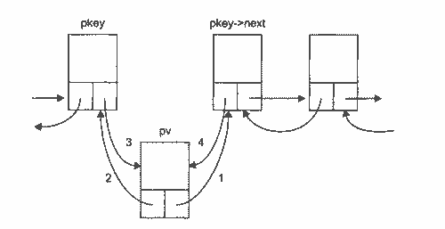

Рис. 3.2. Вставка элемента в список

Ниже приведена функция формирования упорядоченного списка (предполагается, что первый элемент существует):

```
void add_sort(Node **pbeg, Node **pend, int d) {
    Node *pv = new Node; // добавляемый элемент
    pv->d = d;
    Node *pt = *pbeg;
    while (pt) { // просмотр списка
        if (d < pt->d) { // занести перед текущим элементом (pt)
            pv->next = pt;
            if (pt == *pbeg) { // в начало списка
                pv->prev = 0;
                *pbeg = pv;
            }
            else { // в середину списка
                (pt->prev)->next = pv;
                pv->prev = pt->prev;
            }
            pt->prev = pv;
            return;
        }
        pt = pt->next;
    }
    pv->next = 0; // в конец списка
    pv->prev = *pend;
    (*pend)->next = pv;
    *pend = pv;
}
```

Страница 119

# Стеки

Стек — это частный случай однонаправленного списка, добавление элементов в который и выборка из которого выполняются с одного конца, называемого вершиной стека. Другие операции со стеком не определены. При выборке элемент исключается из стека. Говорят, что стек реализует принцип обслуживания LIFO (last in — first out, последним пришёл — первым ушёл). Стек проще всего представить себе как закрытую с одного конца узкую трубу, в которую бросают мячи. Достать первый брошенный мяч можно только после того, как вынуты все остальные. Кстати, сегмент стека назван так именно потому, что память под локальные переменные выделяется по принципу LIFO. Стеки широко применяются в системном программном обеспечении, компиляторах, в различных рекурсивных алгоритмах. Ниже приведена программа, которая формирует стек из пяти целых чисел (1, 2, 3, 4, 5) и выводит его на экран. Функция помещения в стек по традиции называется `push`, а выборки — `pop`. Указатель для работы со стеком (`top`) всегда ссылается на его вершину.

```
#include <iostream.h>
struct Node {
    int d;
    Node *p;
};
Node * first(int d);
void push(Node **top, int d);
int pop(Node **top);
//------------------
```

```
int main() {
    Node *top = first(1);
    for (int i = 2; i < 6; i++) push(&top, i);
    while (top) cout << pop(&top) << ' ';
    return 0;
}
//----------
// Начальное формирование стека
Node * first(int d) {
    Node *pv = new Node;
    pv->d = d;
    pv->p = 0;
    return pv;
}
//----------
// Занесение в стек
void push(Node **top, int d) {
    Node *pv = new Node;
    pv->d = d;
    pv->p = *top;
    *top = pv;
}
```

Страница 120

```
// Выборка из стека
int pop(Node **top) {
    int temp = (*top)->d;
    Node *pv = *top;
    *top = (*top)->p;
    delete pv;
    return temp;
}
```

Результат работы программы: `5 4 3 2 1`

# Очереди

Очередь — это частный случай однонаправленного списка, добавление элементов в который выполняется в один конец, а выборка — из другого конца. Другие операции с очередью не определены. При выборке элемент исключается из очереди.

Говорят, что очередь реализует принцип обслуживания FIFO (first in — first out, первым пришёл — первым ушёл). Очередь проще всего представить себе, постояв в ней час-другой. В программировании очереди применяются, например, при моделировании, диспетчеризации задач операционной системой, буферизованном вводе/выводе.

Ниже приведена программа, которая формирует очередь из пяти целых чисел и выводит её на экран. Функция помещения в конец очереди называется `add`, а выборки — `del`. Указатель на начало очереди называется `pbeg`, указатель на конец — `pend`.

```
#include <iostream.h>
struct Node {
    int d;
    Node *p;
};
Node * first(int d);
void add(Node **pend, int d);
int del(Node **pbeg);
//-------
int main() {
    Node *pbeg = first(1);
    Node *pend = pbeg;
    for (int i = 2; i < 6; i++) add(&pend, i);
    while (pbeg) cout << del(&pbeg) << ' ';
    return 0;
}
```

Страница 121

```
//------
// Начальное формирование очереди
Node * first(int d) {
    Node *pv = new Node;
    pv->d = d;
    pv->p = 0;
    return pv;
}
//-------
// Добавление в конец
void add(Node **pend, int d) {
    Node *pv = new Node;
    pv->d = d;
    pv->p = 0;
    (*pend)->p = pv;
    *pend = pv;
}
//------
// Выборка
int del(Node **pbeg) {
    int temp = (*pbeg)->d;
    Node *pv = *pbeg;
    *pbeg = (*pbeg)->p;
    delete pv;
    return temp;
}
```

Результат работы программы: `1 2 3 4 5`

# Бинарные деревья

Бинарное дерево — это динамическая структура данных, состоящая из узлов, каждый из которых содержит, кроме данных, не более двух ссылок на различные бинарные деревья. На каждый узел имеется ровно одна ссылка. Начальный узел называется корнем дерева.

На рисунке 3.3 приведён пример бинарного дерева (корень обычно изображается сверху, впрочем, книгу можно и перевернуть). Узел, не имеющий поддеревьев, называется листом. Исходящие узлы называются предками, входящие — потомками. Высота дерева определяется количеством уровней, на которых располагаются его узлы.

Если дерево организовано таким образом, что для каждого узла все ключи его левого поддерева меньше ключа этого узла, а все ключи его правого поддерева — больше, оно называется деревом поиска. Одинаковые ключи не допускаются. В дереве поиска можно найти элемент по ключу, двигаясь от корня и переходя на левое или правое поддерево в зависимости от значения ключа в каждом узле. Такой поиск гораздо эффективнее поиска по списку, поскольку время поиска определяется высотой дерева, а она пропорциональна двоичному логарифму количества узлов.

Нужно не забывать о том, что в оперативной памяти ячейки расположены линейно по возрастанию адресов, а дерево — это только метод логической организации данных.

Для так называемого сбалансированного дерева, в котором количество узлов справа и слева отличается не более чем на единицу, высота дерева равна двоичному логарифму количества узлов. Линейный список можно представить как вырождённое бинарное дерево, в котором каждый узел имеет не более одной ссылки. Для списка среднее время поиска равно половине длины списка.

Страница 122

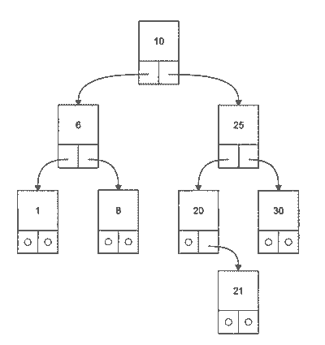

Рис. 3.3. Бинарное дерево

Дерево является рекурсивной структурой данных, поскольку каждое поддерево также является деревом. Действия с такими структурами изящнее всего описываются с помощью рекурсивных алгоритмов. Например, функцию обхода всех узлов дерева в общем виде можно описать так:

```
function way_around(дерево) {
    way_around(левое поддерево);
    посещение корня;
    way_around(правое поддерево);
}
```

Можно обходить дерево и в другом порядке, например, сначала корень, потом поддеревья, но приведённая функция позволяет получить на выходе отсортированную последовательность ключей, поскольку сначала посещаются вершины с меньшими ключами, расположенные в левом поддереве. Результат обхода дерева, изображённого на рис. 3.3: `1, 6, 8, 10, 20, 21, 25, 30.`

Страница 123

Если в функции обхода первое обращение идёт к правому поддереву, результат обхода будет другим: `30, 25, 21, 20, 10, 8, 6, 1`. Таким образом, деревья поиска можно применять для сортировки значений. При обходе дерева узлы не удаляются. Для бинарных деревьев определены операции:

- включения узла в дерево;
- поиска по дереву;
- обхода дерева;
- удаления узла.

Для каждого рекурсивного алгоритма можно создать его нерекурсивный эквивалент. В приведённой ниже программе реализована нерекурсивная функция поиска по дереву с включением и рекурсивная функция обхода дерева. Первая функция осуществляет поиск элемента с заданным ключом. Если элемент найден, она возвращает указатель на него, а если нет — включает элемент в соответствующее место дерева и возвращает указатель на него. Для включения элемента необходимо помнить пройдённый по дереву путь на один шаг назад и знать, выполняется ли включение нового элемента в левое или правое поддерево его предка. «Довольно естественно испытывать некоторое недоверие к алгоритму поиска по дереву с включением» — Н. Вирт, автор классической книги «Алгоритмы + структуры данных = программы».

```
#include <iostream.h>
struct Node {
    int d;
    Node *left;
    Node *right;
};
Node * first(int d);
Node * search_insert(Node *root, int d);
void print_tree(Node *root, int l);
//-----
int main() {
    int b[] = {10, 25, 20, 6, 21, 8, 1, 30};
    Node *root = first(b[0]);
    for (int i = 1; i < 8; i++) search_insert(root, b[i]);
    print_tree(root, 0);
    return 0;
}
```

Страница 124

```
//----------
// Формирование первого элемента дерева
Node * first(int d) {
    Node *pv = new Node;
    pv->d = d;
    pv->left = 0;
    pv->right = 0;
    return pv;
}
//----
// Поиск с включением
Node * search_insert(Node *root, int d) {
    Node *pv = root, *prev;
    bool found = false;
    while (pv && !found) {
        prev = pv;
        if (d == pv->d) found = true;
        else if (d < pv->d) pv = pv->left;
        else pv = pv->right;
    }
    if (found) return pv;
    // Создание нового узла:
    Node *pnew = new Node;
    pnew->d = d;
    pnew->left = 0;
    pnew->right = 0;
    if (d < prev->d)
        // Присоединение к левому поддереву предка:
        prev->left = pnew;
    else
        // Присоединение к правому поддереву предка:
        prev->right = pnew;
    return pnew;
}
```

```
//-------
// Обход дерева

void print_tree(Node *p, int level) {
    if (p) {
        print_tree(p->left, level + 1); // вывод левого поддерева
        for (int i = 0; i < level; i++) cout << "   ";
        cout << p->d << endl; // вывод корня поддерева
        print_tree(p->right, level + 1); // вывод правого поддерева
    }
}
```

Текущий указатель для поиска по дереву обозначен `pv`, указатель на предка `pv` обозначен `prev`. Переменная `pnew` используется для выделения памяти под включаемый в дерево узел. Рекурсии удалось избежать, сохранив всего одну переменную (`prev`) и повторив при включении операторы, определяющие, к какому поддереву присоединяется новый узел. Результат работы программы для дерева, изображенного на рис. 3.3:

Страница 125

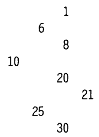

# Реализация динамических структур с помощью массивов

Операции выделения и освобождения памяти — дорогое удовольствие, поэтому если максимальный размер данных можно определить до начала использования и в процессе работы он не изменяется (например, при сортировке содержимого файла), более эффективным может оказаться однократное выделение непрерывной области памяти. Связи элементов при этом реализуются не через указатели, а через вспомогательные переменные или массивы, в которых хранятся номера элементов.

Проще всего реализовать таким образом стек. Кроме массива элементов, соответствующих типу данных стека, достаточно иметь одну переменную целого типа для хранения индекса элемента массива, являющегося вершиной стека. При помещении в стек индекс увеличивается на единицу, а при выборке — уменьшается.

Для реализации очереди требуются две переменных целого типа — для хранения индекса элементов массива, являющихся началом и концом очереди.

Страница 126

Для реализации линейного списка требуется вспомогательный массив целых чисел и ещё одна переменная, например:

[output not shown]

`i`-й элемент вспомогательного массива содержит для каждого `i`-го элемента массива данных индекс следующего за ним элемента. Отрицательное число используется как признак конца списка. Тот же массив после сортировки:

[output not shown]

Для создания бинарного дерева можно использовать два вспомогательных массива (индексы вершин его правого и левого поддерева). Отрицательное число используется как признак пустой ссылки. Например, дерево, приведённое на рис. 3.3, можно представить следующим образом:

```
10 25 20 6  21 8  1  30 - массив данных
3  2  -1 6  -1 -1 -1 -1 - левая ссылка
1  7  4  5  -1 -1 -1 -1 - правая ссылка
```

Память под такие структуры можно выделить либо на этапе компиляции, если размер можно задать константой, либо во время выполнения программы, Например:

```
struct Node {
    int i;
    Data d; // тип данных Data должен быть определён ранее
};

Node spisok1[1000]; // на этапе компиляции
Node *pspisok2 = new Node[m]; // на этапе выполнения
```

**ВНИМАНИЕ**  
При работе с подобными структурами необходимо контролировать возможный выход индексов за границу массива.

Приведённый выше способ реализации позволяет использовать преимущества динамических структур (например, сортировать структуры из громоздких элементов данных без их физического перемещения в памяти), и при этом не расходовать время на выделение и освобождение памяти для каждого элемента данных.

# Упражнения к части I

### Циклические вычислительные процессы

### Вариант 1

Вычислить и вывести на экран в виде таблицы значения функции F на интервале от Хнач до Хкон с шагом dX. $$ f = \begin{cases} ax^2+b & \text{ при x<0 и b!=0} \\ \frac{x-a}{x-c} & \text{ при x>0 и b=0} \\ \frac{x}{c} & \text{в остальных случаях} \end{cases} $$ где а, b, с - действительные числа.

Функция F должна принимать действительное значение, если выражение ($А_ц$ ИЛИ $В_ц$) И ($А_ц$ ИЛИ $С_ц$) равно нулю, и целое значение в противном случае. Через $А_ц$, $В_ц$ и $С_ц$ обознаны целые части значений а, b, с, операции И и ИЛИ - поразрядные. Значения а, b, с, $Х_{нач.}$, $Х_{кон.}$, dX ввести с клавиатуры.

### Вариант 2

Вычислить и вывести на экран в виде таблицы значения функции F на интервале от $Х_{нач.}$ до $Х_{кон.}$ с шагом dX. $$ f = \begin{cases} \frac{1}{ax}-b & \text{при x+5<0 и c=0} \\ \frac{x-a}{x} & \text{ при x+5<0 и c!=0} \\ \frac{10x}{c-4} & \text{в остальных случаях} \end{cases} $$ где а, b, с - действительные числа.

Функция F должна принимать действительное значение, если выражение ($А_ц$ ИЛИ $В_ц$) И ($А_ц$ ИЛИ $С_ц$) равно нулю, и целое значение в противном случае. Через $А_ц$, $В_ц$ и $С_ц$ обознаны целые части значений а, b, с, операции И и ИЛИ - поразрядные. Значения а, b, с, $Х_{нач.}$, $Х_{кон.}$, dX ввести с клавиатуры.

Страница 128

# Вариант 3

Вычислить и вывести на экран в виде таблицы значения функции F на интервале от $Х_{нач.}$ до $Х_{кон.}$ с шагом dX. $$ f = \begin{cases} ax^2+bx+c & \text{при a<0 и c!=0} \\ \frac{-a}{x-c} & \text{ при a>0 и c=0} \\ a(x+c) & \text{в остальных случаях} \end{cases} $$ где а, b, с - действительные числа.

Функция F должна принимать действительное значение, если выражение ($А_ц$ ИЛИ $В_ц$) И ($А_ц$ ИЛИ $С_ц$) равно нулю, и целое значение в противном случае. Через $А_ц$, $В_ц$ и $С_ц$ обознаны целые части значений а, b, с, операции И и ИЛИ - поразрядные. Значения а, b, с, $Х_{нач.}$, $Х_{кон.}$, dX ввести с клавиатуры.

# Вариант 4

Вычислить и вывести на экран в виде таблицы значения функции F на интервале от $Х_{нач.}$ до $Х_{кон.}$ с шагом dX. $$ f = \begin{cases} -ax-c \text{при c<0 и x!=0} \\ \frac{x-a}{-c} & \text{при c>0 и x=0} \\ \frac{bx}{c-a} & \text{в остальных случаях} \end{cases} $$ где а, b, с - действительные числа.

Функция F должна принимать действительное значение, если выражение ($А_ц$ ИЛИ $В_ц$) И ($А_ц$ ИЛИ $С_ц$) равно нулю, и целое значение в противном случае. Через $А_ц$, $В_ц$ и $С_ц$ обознаны целые части значений а, b, с, операции И и ИЛИ - поразрядные. Значения а, b, с, $Х_{нач.}$, $Х_{кон.}$, dX ввести с клавиатуры.

# Вариант 5

Вычислить и вывести на экран в виде таблицы значения функции F на интервале от $Х_{нач.}$ до $Х_{кон.}$ с шагом dX. $$ f = \begin{cases} a-\frac{x}{10+b} \text{при x<0 и b!=0} \\ \frac{x-a}{x-c} & \text{при x>0 и b=0} \\ 3x+\frac{2}{c} & \text{в остальных случаях} \end{cases} $$ где а, b, с - действительные числа.

Функция F должна принимать действительное значение, если выражение ($А_ц$ ИЛИ $В_ц$) И ($А_ц$ ИЛИ $С_ц$) равно нулю, и целое значение в противном случае. Через $А_ц$, $В_ц$ и $С_ц$ обознаны целые части значений а, b, с, операции И и ИЛИ - поразрядные. Значения а, b, с, $Х_{нач.}$, $Х_{кон.}$, dX ввести с клавиатуры.

Страница 129

# Вариант 6

Вычислить и вывести на экран в виде таблицы значения функции F на интервале от $Х_{нач.}$ до $Х_{кон.}$ с шагом dX. $$ f = \begin{cases} ax^2+b^2x & \text{при c<0 и b!=0} \\ \frac{x+a}{x+c} & \text{при c>0 и b=0} \\ \frac{x}{c} & \text{в остальных случаях} \end{cases} $$ где а, b, с - действительные числа.

Функция F должна принимать действительное значение, если выражение ($А_ц$ ИЛИ $В_ц$) И ($А_ц$ ИЛИ $С_ц$) равно нулю, и целое значение в противном случае. Через $А_ц$, $В_ц$ и $С_ц$ обознаны целые части значений а, b, с, операции И и ИЛИ - поразрядные. Значения а, b, с, $Х_{нач.}$, $Х_{кон.}$, dX ввести с клавиатуры.

# Вариант 7

Вычислить и вывести на экран в виде таблицы значения функции F на интервале от $Х_{нач.}$ до $Х_{кон.}$ с шагом dX. $$ f = \begin{cases} -ax^2-b & \text{при x<5 и c!=0} \\ \frac{x-a}{x} & \text{при x>5 и c=0} \\ \frac{-x}{c} & \text{в остальных случаях} \end{cases} $$ где а, b, с - действительные числа.

Функция F должна принимать действительное значение, если выражение ($А_ц$ ИЛИ $В_ц$) И ($А_ц$ ИЛИ $С_ц$) равно нулю, и целое значение в противном случае. Через $А_ц$, $В_ц$ и $С_ц$ обознаны целые части значений а, b, с, операции И и ИЛИ - поразрядные. Значения а, b, с, $Х_{нач.}$, $Х_{кон.}$, dX ввести с клавиатуры.

Страница 130

# Вариант 8

Вычислить и вывести на экран в виде таблицы значения функции F на интервале от $Х_{нач.}$ до $Х_{кон.}$ с шагом dX. $$ f = \begin{cases} -ax^2 & \text{при с<0 и a!=0} \\ \frac{a-x}{cx} & \text{при c>5 и a=0} \\ \frac{x}{c} & \text{в остальных случаях} \end{cases} $$ где а, b, с - действительные числа.

Функция F должна принимать действительное значение, если выражение ($А_ц$ ИЛИ $В_ц$) И ($А_ц$ ИЛИ $С_ц$) равно нулю, и целое значение в противном случае. Через $А_ц$, $В_ц$ и $С_ц$ обознаны целые части значений а, b, с, операции И и ИЛИ - поразрядные. Значения а, b, с, $Х_{нач.}$, $Х_{кон.}$, dX ввести с клавиатуры.

# Вариант 9

Вычислить и вывести на экран в виде таблицы значения функции F на интервале от $Х_{нач.}$ до $Х_{кон.}$ с шагом dX. $$ f = \begin{cases} ax^2+b^2 x & \text{при a<0 и x!=0} \\ x-\frac{a}{x-c} & \text{при a>5 и x=0} \\ 1+\frac{x}{c} & \text{в остальных случаях} \end{cases} $$ где а, b, с - действительные числа.

Функция F должна принимать действительное значение, если выражение ($А_ц$ ИЛИ $В_ц$) И ($А_ц$ ИЛИ $С_ц$) равно нулю, и целое значение в противном случае. Через $А_ц$, $В_ц$ и $С_ц$ обознаны целые части значений а, b, с, операции И и ИЛИ - поразрядные. Значения а, b, с, $Х_{нач.}$, $Х_{кон.}$, dX ввести с клавиатуры.

# Вариант 10

Вычислить и вывести на экран в виде таблицы значения функции F на интервале от $Х_{нач.}$ до $Х_{кон.}$ с шагом dX. $$ f = \begin{cases} ax^2-b^2+c x & \text{при x<3 и b!=0} \\ \frac{x-a}{x-c} & \text{при x>3 и b=0} \\ \frac{x}{c} & \text{в остальных случаях} \end{cases} $$ где а, b, с - действительные числа.

Функция F должна принимать действительное значение, если выражение ($А_ц$ ИЛИ $В_ц$) И ($А_ц$ ИЛИ $С_ц$) равно нулю, и целое значение в противном случае. Через $А_ц$, $В_ц$ и $С_ц$ обознаны целые части значений а, b, с, операции И и ИЛИ - поразрядные. Значения а, b, с, $Х_{нач.}$, $Х_{кон.}$, dX ввести с клавиатуры.

Страница 131

# Вариант 11

Вычислить и вывести на экран в виде таблицы значения функции F на интервале от $Х_{нач.}$ до $Х_{кон.}$ с шагом dX. $$ f = \begin{cases} ax^2+\frac{b}{c} x & \text{при x<1 и c!=0} \\ \frac{x-a}{(x-c)^2} & \text{при x>1.5 и c=0} \\ \frac{x^2}{c^2} & \text{в остальных случаях} \end{cases} $$ где а, b, с - действительные числа.

Функция F должна принимать действительное значение, если выражение ($А_ц$ ИЛИ $В_ц$) И ($А_ц$ ИЛИ $С_ц$) равно нулю, и целое значение в противном случае. Через $А_ц$, $В_ц$ и $С_ц$ обознаны целые части значений а, b, с, операции И и ИЛИ - поразрядные. Значения а, b, с, $Х_{нач.}$, $Х_{кон.}$, dX ввести с клавиатуры.

# Вариант 12

Вычислить и вывести на экран в виде таблицы значения функции F на интервале от $Х_{нач.}$ до $Х_{кон.}$ с шагом dX. $$ f = \begin{cases} ax^3 + b^2 +c & \text{при x<0.6 и b+c!=0} \\ \frac{x-a}{x-c} & \text{при x>0.6 и b+c=0} \\ \frac{x}{c} + \frac{x}{a} & \text{в остальных случаях} \end{cases} $$ где а, b, с - действительные числа.

Функция F должна принимать действительное значение, если выражение ($А_ц$ ИЛИ $В_ц$) И ($А_ц$ ИЛИ $С_ц$) равно нулю, и целое значение в противном случае. Через $А_ц$, $В_ц$ и $С_ц$ обознаны целые части значений а, b, с, операции И и ИЛИ - поразрядные. Значения а, b, с, $Х_{нач.}$, $Х_{кон.}$, dX ввести с клавиатуры.

Страница 132

# Вариант 13

Вычислить и вывести на экран в виде таблицы значения функции F на интервале от $Х_{нач.}$ до $Х_{кон.}$ с шагом dX. $$ f = \begin{cases} ax^2 + b & \text{при x - 1 < 0 и b - x != 0} \\ \frac{x-a}{x} & \text{при x - 1 > 0 и b + x = 0} \\ \frac{x}{c} & \text{в остальных случаях} \end{cases} $$ где а, b, с - действительные числа.

Функция F должна принимать действительное значение, если выражение ($А_ц$ ИЛИ $В_ц$) И ($А_ц$ ИЛИ $С_ц$) равно нулю, и целое значение в противном случае. Через $А_ц$, $В_ц$ и $С_ц$ обознаны целые части значений а, b, с, операции И и ИЛИ - поразрядные. Значения а, b, с, $Х_{нач.}$, $Х_{кон.}$, dX ввести с клавиатуры.

# Вариант 14

Вычислить и вывести на экран в виде таблицы значения функции F на интервале от $Х_{нач.}$ до $Х_{кон.}$ с шагом dX. $$ f = \begin{cases} -ax^3-b & \text{при x+c<0 и a!=0} \\ \frac{x-a}{x-c} & \text{при x+c>0 и a=0} \\ \frac{x}{c} + \frac{c}{x} & \text{в остальных случаях} \end{cases} $$ где а, b, с - действительные числа.

Функция F должна принимать действительное значение, если выражение ($А_ц$ ИЛИ $В_ц$) И ($А_ц$ ИЛИ $С_ц$) равно нулю, и целое значение в противном случае. Через $А_ц$, $В_ц$ и $С_ц$ обознаны целые части значений а, b, с, операции И и ИЛИ - поразрядные. Значения а, b, с, $Х_{нач.}$, $Х_{кон.}$, dX ввести с клавиатуры.

# Вариант 15

Вычислить и вывести на экран в виде таблицы значения функции F на интервале от $Х_{нач.}$ до $Х_{кон.}$ с шагом dX. $$ f = \begin{cases} -ax^2+b & \text{при x<0 и b!=0} \\ \frac{x}{x-c}+5.5 & \text{при x>0 и b=0} \\ \frac{x}{-c} & \text{в остальных случаях} \end{cases} $$ где а, b, с - действительные числа.

Функция F должна принимать действительное значение, если выражение ($А_ц$ ИЛИ $В_ц$) И ($А_ц$ ИЛИ $С_ц$) равно нулю, и целое значение в противном случае. Через $А_ц$, $В_ц$ и $С_ц$ обознаны целые части значений а, b, с, операции И и ИЛИ - поразрядные. Значения а, b, с, $Х_{нач.}$, $Х_{кон.}$, dX ввести с клавиатуры.

Страница 133

# Вариант 16

Вычислить и вывести на экран в виде таблицы значения функции F на интервале от $Х_{нач.}$ до $Х_{кон.}$ с шагом dX. $$ f = \begin{cases} a(x+c)^2-b & \text{при x=0 и b!=0} \\ \frac{x-a}{-c} & \text{при x=0 и b=0} \\ a+\frac{x}{c} & \text{в остальных случаях} \end{cases} $$ где а, b, с - действительные числа.

Функция F должна принимать действительное значение, если выражение ($А_ц$ ИЛИ $В_ц$) И ($А_ц$ ИЛИ $С_ц$) равно нулю, и целое значение в противном случае. Через $А_ц$, $В_ц$ и $С_ц$ обознаны целые части значений а, b, с, операции И и ИЛИ - поразрядные. Значения а, b, с, $Х_{нач.}$, $Х_{кон.}$, dX ввести с клавиатуры.

# Вариант 17

Вычислить и вывести на экран в виде таблицы значения функции F на интервале от $Х_{нач.}$ до $Х_{кон.}$ с шагом dX. $$ f = \begin{cases} ax^2-cx+b & \text{при x+10<0 и b!=0} \\ \frac{x-a}{x-c} & \text{при x+10>0 и b=0} \\ \frac{-x}{a-c} & \text{в остальных случаях} \end{cases} $$ где а, b, с - действительные числа.

Функция F должна принимать действительное значение, если выражение ($А_ц$ ИЛИ $В_ц$) И ($А_ц$ ИЛИ $С_ц$) равно нулю, и целое значение в противном случае. Через $А_ц$, $В_ц$ и $С_ц$ обознаны целые части значений а, b, с, операции И и ИЛИ - поразрядные. Значения а, b, с, $Х_{нач.}$, $Х_{кон.}$, dX ввести с клавиатуры.

Страница 134

# Вариант 18

Вычислить и вывести на экран в виде таблицы значения функции F на интервале от $Х_{нач.}$ до $Х_{кон.}$ с шагом dX. $$ f = \begin{cases} ax^3+bx^2 & \text{при x<0 и b!=0} \\ \frac{x-a}{x-c} & \text{при x>0 и b=0} \\ \frac{x+5}{c(x-10)} & \text{в остальных случаях} \end{cases} $$ где а, b, с - действительные числа.

Функция F должна принимать действительное значение, если выражение ($А_ц$ ИЛИ $В_ц$) И ($А_ц$ ИЛИ $С_ц$) равно нулю, и целое значение в противном случае. Через $А_ц$, $В_ц$ и $С_ц$ обознаны целые части значений а, b, с, операции И и ИЛИ - поразрядные. Значения а, b, с, $Х_{нач.}$, $Х_{кон.}$, dX ввести с клавиатуры.

# Вариант 19

Вычислить и вывести на экран в виде таблицы значения функции F на интервале от $Х_{нач.}$ до $Х_{кон.}$ с шагом dX. $$ f = \begin{cases} a(x+7)^2-b & \text{при x<5 и b!=0} \\ \frac{x-cd}{ax} & \text{при x>5 и b=0} \\ \frac{x}{c} & \text{в остальных случаях} \end{cases} $$ где а, b, с - действительные числа.

Функция F должна принимать действительное значение, если выражение ($А_ц$ ИЛИ $В_ц$) И ($А_ц$ ИЛИ $С_ц$) равно нулю, и целое значение в противном случае. Через $А_ц$, $В_ц$ и $С_ц$ обознаны целые части значений а, b, с, операции И и ИЛИ - поразрядные. Значения а, b, с, $Х_{нач.}$, $Х_{кон.}$, dX ввести с клавиатуры.

# Вариант 20

Вычислить и вывести на экран в виде таблицы значения функции F на интервале от $Х_{нач.}$ до $Х_{кон.}$ с шагом dX. $$ f = \begin{cases} -\frac{2x-c}{cx-a} & \text{при x<0 и b!=0} \\ \frac{x-a}{x-c} & \text{при x>0 и b=0} \\ -\frac{x}{c}+\frac{-c}{2x} & \text{в остальных случаях} \end{cases} $$ где а, b, с - действительные числа.

Функция F должна принимать действительное значение, если выражение ($А_ц$ ИЛИ $В_ц$) И ($А_ц$ ИЛИ $С_ц$) равно нулю, и целое значение в противном случае. Через $А_ц$, $В_ц$ и $С_ц$ обознаны целые части значений а, b, с, операции И и ИЛИ - поразрядные. Значения а, b, с, $Х_{нач.}$, $Х_{кон.}$, dX ввести с клавиатуры.

Страница 135

# Одномерные массивы

Примечание. Размерности массивов задаются именованными константами.

# Вариант 1

В одномерном массиве, состоящем из $n$ вещественных элементов, вычислить:

1. сумму отрицательных элементов массива;
2. произведение элементов массива, расположенных между максимальным и минимальным элементами.

Упорядочить элементы массива по возрастанию.

# Вариант 2

В одномерном массиве, состоящем из $n$ вещественных элементов, вычислить:

1. сумму положительных элементов массива;
2. произведение элементов массива, расположенных между максимальным по модулю и минимальным по модулю элементами.

Упорядочить элементы массива по убыванию.

# Вариант 3

В одномерном массиве, состоящем из $n$ целых элементов, вычислить:

1. произведение элементов массива с четными номерами;
2. сумму элементов массива, расположенных между первым и последним нулевыми элементами.

Преобразовать массив таким образом, чтобы сначала располагались все положительные элементы, а потом - все отрицательные (элементы, равные 0, считать положительными).

# Вариант 4

В одномерном массиве, состоящем из $n$ вещественных элементов, вычислить:

1. сумму элементов массива с нечетными номерами;
2. сумму элементов массива, расположенных между первым и последним отрицательными элементами.

Сжать массив, удалив из него все элементы, модуль которых не превышает 1. Освободившиеся в конце массива элементы заполнить нулями.

Страница 136

# Вариант 5

В одномерном массиве, состоящем из $n$ вещественных элементов, вычислить:

1. максимальный элемент массива;
2. сумму элементов массива, расположенных до последнего положительного элемента.

Сжать массив, удалив из него все элементы, модуль которых находится в интервале `[a,b]`. Освободившиеся в конце массива элементы заполнить нулями.

# Вариант 6

В одномерном массиве, состоящем из $n$ вещественных элементов, вычислить:

1. минимальный элемент массива;
2. сумму элементов массива, расположенных между первым и последним положительными элементами.

Преобразовать массив таким образом, чтобы сначала располагались все элементы, равные нулю, а потом - все остальные.

# Вариант 7

В одномерном массиве, состоящем из $n$ целых элементов, вычислить:

1. номер максимального элемента массива;
2. произведение элементов массива, расположенных между первым и вторым нулевыми элементами.

Преобразовать массив таким образом, чтобы в первой его половине располагались элементы, стоявшие в нечетных позициях, а во второй половине - элементы, стоявшие в четных позициях.

# Вариант 8

В одномерном массиве, состоящем из $n$ вещественных элементов, вычислить:

1. номер минимального элемента массива;
2. сумму элементов массива, расположенных между первым и вторым отрицательными элементами.

# Вариант 9

В одномерном массиве, состоящем из $n$ вещественных элементов, вычислить:

1. максимальный по модулю элемент массива;
2. сумму элементов массива, расположенных между первым и вторым положительными элементами.

Греобразовать массив таким образом, чтобы элементы, равные нулю, располагались после всех остальных.

# Вариант 10

В одномерном массиве, состоящем из $n$ целых элементов, вычислить:

1. минимальный по модулю элемент массива;
2. сумму модулей элементов массива, расположенных после первого элемента, равного нулю.

Преобразовать массив таким образом, чтобы в первой его половине располагались элементы, стоявшие в четных позициях, а во второй половине - элементы, стоявшие в нечетных позициях.

Страница 137

# Вариант 11

В одномерном массиве, состоящем из $n$ вещественных элементов, вычислить:

1. номер минимального по модулю элемента массива;
2. сумму модулей элементов массива, расположенных после первого отрицательного элемента.

Сжать массив, удалив из него все элементы, величина которых находится в интервале `[a,b]`. Освободившиеся в конце массива элементы заполнить нулями.

# Вариант 12

В одномерном массиве, состоящем из $n$ вещественных элементов, вычислить:

1. номер максимального по модулю элемента массива;
2. сумму элементов массива, расположенных после первого положительного элемента.

Преобразовать массив таким образом, чтобы сначала располагались все элемены, целая часть которых лежит в интервале `[a,b]`, а потом — все остальные.

# Вариант 13

В одномерном массиве, состоящем из $n$ вещественных элементов, вычислить:

1. количество элементов массива, лежащих в диапазоне от А до В;
2. сумму элементов массива, расположенных после максимального элемента. .

Упорядочить элементы массива по убыванию модулей элементов.

# Вариант 14

В одномерном массиве, состоящем из $n$ вещественных элементов, вычислить:

1. количество элементов массива, равных О;
2. сумму элементов массива, расположенных после минимального элемента.

Упорядочить элементы массива по возрастанию модулей элементов.

# Вариант 15

В одномерном массиве, состоящем из $n$ вещественных элементов, вычислить:

1. количество элементов массива, больших С;
2. произведение элементов массива, расположенных после максимального по модулю элемента.

# Вариант 16

В одномерном массиве, состоящем из $n$ вещественных элементов, вычислить:

1. количество отрицательных элементов массива;
2. сумму модулей элементов массива, расположенных после минимального по модулю элемента.

Заменить все отрицательные элементы массива их квадратами и упорядочить элементы массива по возрастанию.

Страница 138

# Вариант 17

В одномерном массиве, состоящем из $n$ целых элементов, вычислить:

1. количество положительных элементов массива;
2. сумму элементов массива, расположенных после последнего элемента, равного нулю.

Преобразовать массив таким образом, чтобы сначала располагались все элементы, целая часть которых не превышает 1, а потом - все остальные.

# Вариант 18

В одномерном массиве, состоящем из $n$ вещественных элементов, вычислить:

1. количество элементов массива, меньших C;
2. сумму целых частей элементов массива, расположенных после последнего отрицательного элемента.

Преобразовать массив таким образом, чтобы сначала располагались все элементы, отличающиеся от максимального не более чем на 20%, а потом - все остальные.

# Вариант 19

В одномерном массиве, состоящем из $n$ вещественных элементов, вычислить:

1. произведение отрицательных элементов массива;
2. сумму положительных элементов массива, расположенных до максимального элемента.

Изменить порядок следования элементов в массиве на обратный.

# Вариант 20

В одномерном массиве, состоящем из $n$ вещественных элементов, вычислить:

1. произведение положительных элементов массива;
2. сумму элементов массива, расположенных до минимального элемента.

Упорядочить по возрастанию отдельно элементы, стоящие на четных местах, и элементы, стоящие на нечетных местах.

Страница 139

# Двумерные массивы

# Вариант 1

Дана целочисленная прямоугольная матрица. Определить:

1. количество строк, не содержащих ни одного нулевого элемента;
2. максимальное из чисел, встречающихся в заданной матрице более одного раза.

# Вариант 2

Дана целочисленная прямоугольная матрица. Определить количество столбцов, не содержащих ни одного нулевого элемента. Характеристикой строки целочисленной матрицы назовем сумму ее положительных четных элементов. Переставляя строки заданной матрицы, расположить их в соответствии с ростом характеристик.

# Вариант 3

Дана целочисленная прямоугольная матрица. Определить:

1. количество столбцов, содержащих хотя бы один нулевой элемент;
2. номер строки, в которой находится самая длинная серия одинаковых элементов.

# Вариант 4

Дана целочисленная квадратная матрица. Определить:

1. произведение элементов в тех строках, которые не содержат отрицательных элементов;
2. максимум среди сумм элементов диагоналей, параллельных главной диагонали матрицы.

# Вариант 5

Дана целочисленная квадратная матрица. Определить:

1. сумму элементов в тех столбцах, которые не содержат отрицательных элементов;
2. минимум среди сумм модулей элементов диагоналей, параллельных побочной диагонали матрицы.

# Вариант 6

Дана целочисленная прямоугольная матрица. Определить:

1. сумму элементов в тех строках, которые содержат хотя бы один отрицательный элемент;
2. номера строк и столбцов всех седловых точек матрицы.

# ПРИМЕЧАНИЕ

Матрица А имеет седловую точку $А_{i,j}$, если $А_{i,j}$ является минимальным элементом в і-й строке и максимальным в j-м столбце.

# Вариант 7

Для заданной матрицы размером 8 на 8 найти такие $k$, что $k$-я строка матрицы совпадает с $k$-м столбцом. Найти сумму элементов в тех строках, которые содержат хотя бы один отрицательный элемент.

# Вариант 8

Характеристикой столбца целочисленной матрицы назовем сумму модулей его отрицательных нечетных элементов. Переставляя столбцы заданной матрицы, расположить их в соответствии с ростом характеристик. Найти сумму элементов в тех столбцах, которые содержат хотя бы один отрицательный элемент.

Страница 140

# Вариант 9

Соседями элемента $A_{ij}$ в матрице назовем элементы $A_{kl}$ c $i-1<=k<=i+1$, $j-1<=l<=j+1$, $(k,l)!=(i,j)$. Операция сглаживания матрицы дает новую матрицу того же размера, каждый элемент которой получается как среднее арифметическое имеющихся соседей соответствующего элемента исходной матрицы. Построить результат сглаживания заданной вещественной матрицы размером 10 на 10.

В сглаженной матрице найти сумму модулей элементов, расположенных ниже главной диагонали.

# Вариант 10

Элемент матрицы называется локальным минимумом, если он строго меньше всех имеющихся у него соседей. Подсчитать количество локальных минимумов заданной матрицы размером 10 на 10. Найти сумму модулей элементов, расположенных выше главной диагонали.

# Вариант 11

Коэффициенты системы линейных уравнении заданы в виде прямоугольно матрицы. С помощью допустимых преобразований привести систему к треугольному виду. Найти количество строк, среднее арифметическое элементов которых меньше заданной величины.

# Вариант 12

Уплотнить заданную матрицу, удаляя из нее строки и столбцы, заполненные нулями. Найти номер первой из строк, содержащих хотя бы один положительный элемент.

# Вариант 13

Осуществить циклический сдвиг элементов прямоугольной матрицы на п элементов вправо или вниз (в зависимости от введенного режима). $n$ может быть больше количества элементов в строке или столбце.

# Вариант 14

Осуществить циклический сдвиг элементов квадратной матрицы размерности $M×N$ вправо на k элементов таким образом: элементы 1-й строки сдвигаются в последний столбец сверху вниз, из него — в последнюю строку справа налево, из нее — в первый столбец снизу вверх, из него — в первую строку; для остальных элементов - аналогично.

# Вариант 15

Дана целочисленная прямоугольная матрица. Определить номер первого из столбцов, содержащих хотя бы один нулевой элемент. Характеристикой строки целочисленной матрицы назовем сумму ее отрицательных четных элементов. Переставляя строки заданной матрицы, расположить их в соответствии с убыванием характеристик.

# Вариант 16

Упорядочить строки целочисленной прямоугольной матрицы по возрастанию количества одинаковых элементов в каждой строке. Найти номер первого из столбцов, не содержащих ни одного отрицательного элемента.

Страница 141

# Вариант 17

Путем перестановки элементов квадратной вещественной матрицы добиться того, чтобы ее максимальный элемент находился в левом верхнем углу, следующий по величине — в позиции $(2,2)$, следующий по величине - в позиции $(3,3)$ и т. д., заполнив таким образом всю главную диагональ. Найти номер первой из строк, не содержащих ни одного положительного элемента.

# Вариант 18

Дана целочисленная прямоугольная матрица. Определить:

1. количество строк, содержащих хотя бы один нулевой элемент;
2. номер столбца, в которой находится самая длинная серия одинаковых элементов.

# Вариант 19

Дана целочисленная квадратная матрица. Определить:

1. сумму элементов в тех строках, которые не содержат отрицательных элементов;
2. минимум среди сумм элементов диагоналей, параллельных главной диагонали матрицы.

# Вариант 20

Дана целочисленная прямоугольная матрица. Определить:

1. количество отрицательных элементов в тех строках, которые содержат хотя бы один нулевой элемент;
2. номера строк и столбцов всех седловых точек матрицы.

### ПРИМЕЧАНИЕ

Матрица А имеет седловую точку $А_{ij}$, если $А_{ij}$, является минимальным элементом в і-й строке и максимальным в j-м столбце.

Страница 142

# Одномерные и двумерные массивы

# Вариант 1

Два выпуклых многоугольника заданы на плоскости перечислением координат вершин в порядке обхода границы. Определить площади многоугольников и проверить, лежит ли один из них строго внутри другого.

# Вариант 2

Из заданного на плоскости множества точек выбрать три различные точки так, чтобы разность между площадью круга, ограниченного окружностью, проходящей через эти три точки, и площадью треугольника с вершинами в этих точках была минимальной.

# Вариант 3

Даны два множества точек на плоскости. Выбрать три различные точки первого множества так, чтобы круг, ограниченный окружностью, проходящей через эти три точки, содержал все точки второго множества и имел минимальную площадь.

# Вариант 4

Даны два множества точек на плоскости. Выбрать четыре различные точки первого множества так, чтобы квадрат с вершинами в этих точках накрывал все точки второго множества и имел минимальную площадь.

# Вариант 5

Даны два множества точек на плоскости. Выбрать три различные точки первого множества так, чтобы треугольник с вершинами в этих точках накрывал все точки второго множества и имел минимальную площадь.

# Вариант 6

Даны два множества точек на плоскости. Найти радиус и центр окружности, проходящей через n (n>=3) точек первого множества и содержащей строго внутри себя равное число точек первого и второго множеств.

# Вариант 7

Даны два множества точек на плоскости. Из первого множества выбрать три различные точки так, чтобы треугольник с вершинами в этих точках содержал (строго внутри себя) равное количество точек первого и второго множеств.

# Вариант 8

На плоскости заданы множество точек М и круг. Выбрать из М две различные точки так, чтобы наименьшим образом различались количества точек в круге, лежащие по разные стороны от прямой, проходящей через эти точки.

# Вариант 9

Дано $3n$ точек на плоскости, причем никакие три из них не лежат на одной прямой. Построить множество $n$ треугольников с вершинами в этих точках так, чтобы никакие два треугольника не пересекались и не содержали друг друга.

# Вариант 10

Выбрать три различные точки из заданного множества точек на плоскости так, чтобы была минимальной разность между количествами точек, лежащих внутри и вне треугольника с вершинами в выбранных точках.

# Вариант 11

Определить радиус и центр окружности, проходящей по крайней мере через три различные точки заданного множества точек на плоскости и содержащей внутри наибольшее количество точек этого множества.

# Вариант 12

На плоскости заданы множество точек А и точка d вне его. Подсчитать количест- во различных неупорядоченных троек точек а, b, с из А таких, что четырехуголь- ник abcd является параллелограммом.

Страница 143

# Вариант 13

На плоскости заданы множество точек А и множество окружностей В. Найти две такие различные точки из А, что проходящая через пих прямая пересекается с максимальным количеством окружностей из В.

# Вариант 14

Задано множество точек на плоскости. Найти все четверки точек, являющихся вершинами квадратов. Найти квадрат, внутри которого лежит наибольшее количество точек множества.

# Вариант 15

Определить радиус и центр окружности минимального радиуса, проходящей хотя бы через три различные точки заданного множества точек на плоскости.

# Вариант 16

Найти три треугольника с вершинами в заданном множестве точек на плоскости так, чтобы второй треугольник лежал строго внутри первого, а третий внутри второго.

# Вариант 17

Дано множество точек на плоскости. Построить все возможные треугольники с вершинами в этом множестве точек и найти среди них такой, стороны которого пересекаются с максимальным количеством треугольников.

# Вариант 18

На плоскости заданы множество точек и окружность радиусом R с центром в начале координат. Построить множество всех треугольников с вершинами в заданных точках, все три стороны которых пересекаются с окружностью, и найти среди них треугольник с минимальной площадью.

# Вариант 19

# Вариант 20

Множество попарно различных плоскостей в трехмерном пространстве задано перечислением троек точек, через которые проходит каждая из плоскостей. Выбрать максимальное подмножество попарно непараллельных плоскостей.

Страница 144

# Структуры

# Вариант 1

1. Описать структуру с именем STUDENT, содержащую следующие поля:
- фамилия и инициалы;
- номер групы;
- успеваемость (массив из пяти элементов).
2. Написать программу, выполняющую следующие действия:
- ввод с клавиатуры данных в массив, состоящий из десяти структур типа STUDENT; записи должны быть упорядочены не возрастанию помера группы;
- вывод на дисплей фамилий и померов груш для всех студентов, включенных в массив, если средний балл студента больше 4,0;
- если таких студентов нет, вывести соответствующее сообщение.

# Вариант 2

1. Описать структуру с именем STUDENT, содержащую следующие поля:
- фамилия и ипициалы;
- номер группы;
- успеваемость (массив из пяти элементов).
2. Написать программу, выполняющую следующие действия:
- ввод с клавиатуры данных в массив, состоящий из десяти структур типа STUDENT; записи должны быть упорядочены по возрастанию среднего балла;
- вывод на дисплей фамилий и номеров групи для всех студентов, имеющих оценки 4 и 5;
- если таких студентов нет, вывести соответствующее сообщение.

# Вариант 3

1. Описать структуру с именем STUDENT, содержащую следующие поля:
- фамилия и инициалы;
- номер группы;
- успеваемость (массив из пяти элементов).
2. Написать программу, выполняющую следующие действия:
- ввод с клавиатуры данных в массив, состоящий из десяти структур типа STUDENT; записи должны быть упорядочены по алфавиту;
- вывод на дисплей фамилий и померов груш для всех студентов, имеющих хотя бы одну оценку 2;
- если таких студентов нет, вывести соответствующее сообщение.

# Вариант 4

1. Описать структуру с именем AEROFLOT, содержащую следующие поля:
- название пупкта назпачения рейса;
- номер рейса;
- тип самолета.
2. Написать программу, выполняющую следующие действия:
- ввод с клавиатуры данных в массив, состоящий из семи элементов типа AEROFLOT; записи должны быть упорядочены по возрастанию помера рейса;
- вывод на экран номеров рейсов и типов самолетов, вылетающих в пункт назначения, название которого совпало с названием, введенным с клавиатуры;
- если таких рейсов нет, выдать на дисплей соответствующее сообщение.

Страница 145

# Вариант 5

1. Описать структуру с именем AEROFLOT, содержащую следующие поля:
- название пункта назпачения рейса;
- номер рейса;
- тип самолета.
2. Написать программу, выполняющую следующие действия:
- ввод с клавиатуры данных в массив, состоящий из семи элементов тип EROFLOT; записи должны быть размещены в алфавитном порядке и названиям пунктов назначения;
- вывод на экран пупктов назначения и номеров рейсов, обслуживаемых самолетом, тип которого введен с клавиатуры;
- если таких рейсов нет, выдать на дисплей соответствующее сообщение.

# Вариант 6

1. Описать структуру с именем WORKER, содержащую следующие поля:
- фамилия и инициалы работника;
- название занимаемой должности;
- год поступления на работу.
2. Написать программу, выполияющую следующие действия:
- ввод с клавиатуры данных в массив, состоящий из десяти структур типа WORKER; записи должны быть размещены по алфавиту.
- вывод на дисплей фамилий работников, чей стаж работы в организации превышает значение, введенное с клавиатуры;
- если таких работников нет, вывести на дисплей соответствующее сообщение.

# Вариант 7

1. Описать структуру с именем TRAIN, содержащую следующие поля:
- название пункта назначения;
- номер поезда;
- время отправления.
2. Написать программу, выполняющую следующие действия:
- ввод с клавиатуры данных в массив, состоящий из восьми элементов типа TRAIN; записи должны быть размещены в алфавитном порядке по названиям пунктов назначения;
- вывод на экран информации о поездах, отправляющихся после введеного с клавиатуры времени;
- если таких поездов нет, выдать на дисплей соответствующее сообщение.

Страница 146

# Вариант 8

1. Описать структуру с именем TRAIN, содержащую следующие поля:
- название пункта назначения;
- номер поезда;
- время отправления.
2. Написать программу, выполняющую следующие действия:
- ввод с клавиатуры данных в массив, состоящий из шести элементов типа TRAIN; записи должны быть упорядочены по времени отправления поезда;
- вывод на экран информации о поездах, направляющихся в цункт, название которого введено с клавиатуры
- если таких поездов нет, выдать на дисплей соответствующее сообщепие.

# Вариант 9

1. Описать структуру с именем TRAIN, содержащую следующие поля:
- название пункта назначения;
- номер поезда;
- время отправления.
2. Написать программу, выполняющую следующие действия:
- ввод с клавиатуры данных в массив, состоящий из восьми элементов типа TRAIN; записи должны быть упорядочены по номерам поездов;
- вывод на экран информации о поезде, номер которого введен с клавиатуры;
- если таких поездов нет, выдать на дисплей соответствующее сообщение.

# Вариант 10

1. Описать структуру с именем MARSH, содержащую следующие поля:
- название начального пункта маршрута;
- название конечного пункта маршрута;
- номер маршрута.
2. Написать программу, выполняющую следующие действия:
- ввод с клавиатуры данных в массив, состоящий из восьми элементов типа MARSH; записи должны быть упорядочены по номерам маршрутов;
- вывод на экран информации о маршруте, номер которого введен с клавиатуры;
- если таких маршрутов нет, выдать на дисплей соответствующее сообщение.

Страница 147

# Вариант 11

1. Описать структуру с именем MARSH, содержащую следующие поля:
- название начального пункта маршрута;
- название конечного пункта маршрута;
- помер маршрута.
2. Написать программу, выполняющую следующие действия:
- ввод с клавиатуры данных в массив, состоящий из восьми элементов типа MARSH; записи должны быть упорядочены по номерам маршрутов;
- вывод на экран информации о маршрутах, которые начинаются или кончаются в пупкте, название которого введено с клавиатуры;
- если таких маршрутов нет, выдать на дисплей соответствующее сообщение.

# Вариант 12

1. Описать структуру с именем NOTE, содержащую следующие поля:
- фамилия, имя;
- номер телефона;
- день рождения (массив из трех чисел).
2. Написать программу, выполняющую следующие действия:
- ввод с клавиатуры данных в массив, состоящий из восьми элементов типа NOTE; записи должны быть упорядочены по датам дней рождения;
- вывод на экран информации о человеке, помер телефона которого введен с клавиатуры;
- если такого нет, выдать на дисплей соответствующее сообщение.

# Вариант 13

1. Описать структуру с именем NOTE, содержащую следующие поля:
- фамилия, имя;
- помер телефона;
- день рождения (массив из трех чисел).
2. Написать программу, выполияющую следующие действия:
- ввод с клавиатуры дашных в массив, состоящий из восьми элементов типа NOTE; записи должны быть размещены по алфавиту;
- вывод на экран информации о людях, чьи дни рождения приходятся на месяц, значение которого введено с клавиатуры;
- если таких нет, выдать на дисплей соответствующее сообщение.

Страница 148

# Вариант 14

1. Описать структуру с именем NOTE, содержащую следующие поля:
- фамилия, имя;
- номер телефона;
- день рождения (массив из трех чисел).
2. Написать программу, выполняющую следующие действия:
- ввод с клавиатуры данных в массив, состоящий из восьми элементов типа NOTE; записи должны быть упорядочены по трем первым цифрам помера телефона;
- вывод на экран информации о человеке, чья фамилия введена с клавиатуры;
- если такого нет, выдать на дисплей соответствующее сообщение.

# Вариант 15

1. Описать структуру с именем ZNAK, содержащую следующие поля:
- фамилия, имя;
- знак Зодиака;
- день рождения (массив из трех чисел).
2. Написать программу, выполияющую следующие действия:
- ввод с клавиатуры данных в массив, состоящий из восьми элементов типа ZNAK; записи должны быть упорядочены по датам дней рождения;
- вывод на экран информации о человеке, чья фамилия введена с клавиатуры;
- если такого нет, выдать на дисплей соответствующее сообщение.

# Вариант 16

1. Описать структуру с именем ZNAK, содержащую следующие поля:
- фамилия, имя;
- знак Зодиака;
- день рождения (массив из трех чисел).
2. Написать программу, выполняющую следующие действия:
- ввод с клавиатуры данных в массив, состоящий из восьми элементов типа ZNAK; записи должны быть упорядочены по датам дней рождения;
- вывод на экран информации о людях, родившихся под знаком, наименование которого введено с клавиатуры;
- если таких нет, выдать на дисплей соответствующее сообщение.

# Вариант 17

1. Описать структуру с именем ZNAK, содержащую следующие поля:
- фамилия, имя;
- знак Зодиака;
- день рождения (массив из трех чисел).
2. Написать программу, выполняющую следующие действия:
- ввод с клавиатуры даных в массив, состоящий из восьми элементов типа ZNAK; записи должны быть упорядочены по знакам Зодиака;
- вывод на экран информации о людях, родившихся в месяц, значение которого введено с клавиатуры;
- если таких нет, выдать на дисплей соответствующее сообщение.

Страница 149

# Вариант 18

1. Описать структуру с именем PRICE, содержащую следующие поля:
- название товара;
- название магазина, в котором продается товар;
- стоимость товара в руб.
2. Написать программу, выполняющую следующие действия:
- ввод с клавиатуры данных в массив, состоящий из восьми элементов типа PRICE; записи должны быть размещены в алфавитном порядке по названиям товаров;
- вывод на экран информации о товаре, название которого введено с клавиатуры;
- если таких товаров нет, выдать на дисплей соответствующее сообщение.

# Вариант 19

1. Описать структуру с именем PRICE, содержащую следующие поля:
- название товара;
- название магазина, в котором продается товар;
- стоимость товара в руб.
2. Написать программу, выполняющую следующие действия:
- ввод с клавиатуры данных в массив, состоящий из восьми элементов типа PRICE; записи должны быть размещены в алфавитном порядке по названиям магазинов;
- вывод на экран информации о товарах, продающихся в магазине, название которого введено с клавиатуры;
- если такого магазина нет, выдать на дисплей соответствующее сообщение.

# Вариант 20

1. Описать структуру с именем ORDER, содержащую следующие поля:
- расчетный счет плательщика;
- расчетный счет получателя;
- перечисляемая сумма в руб.
2. Написать программу, выполняющую следующие действия:
- ввод с клавиатуры дашых в массив, состоящий из восьми элементов типа ORDER; записи должны быть размещены в алфавитном порядке по расчетным счетам плательщиков;
- вывод на экран информации о сумме, снятой с расчетного счета плательщика, введенного с клавиатуры;
- если такого расчетного счета нет, выдать на дисплей соответствующее сообщение.

Страница 150

# Указатели

Выполиить задания из разделов «Двумерные массивы» и «Структуры», используя динамическое выделение памяти.

# Простейшие функции

Выполнить упражнения из раздела «Двумерные массивы», оформив каждый пункт задания в виде функции. Все необходимые дашые для функций должны передаваться им в качестве параметров. Использование глобальных переменных в функциях не допускается.

# Функции и файлы

# Вариант 1

Для хранения данных о планшетных скаперах описать структуру вида:

```
struct scan_info{
    char model [25]; // наименование модели
    int price; // цена
    double x_size; // горизонтальный размер области сканирования
    double y_size; // вертикальный размер области сканирования
    int optr; // оптическое разрешение
    int grey; // число градаций серого
};
```

- Написать функцию, которая записывает в бинарный файл данные о скапере из приведенной структуры. Структура файла: в первых двух байтах размещается значение типа `int`, определяющее количество сделанных в файл записей; далее без пропусков размещаются записи о сканерах.
- Написать функцию, которая извлекает из этого файла данные о сканере в структуру типа `scan_info`. Обязательный параметр - номер требуемой записи. Функция должна возвращать нулевое значение, если чтение прошло успешно, и `-1` в противном случае.
- Привести пример программы, создающей файл с данными о сканерах (данные вводятся с клавиатуры) - 6-8 записей и выводящей на дисплей данные о запрошенной записи.

Все необходимые данные для функций должны передаваться им в качестве параметров. Использование глобальных переменных в функциях не допускается.

Страница 151

# Вариант 2

Для хранения данных о планшетных сканерах описать структуру вида, описанного в варианте 1.

- Написать функцию, которая записывает в бинарный файл данные о сканере из приведешой структуры. Структура файла: в первых двух байтах размещается значение типа int, определяющее количество сделаных в файл записей; далее без пропусков размещаются записи о сканерах.
- Написать функцию, которая сортирует записи в описашном выше бинарном файле по одной из следующих характеристик: цена либо число градаций серого. Обязательный параметр - признак, задающий критерий сортировки.
- Привести пример программы, создающей файл с данными о скаперах (данные вводятся с клавиатуры) из не менее восьми записей и осуществляющий его сортировку.

Все необходимые данные для функций должны передаваться им в качестве параметров. Использование глобальных переменных в функциях не допускается.

# Вариант З

Для хранепия дашых о планшетных сканерах описать структуру вида, описанного в варианте 1.

- Написать функцию, которая записывает в оипарный файл данные о сканере из приведенной структуры. Структура файла: в первых четырех байтах размещается зпачение типа long, определяющее количество сделанных в файл записей; далее без пропусков размещаются записи о сканерах.
- Написать функцию, которая сортирует записи в описашом выше бинарном файле по наименованию модели скапера.
- Привести пример программы, создающей файл с даными о сканерах (данные вводятся с клавиатуры) из не менее восьми записей и осуществляющий его сортировку.

Все необходимые даные для функций должны передаваться им в качестве параметров. Использование глобальных переменных в функциях не допускается.

# Вариант 4

Для храпения данных о планшетных сканерах описать структуру вида, описанного в варианте 1.

- Написать функцию, которая динамически выделяет память под массив структур (не меньше шести элементов), заполняет его данными в режиме диалога и записывает массив в бинарный файл. Структура файла: в первых двух байтах размещается значение типа int, определяющее количество сделанных в файл записей; далее без пропусков размещаются записи о скаперах.
- Написать функцию, которая извлекает данные о сканере из описанного выше бинарного файла в структуру типа `scan_info`. Обязательный параметр - помер требуемой записи. Функция должна возвращать пулевое значение, если чтение прошло успешно, и `-1` в противном случае.
- Привести пример программы, создающей файл с данными о сканерах (данные вводятся с клавиатуры) из не менее восьми записей и осуществляющий вывод на дисплей данных о требуемой записи.

Все необходимые даные для функций должны передаваться им в качестве параметров. Использование глобальных перемешых в функциях не допускается.

Страница 153

# Вариант 5

Для хранения данных о планшетных скаперах описать структуру вида, описанного в варианте 1.

- Написать функцию, которая записывает даные о скапере из приведенной структуры в требуемую позицию в бинарном файле. Структура файла: в первых двух байтах размещается значение типа int, определяющее количество сделанных в файл записей; далее без пропусков размещаются записи о сканерах. Запись может осуществляться в любую позицию, причем если между вводимой записью и последней (или началом файла) имеются пропуски, они заполняются пулями.
- Написать функцию, которая «уплотняет» описанный выше бинарный файл путем удаления из него записей, содержащих все нули.
- Привести пример программы, Создающий файл с данными о сканерах, данные вводится с клавиатуры, из не менее шести записей и осуществляющей его уплотнение.

Все необходимые данные для функций должны передаваться им в качестве параметров. Использование глобальных перемешых в функциях не допускается.

# Вариант 6

Для хранения данных о планшетных сканерах описать структуру вида, описанного в варианте 1.

- Написать функцию, которая динамически выделяет память под массив структур (не меньше шести элементов), заполияет его дашыми в режиме диалога и записывает массив в бинарный файл. Структура файла: в первых двух байтах размещается значение типа int, определяющее количество сделанных в файл записей; далее без пропусков размещаются записи о сканерах.
- Написать функцию, которая запрашивает данные о сканере в режиме диалога и замещает записи в бинарном файле по заданному номеру. Обязательный параметр - номер замещаемой записи. Функция должна возвращать нулевое значение, если запись прошла успешно, и - 1 в противном случае.
- Привести пример программы, создающей файл с данными о сканерах (данны водятся с клавиатуры) из не менее восьми записей и осуществляющий вставку новых данных о сканере.

Все необходимые данные для функций должны передаваться им в качестве параметров. Использование глобальных переменных в функциях не допускается.

# Вариант 7

Для хранения данных о планшетных сканерах описать структуру вида, описанного в варианте 1.

- Написать функцию, которая записывает в бинарный файл данные о сканере из приведенной структуры. Структура файла: в первых двух байтах размещается значение тина `int`, определяющее количество сделанных в файл записей; далее без пропусков размещаются записи о скаперах.
- Написать функцию, которая вводит данные о скапере с клавиатуры в структуру типа `scan_info`, и если данные об этом сканере отсутствуют в файле, помещает содержимое структуры в конец файла; в противном случае выдает соответствующее сообщение.
- Привести пример программы, создающей файл с данными о скаперах (данные вводятся из текстового файла) — 6-8 записей и дополняющей файл записями о 2-3 сканерах, вводимых с клавиатуры.

Все необходимые данные для функции должны передаваться им в качестве параметров. Использование глобальных переменных функциях не рекомендуется, не допускается.

Страница 153

# Вариант 8

Для хранения данных о планшетных сканерах описать структуру вида, описанного в варианте 1.

- Написать функцию, которая записывает в бинарный файл данные о сканере и приведенной структуры. Структура файла: в первых двух байтах размещается значение типа int, определяющее количество сделанных в файл записей; далее без пропусков размещаются записи о скаперах.
- Написать функцию, которая вводит данные о сканере с клавиатуры в структуру типа `scan_info` и помещает ее содержимое на место первой записи в файле. Файл должен существовать. При этом, запись ранее занимавшая первую позицию, посещается на вторую, вторая запись на третью, и т. д.
- Привести пример программы, создающей файл с данными о сканерах (данные вводятся из текстового файла) — 6-8 записей и дополняющей этот файл 1-2 новыми записями, вводимыми с клавиатуры.

Все необходимые данные для функций должны передаваться им в качестве параметров. Использование глобальных переменных в функциях не допускается.

# Вариант 9

Для хранения данных о планшетных сканерах описать структуру вида, описанного в варианте 1.

- написать функцию, которая запрашивает количество сканеров, информация которую будет вводиться, динамически выделяется память под массив структур соответствующего размера и заполняет его данными в режиме диалога, с клавиатуры. При этом имя сканера должно содержать пробелы.
- Написать функцию, которая записывает данный массив в создаваемый бинарный файл. Если цена скапера меньше 200, то данные об этом сканере в файл не записываются. Информация об остальных скаперах помещается в бинарный файл, причем сначала пишутся данные о всех сканерах, имя которых начинается с заглавной буквы, а затем — с прописной.
- Структура файла: в первых четырех байтах размещается значение типа long, определяющее количество сделанных в файл записей; далее без пропусков размещаются записи о сканерах.
- Привести пример программы, создающие файл с данными о сканерах и осуществляющий Вывод на дисплее данных о любому записях, либо всех, либо по номеру.

Все необходимые данные для функций должны передаваться им в качестве параметров. Использование глобальных переменных в фуикциях не допускается.

Страница 154

# Вариант 10

Для хранения данных о поутбуках описать структуру вида (ири пеобходимости дополнив ее):

```
struct NOTEBOOK{
    char model [21]; // наименование
    struct size{ // габаритные размеры
        float x;
        float y;
        float z;
    };
    float w; // вес
    int price; // цена
}
```

- Написать функцию, которая читает данные о ноутбуках из файла note.txt (см. с. 158) в структуру приведенного вида. - Написать функцию, которая записывает содержимое структуры в конец бинарного файла. Структура бинарного файле; первые два байта (целое) - число записей в файле; далее записи в формате структуры `NOTEBOOK`.
- Написать программу, в которой на основе разработанных функций осуществляется чтение данных только для тех ноутбуков, частота процессора которых больше 120 МГц, и запись в бинарный файл по убыванию цены.

# Вариант 11

Для хранения данных о ноутбуках описать структуру вида, описанного в варианте 10.

- Написать функцию, которая читает данные о ноутбуках из фаила note.txt (см. с. 158) в структуру приведенного вида. Написать функцию, которая записывае содержимое структуры в конец бинарного файла. Структура бинарного файла: первые два байта (целое) - число записей в файле; далее записи в формате структуры NOTEBOOK.
- Написать программу, в которой на основе разработанных функций осуществляется чтение данных только для тех ноутбуков, объем HDD которых меньше 1 Гбайт, и запись считаных дашых в бинарный файл в алфавитном порядке по наименованию.

# Вариант 12

Для хранения данных о поутбуках описать структуру вида, описанного в варианте 10.

- Написать функцию, которая читает данные о ноутбуках из файла note.txt (см. с. 158) в структуру приведенного вида. Написать функцию, которая записывает содержимое структуры в конец бинарного файла. Структура бинарного файла: первые два байта (целое) - число записей в файле; далее записи в формате структуры `NOTEBOOK`.
- Написать программу, в которой на основе разработанных функций осуществлятся запись в двоичный файл даных только о тех поутбуках, целое количеств которых в одном кубическом метре не превышает 285 штук.

Страница 155

# Вариант 13

Для хранения данных о ноутбуках описать структуру вида, описанного в варианте 10.

- Написать функцию, которая читает данные о ноутбуках из файла note.txt (см. с. 158) в структуру приведенного вида. Написать функцию, которая записывает содержимое структуры в конец бинарного файла. Структура бинарного файла: первые два байта (целое) - число записей в файле; далее записи в формате структуры NOTEBOOK.
- Написать программу, в которой на основе разработанных функций осуществляется запись в двоичный файл данных только о тех ноутбуках, максимальный объем ОЗУ которых не менее 40 Мбайт, отсортированных по объему.

# Вариант 14

Для хранения данных о ноутбуках описать структуру вида, описанного в варианте 10.

- Написать функцию, которая читает данные о ноутбуках из файла note.txt (см. с. 158) в структуру приведенного вида. Написать функцию, которая записывает содержимое структуры в конец бинарного файла. Структура бинарного файла: первые два байта - целое число записей в файле; далее записи в формате структуры NOTEBOOK.
- Написать программу, в которой на основе разработанных функций осуществляется запись в двоичный файл данных только о тех ноутбуках, диагональ дисплея которых больше одиннадцати дюймов.

# Вариант 15

Для хранения данных о ноутбуках описать структуру вида (при необходимости дополнив ее):

```
struct NOTEBOOK
{
    struct disp_res { // разрешающая способность дисплея
        int x; // по горизонтали
        int y; // по вертикали
    };
    int f; // частота регенерации
    float d; // размер диагонали дисплея
    int price; // цена
    char model [21]; // наименование
}
```

- Написать функцию, которая читает данные о поутбуках из файла note.txt (см. с. 158) в структуру приведенного вида. - Написать функцию, которая записывает содержимое структуры в конец бинарного файла. Структура бинарного файла: первые два байта - целое число записей в файле; далее записи в формате структуры NOTEBOOK.
- Написать программу, в которой на основе разработанных функций осуществляется запись в двоичный файл данных только о тех ноутбуках, вес которых менее 7 кг, отсортированных в порядке возрастания цены.

Страница 156

# Вариант 16

Для хранения данных о ноутбуках описать структуру вида, описанного в варианте 15.

- Написать функцию, которая читает данные о ноутбуках из файла note.txt (см. с. 158) в структуру приведешного вида. Написать функцию, которая записывает содержимое структуры в конец бинарного файла. Структура бинарного файла: первые два байта - целое число записей в файле; далее записи в формате структуры NOTEBOOK.
- Написать программу, в которой на основе разработанных функций осуществляется запись в двоичный файл данных только о тех ноутбуках, объем видеопамяти которых 2 Мбайт, отсортированных в порядке уменьшения тактовой частоты процессора.

# Вариант 17

Для хранения данных о ноутбуках описать структуру вида, описанного в варианте 15.

# Вариант 18

Для хранения данных о ноутбуках описать структуру вида, описанного в варианте 15.

- Написать функцию, которая читает данные о ноутбуках из файла note.txt (см. 158) в структуру приведенного вида. Написать функцию, которая записывает содержимое структуры в конец бинарного файла. Структура бинарного файла: первые два байта - целое число записей в файле; далее записи в формате структуры NOTEBOOK.
- Написать программу, в которой на основе разработанных функций осуществляется запись в двоичный файл данных только о тех поутбуках, тактовая частота процессора которых больше 120МГц, отсортированых в порядке уменьшения веса.

Страница 157

# Вариант 19

Для хранения данных о ноутбуках описать структуру вида (при необходимости дополнив ее):

```
struct NOTEBOOK{
    struct disp_res{ // разрешающая способность дисплея
        int x; // по горизонтали
        int y; // по вертикали
    };
    int f; // частота регенерации
    float d; // размер диагонали дисплея
    float hdd; // обьем диска
    char model[21]; // наименование
}
```

- Написать функцию, которая читает даные о ноутбуках из файла note.txt в структуру приведенного вида. Написать функцию, которая записывает содержимое структуры в конец бинарного файла. Структура бинарного файла: первые два байта - целое число записей в файле; далее записи в формате структуры NOTEBOOK.
- Написать программу, в которой на основе разработаных функций осуществляется запись в двоичный файл данных только о тех ноутбуках, тактовая частота процессора которых больше 120МГц, отсортированные в порядке возрастания цены.

# Вариант 20

Для хранения данных о ноутбуках описать структуру вида, описанного в варианте 19.

- Написать функцию, которая читает данные о ноутбуках из файла note.txt в структуру приведенного вида. Написать функцию, которая записывает содержимое структуры в конец бинарного файла. Структура бинарного файла: первые два байта - целое число записей в файле; далее записи в формате структуры NOTEBOOK.
- Написать программу, в которой на основе разработанных функций осуществляется запись в двоичный файл данных только о тех ноутбуках, цена которых больше $\$3500$, отсортированные в порядке возрастания тактовой частоты процессора.

Пример файла note.txt:

В качестве разделить можно использовать точку запятую, я же форматировал это видеть таблица для удобства чтения.

[output not shown]

Страница 158

В файле `note.txt` находится текстовая информация о ноутбуках. Каждая строка содержит данные об одной модели. Данные в строке размещаются в следующих полях:

- 1: 20 - наименование модели;
- 21 : 24 - цена в долларах (целое число);
- 26 : 28 - масса поутбука в кг (число с десятичной точкой из четырех символов);
- 30: 43 - габаритные размеры поутбука в доймах (ВЫСОТА×ДЛИНАхШИРИНА - гри числа с десятичной точкой (4 символа, включая точку, разделенные 'х');
- 44 : 47 - частота процессора в МГц (целое число из трех символов);
- 49: 50 - максимальный объем ОЗУ в мегабайтах (целое число из двух символов);
- 52 : 55 - размер диагонали дисплея в дюймах (число с десятичной точкой из четырех символов, включая точку);
- 57 - размер видеопамяти в мегабайтах - целое число из одного символа;
- 59 : 67 - разрешающая способность дисплея в пикселах (два целых числа, разделенные 'х');
- 69 : 70 — частота регенерации дисплея в Гц (целое число из двух символов);
- 72 : 76 - объем HDD в гигабайтах (число с десятичной точкой из пяти символов).

Все неописанные позиции заполнены пробелами.

# Функции библиотеки для работы со строками и символами

# Вариант 1

Страница 159

# Вариант 2

С помощью текстового редактора создать файл, содержащий текст, длина которого не превышает 1000 символов (длина строки текста не должна превышать 70 символов). Имя файла должно иметь расширение DAT. Написать программу, которая:

- выводит текст на экран дисилея;
- по нажатию произвольной клавиши поочередно выделяет каждое слово текста;
- определяет количество слов в тексте.

# Вариант 3

С помощью текстового редактора создать файл, содержащий текст, длина которого не превышает 1000 символов (длина строки текста не должна превышать 70 символов). Имя файла должно иметь расширение DAT. Написать программу, которая:

- выводит текст на экран дисплея;
- по нажатию произвольной клавиши поочередно выделяет каждое слово текта, оканчивающееся на гласную букву;
- определяет количество слов в тексте, оканчивающихся на гласную букву.

# Вариант 4

С помощью текстового редактора создать файл, содержащий текст, длина которого не превышает 1000 символов. Текст должен состоять из трех предложений (длина строки текста не должна превышать 70 символов). Имя файла должно иметь расширение DAT. Написать программу, которая:

- выводит текст на экран дисплея;
- по нажатию произвольной клавиши поочередно выделяет каждое предложение текста в последовательности 2, 1, 3.

# Вариант 5

С помощью текстового редактора создать файл, содержащий текст, длина которого не превышает 1000 символов (длина строки текста не должна превышать 70 символов). Имя файла должно иметь расширение DAT. Написать программу, которая:

- выводит текст на экран дисплея;
- по нажатию произвольной клавиши поочередно выделяет каждое из слов текста, у которых первый и последний символы совпадают;
- определяет количество слов в тексте, у которых первый и последний символы совпадают.

# Вариант 6

С помощью текстового редактора создать файл, содержащий текст, длина которого не превышает 1000 символов (длина строки текста не должна превышать 70 символов). Имя файла должно иметь расширение DAT. Написать программу, которая:

- выводит текст на экран дисплея;
- по нажатию произвольной клавиши поочередно выделяет каждое слово текста, начинающееся на гласную букву;
- определяет количество слов в тексте, начинающихся на гласную букву.

Страница 160

# Вариант 7

- выводит текст на экран дисплея;
- определяет количество символов в самом длинном слове;
- по нажатию произвольной клавиши поочередно выделяет каждое слово текста, содержащее максимальное количество символов.

# Вариант 8

С помощью текстового редактора создать файл, содержащий текст, длина которого не превышает 1000 символов (длина строки текста не должна превышать 70 символов). Имя файла должно иметь расширение DAT. Написать программу, которая:

- выводит текст на экран дисплея;
- определяет количество символов в самом коротком слове;
- по нажатию произвольной клавиши поочередно выделяет каждое слово текста, содержащее минимальное количество символов.

# Вариант 9

С помощью текстового редактора создать файл, содержащий текст, длина которого не превышает 1000 символов (длина строки текста не должна превышать 70 символов). Имя файла должно иметь расширение DAT. Написать программу, которая:

- выводит текст на экран дисплея;
- определяет в каждом предложении текста количество символов, отличных от букв и пробела;
- по нажатию произвольной клавиши поочередно выделяет каждое предложение текста, а в выделенном предложении - поочередно все символы, отличные от букв и пробела.

# Вариант 10

С помощью текстового редактора создать файл, содержащий текст, длина которого не превышает 1000 символов (длина строки текста не должна превышать 70 символов). Имя файла должно иметь расширение DAT. Написать программу, которая:

- выводит текст на экран дисплея;
- определяет количество предложений текста и количество слов в
- каждом предложении;
- по нажатию произвольной клавиши поочередно выделяет каждое предложение текста, а в выделенном предложении - поочередно все слова.

Страница 161

# Вариант 11

С помощью текстового редактора создать файл, содержащий текст, длина которого не превышает 1000 символов (длина строки текста не должна превышать 70 символов). Имя файла должно иметь расширение DAT. Написать программу, которая:

- выводит текст на экран дисплея;
- определяет количество букв 'а' в последнем слове текста;
- по нажатию произвольной клавиши выделяет последнее слово текста, а в выделенном слове поочередно все буквы 'а'.

# Вариант 12

С помощью текстового редактора создать файл, содержащий текст, длина которого не превышает 1000 символов (длина строки текста не должна превышать 70 символов). Имя файла должно иметь расширение DAT. Написать программу, которая:

- выводит текст на экран дисплея,
- определяет самую длинную последовательность цифр в тексте (считать, что любое количество пробелов между двумя цифрами не прерывает последова тельности цифр);
- по нажатию произвольной клавиши поочередно выделяет каждую последовательность цифр, содержащую максимальное количество символов.

# Вариант 13

С помощью текстового редактора создать файл, содержащий текст, длина которого не превышает 1000 символов (длина строки текста не должна превышат 70 символов). Имя файла должно иметь расширение DAT. Написать программу, которая:

- выводит текст на экран дисплея;
- определяет порядковый номер заданного слова в каждом предложении текста (заданное слово вводится с клавиатуры);
- по нажатию произвольной клавиши поочередно выделяет каждое предложение текста, а в выделенном предложении - заданное слово.

# Вариант 14

С помощью текстового редактора создать файл, содержащий текст, длина которого не превышает 700 символов (длина строки текста не должна превышать 70 символов). Имя файла должно иметь расширение DAT. Написать программу, которая:

- выводит текст на экран дисплея;
- по нажатию произвольной клавиши поочередно выделяет в тексте заданное слово (заданное слово вводить с клавиатуры);
- выводит текст на экран дисплея еще раз, выкидывая из него заданное слово и удаляя лишние пробелы.

Страница 162

# Вариант 15

С помощью текстового редактора создать файл, содержащий текст, длина которого не превышает 700 символов (длина строки текста не должна превышать 70 символов). Имя файла должно иметь расширение DAT. Написать программу, которая:

- выводит текст на экран дисплея;
- по нажатию произвольной клавиши поочередно выделяет в тексте заданные слова, которые нужно поменять местами (заданные слова вводить с клавиатуры);
- выводит текст на экран дисплея еще раз, меняя в нем местами заданные слова и удаляя лишние пробелы.

# Вариант 16

С помощью текстового редактора создать файл, содержащий текст, длина которого не превышает 700 символов (длина строки текста не должна превышать 70 символов). Имя файла должно иметь расширение DAT. Написать программу, которая:

- выводит исходный текст на экран дисплея;
- по нажатию произвольной клавиши поочередно выдоляет в тексте заданное слово (заданное слово вводить с клавиатуры);
- выводит текст на экран дисплея еще раз, заключая заданное слово в кавычки, и поочередно выделяет заданное слово вместе с кавычками.

Страница 163

# Вариант 17

С помощью текстового редактора создать файл, содержащий текст, длина кото- рого не превышает 700 символов (длина строки текста не должна превышать 70 символов). Имя файла должно иметь расширение DAT. Написать программу, которая:

- выводит исходный текст на экран дисплея;
- выводит текст на экран дисплея еще раз, вставляя в каждое предложение в качестве последнего заданное слово, введенное с клавиатуры в качестве исходных данных.
- по нажатию произвольной клавиши поочередно выделяет в тексте вставленное слово.

# Вариант 18

С помощью текстового редактора создать файл, содержащий текст, длина которого не превышает 500 символов (длина строки текста не должна превышать 70 символов). Имя файла должно иметь расширение DAT. Написать программу, которая:

- выводит текст на экран дисплея;
- по нажатию произвольной клавиши поочередно выделяет в тексте лишние пробелы между словами;
- выводит текст на экран дисплея еще раз, убирая лишние пробелы между словами и начиная каждое предложение с новой строки.

# Вариант 19

С помощью текстового редактора создать файл, содержащий текст, длина которого. не превышает 700 символов (длина строки текста не должна превышать 70 символов). Имя файла должно иметь расширение DAT. Написать программу, которая:

- выводит текст на экран дисплея;
- по нажатию произвольной клавиши поочередно выделяет в тексте заданное слово (заданное слово вводить с клавиатуры);
- выводит текст на экран дисплея еще раз, заменяя в заданном слове строчные буквы прописными.

# Вариант 20

С помощью текстового редактора создать файл, содержащий текст, длина которого не превышает 1000 символов (длина строки текста не должна превышать 70 символов). Имя файла должно иметь расширение DAT. Написать программу, которая:

- выводит текст на экран дисплея;
- определяет наибольшее количество подряд идущих пробелов в тексте;
- по нажатию произвольной клавиши поочередно выделяет каждую из последовательностей пробелов максимальной длины.

Страница 164

# Шаблоны функций

Выполнить упражнения из раздела «Одномерные массивы», оформив каждый пункт задания в виде шаблона функции. Все необходимые данные для функций должны передаваться им в качестве параметров. Использование глобальных переменных в функциях не допускается. Привести примеры программ, использующих эти шаблоны для типов `int`, `float` и `double`.

# Модульное программирование

Выполнить упражнения из раздела «Функции и файлы», разместив описани структуры в заголовочном файле, а определения функций и главную функций программы - в двух отдельных файлах.

# Динамические структуры данных

# Вариант 1

Составить программу, которая содержит динамическую информацию о наличии автобусов в автобусном парке. Сведения о каждом автобусе содержат:

- номер автобуса;
- фамилию и инициалы водителя;
- номер маршрута.

Программа должна обеспечивать:

- начальное формирование данных о всех автобусах в парке в виде списка;
- при выезде каждого автобуса из парка вводится номер автобуса, и программа удаляет данные об этом автобусе из списка автобусов, находящихся в парке, и записывает эти данные в список автобусов, находящихся на маршруте;
- при въезде каждого автобуса в парк вводится номер автобуса, и программа удаляет данные об этом автобусе из списка автобусов, находящихся на маршруте, и записывает эти данные в список автобусов, находящихся в парке;
- по запросу выдаются сведения об автобусах, находящихся в парке, или об автобусах, находящихся на маршруте.

Страница 165

# Вариант 2

Составить программу, которая содержит текущую информацию о книгах в библиотеке. Сведения о книгах содержат:

- номер УДК;
- фамилию и инициалы автора;
- название;
- год издания;
- количество экземпляров данной книги в библиотеке.

Программа должна обеспечивать:

- начальное формирование данных о всех книгах в библиотеке в виде двоичного дерева;
- добавление данных о книгах, вновь поступающих в библиотеку;
- удаление данных о списываемых книгах;
- по запросу выдаются сведения о наличии книг в библиотеке, упорядоченные по годам издания.

# Вариант 3

Составить программу, которая содержит текущую информацию о заявках на авиабилеты. Каждая заявка содержит:

- пункт назначения;
- номер рейса;
- фамилию и инициалы пассажира;
- желаемую дату вылета.

Программа должна обеспечивать:

- хранение всех заявок в виде списка;
- добавление заявок в список;
- удаление заявок;
- вывод заявок по заданному номеру рейса и дате вылета;
- вывод всех заявок.

# Вариант 4

Составить программу, которая содержит текущую информацию о заявках на авиабилеты. Каждая заявка содержат:

- пункт назначения;
- номер рейса;
- фамилию и инициалы пассажира;
- желаемую дату вылета.

Программа должна обеспечивать:

- хранение всех заявок в виде двоичного дерева;
- добавление и удаление заявок;
- по заданному номеру рейса и дате вылета вывод заявок с их последующим удалением;
- вывод всех заявок.

Страница 166

# Вариант 5

Составить программу, которая содержит текущую информацию о книгах в библиотеке. Сведения о книгах содержат:

- номер УДК;
- фамилию и инициалы автора;
- название;
- год издания;
- количество экземпляров данной книги в библиотеке.

Программа должна обеспечивать:

- начальное формирование данных о всех книгах в библиотеке в виде списка;
- при взятии каждой книги вводится номер УДК, и программа уменьшает значение количества книг на единицу или выдает сообщение о том, что требуемой книги в библиотеке нет, или требуемая книга находится на руках;
- при возвращении каждой книги вводится номер УДК, и программа увеличивает значение количества книг на единицу;
- по запросу выдаются сведения о наличии книг в библиотеке.

# Вариант 6

Cоставить программу, которая содержит динамическую информацию о наличии автобусов в автобусном парке. Сведения о каждом автобусе содержат:

- номер автобуса;
- фамилию и инициалы водителя;
- номер маршрута;
- признак того, где находится автобус - на маршруте или в парке.

Программа должна обеспечивать:

- начальное формирование данных о всех автобусах в виде списка;
- при выезде каждого автобуса из парка вводится номер автобуса, и программа станавливает значение признака «автобус на маршруте»;
- при въезде каждого автобуса в парк вводится номер автобуса, и программа устанавливает значение признака «автобус в парке»;
- по запросу выдаются сведения об автобусах, находящихся в парке, или об автобусах, находящихся на маршруте.

# Вариант 7

Составить программу, отыскивающую проход по лабиринту. Лабиринт представляется в виде матрицы, состоящей из квадратов. Каждый квадрат либо открыт, либо закрыт. Вход в закрытый квадрат запрещен. Если квадрат открыт, то вход в него возможен со стороны, но не с угла. Каждый квадрат определяется его координатами в матрице. Программа находит проход через лабиринт, двигаясь от заданного входа. После отыскания прохода программа выводит найденный путь в виде координат квадратов. Для хранения пути использовать стек.

# Вариант 8

Гаражная стоянка имеет одну стояночную полосу, причем въезд и выезд находятся в одном конце полосы. Если владелец автомашины приходит забрать свой автомобиль, который не является ближайшим к выходу, то все автомашины, загораживающие проезд, удаляются, машина данного владельца выводится со стоянки, а другие машины возвращаются на стоянку в исходном порядке. Написать программу, которая моделирует процесс прибытия и отъезда машин. Прибытие или отъезд автомашины задается командной строкой, которая содержит признак прибытия или отъезда и номер машины. Программа должна выводить сообщение при прибытии или выезде любой машины. При выезде автомашины со стоянки сообщение должно содержать число раз, которое машина удалялась со стоянки для обеспечения выезда других автомобилей.

Страница 167

# Вариант 9

Составить программу, моделирующую заполнение гибкого магнитного диска. Общий объем памяти на диске 360 Кбайт. Файлы имеют произвольную длину от 18 байт до 32 Кбайт. В процессе работы файлы либо записываются на диск, либо удаляются с него. В начале работы файлы записываются подряд друг за другом. После удаления файла на диске образуется свободный участок памяти, и вновь записываемый файл либо размещается на свободном участке, либо, если файл не вмещается в свободный участок, размещается после последнего записанного файла. В случае, когда файл превосходит длину самого большого свободного участка, зыдается аварийное сообщение. Требование на запись или удаление файла задается в командной строке, которая содержит имя файла, его длину в байтах, признак записи или удаления. Программа должна выдавать по запросу сведения о занятых и свободных участках памяти на диске. Указание: следует создать список занятых участков и список свободных участков памяти на диске.

# Вариант 10

В файловой системе каталог файлов организован как линейный список. Для каждого файла в каталоге содержатся следующие сведения:

- имя файла;
- дата создания;
- количество обращений к файлу.

Составить программу, которая обеспечивает:

- начальное формирование каталога файлов;
- вывод каталога файлов;
- удаление файлов, дата создания которых меньше заданной;
- выборку файла с наибольшим количеством обращений.

Программа должна обеспечивать диалог с помощью меню и контроль ошибок при вводе.

Страница 168

# Вариант 11

Предметный указатель организован как линейный список. Каждая компонента указателя содержит слово и номера страниц, на которых это слово встречается. Количество номеров страниц, относящихся к одному слову, от одного до десяти. Составить программу, которая обеспечивает:

- начальное формирование предметного указателя;
- вывод предметного указателя;
- вывод номеров страниц для заданного слова.

Программа должна обеспечивать диалог с помощью меню и контроль ошибок при вводе.

# Вариант 12

Текст помощи для некоторой программы организован как линейный список. Каждая компонента текста помощи содержит термин (слово) и текст, содержащий пояснения к этому термину. Количество строк текста, относящихся к одному термину, от одной до пяти. Составить программу, которая обеспечивает:

- начальное формирование текста помощи;
- вывод текста помощи;
- вывод поясняющего текста для заданного термина.

Программа должна обеспечивать диалог с помощью меню и контроль ошибок при вводе.

# Вариант 13

Картотека в бюро обмена квартир организована как линейный список. Сведения о каждой квартире содержат:

- количество комнат;
- этаж;
- площадь;
- адрес.

Составить программу, которая обеспечивает:

- начальное формирование картотеки;
- ввод заявки на обмен;
- поиск в картотеке подходящего варианта: при равенстве количества комнат и этажа и различии площадей в пределах 10% выводится соответствующая карточка и удаляется из списка, в противном случае поступившая заявка включается в список;
- вывод всего списка.

Программа должна обеспечивать диалог с помощью меню и контроль ошибок при вводе.

Страница 169

# Вариант 14

Англо-русский словарь построен как двоичное дерево. Каждая компонента содержит английское слово, соответствующее ему русское слово и счетчик количества обращений к данной компоненте. Первоначально дерево формируется согласно английскому алфавиту. В процессе эксплуатации словаря при каждом обращении к компоненте в счетчик обращений добавляется единица. Составить программу, которая:

- обеспечивает начальный ввод словаря с конкретными значениями счетчиков обращений;
- формирует новое представление словаря в виде двоичного дерева по следующему алгоритму:
  - а) в старом словаре ищется компонента с наибольшим значением счетчика обращений;
  - б) найденная компонента заносится в новый словарь и удаляется из старого;
  - в) переход к п. а) до исчерпания исходного словаря;
- производит вывод исходного и нового словарей.

Программа должна обеспечивать диалог с помощью меню и контроль ошибок при вводе.

# Вариант 15

Анкета для опроса населения содержит две группы вопросов. Первая группа содержит сведения о респонденте:

- возраст;
- пол;
- образование (начальное, среднее, высшее).

Вторая группа содержит собственно вопрос анкеты, ответ на который либо ДА, Либо нет. Составить программу, которая:

- обеспечивает начальный ввод анкет и формирует из них линейный список;
- на основе анализа анкет выдает ответы на следующие вопросы:
  - а) сколько мужчин старше 40 лет, имеющих высшее образование, ответили ДА на вопрос анкеты;
  - а) сколько женщин моложе 30 лет, имеющих среднее образование, ответили НЕТ на вопрос анкеты;
  - а) сколько мужчин моложе 25 лет, имеющих начальное образование, ответили ДА на вопрос анкеты;
- производит вывод всех анкет и ответов на вопросы.

Программа должна обеспечивать диалог с помощью меню и контроль ошибок при вводе.

Страница 170

# Вариант 16

Составить программу, которая содержит текущую информацию о книгах в библиотеке. Сведения о книгах содержат:

- номер УДК;
- фамилию и инициалы автора;
- название;
- год издания;
- количество экземпляров данной книги в библиотеке.

Программа должна обеспечивать:

- начальное формирование данных о всех книгах в библиотеке в виде списка;
- добавление данных о книгах, вновь поступающих в библиотеку;
- удаление данных о списываемых книгах;
- по запросу выдаются сведения о наличии книг в библиотеке, упорядоченные по годам издания.

# Вариант 17

На междугородной телефонной станции картотека абонентов, содержащая сведения о телефонах и их владельцах, организована как линейный список. Составить программу, которая:

- обеспечивает начальное формирование картотеки в виде линейного списка;
- производит вывод всей картотеки;
- вводит номер телефона и время разговора;
- выводит извещение на оплату телефонного разговора.

Программа должна обеспечивать диалог с помощью меню и контроль ошибок при вводе.

# Вариант 18

На междугородной телефонной станции картотека абонентов, содержащая сведения о телефонах и их владельцах, организована как двоичное дерево. Составить программу, которая:

- обеспечивает начальное формирование картотеки в виде двоичного дерева;
- производит вывод всей картотеки;
- вводит номер телефона и время разговора;
- выводит извещение на оплату телефонного разговора.

Программа должна обеспечивать диалог с помощью меню и контроль ошибок при вводе.

Страница 171

# Вариант 19

Автоматизированная информационная система на железнодорожном вокзале содержит сведения об отправлении поездов дальнего следования. Для каждого поезда указывается:

- номер поезда;
- станция назначения;
- время отправления.

Данные в информационной системе организованы в виде линейного списка. Составить программу, которая:

- обеспечивает первоначальный ввод данных в информационную систему и формирование линейного списка;
- производит вывод всего списка;
- вводит номер поезда и выводит все данные об этом поезде;
- вводит название станции назначения и выводит данные обо всех поездах, следующих до этой станции.

Программа должна обеспечивать диалог с помощью меню и контроль ошибок при вводе.

# Вариант 20

Автоматизированная информационная система на железнодорожном вокзале содержит сведения об отправлении поездов дальнего следования. Для каждого поезда указывается:

- номер поезда;
- станция назначения;
- время отправления.

Данные в информационной системе организованы в виде двоичного дерева. Составить программу, которая:

- обеспечивает первоначальный ввод данных в информационную систему и форлирование лвоичного дерева:
- производит вывод всего дерева;
- вводит номер поезда и выводит все данные об этом поезде;
- вводит название станции назначения и выводит данные о всех поездах, следующих до этой станции.

Программа должна обеспечивать диалог с помощью меню и контроль ошибок при вводе.

Страница 172

# ЧАСТЬ ІІ

# Объектно-ориентированное программирование

В окончательном виде любая программа представляет собой набор инструкций процессора. Все, что написано на любом языке программирования, - более удобная, упрощенная запись этого набора инструкций, облегчающая написание, отладку и последующую модификацию программы. Чем выше уровень языка, тем в более простой форме записываются одни и те же действия. Например, для реализации цикла на языке ассемблера требуется записать последовательность инструкций, позаботившись о размещении переменных в регистрах, а в С или Паскале для этого достаточно одного оператора. **С ростом объема программы** становится невозможным удерживать в памяти все детали, и становится необходимым структурировать информацию, выделять главное и отбрасывать несущественное. Этот процесс называется повышением степени абстракции программы. **Первым шагом** к повышению абстракции является использование функций, по- зволяющее после написания и отладки функции отвлечься от деталей ее реализации, поскольку для вызова функции требуется знать только ее интерфейс. Если глобальные переменные не используются, интерфейс полностью определяется заголовком функции.

**Следующий шаг** - описание собственных типов данных, позволяющих структурировать и группировать информацию, представляя ее в более естественном виде. Например, можно представить с помощью одной структуры все разнородные сведения, относящиеся к одному виду товара на складе.

Для работы с собственными типами данных требуются специальные функции. Естественно сгруппировать их с описанием этих типов данных в одном месте программы, а также по возможности отделить от ее остальных частей. При этом для использования этих типов и функций не требуется полного знания того, как именно они написаны - необходимы только описания интерфейсов. Объединение в модули описаний типов данных и функций, предназначенных для работы с ними, со скрытием от пользователя модуля несущественных деталей, является дальнейшим развитием структуризации программы.

Страница 173

Все три описанных выше метода повышения абстракции преследуют цель упростить структуру программы, то есть представить ее в виде меньшего количества более крупных блоков и минимизировать связи между ними. Это позволяет управлять большим объемом информации и, следовательно, успешно отлаживать более сложные программы.

Введение понятия класса является естественным развитием идей модульности. В классе структуры данных и функции их обработки объединяются. Класс используется только через его интерфейс - детали реализации для пользователя класса несущественны. Идея классов отражает строение объектов реального мира - ведь каждый предмет или процесс обладает набором характеристик или отличительных черт, иными словами, свойствами и поведением. Программы часто предназначены для моделирования предметов, процессов и явлений реального мира , поэтому в языке программирования удобно иметь адекватный инструмент для представления моделей. Например, Б. Страуструп разработал С ++ для моделирования телефонных коммутационных систем.

Класс является типом данных, определяемым пользователем. В классе задаются свойства и поведение какого-либо предмета или процесса в виде полей данных (аналогично структуре) и функций для работы с ними. Создаваемый тип данных обладает практически теми же свойствами, что и стандартные типы. Напомню, что тип задает внутреннее представление данных в памяти компьютера, множество значений, которое могут принимать величины этого типа, а также операции и функции, применяемые к этим величинам. Все это можно задать и в классе.

Существенным свойством класса является то, что детали его реализации скрыты от пользователей класса за интерфейсом (ведь и в реальном мире можно, например, управлять автомобилем, не имея представления о принципе внутреннего сгорания и устройстве двигателя, а пользоваться телефоном - не зная, «как идет сигнал, принципов связи и кто клал кабель»2). Интерфейсом класса являются заголовки его методов. Таким образом, класс как модель объекта реального мира является черным ящиком, замкнутым по отношению к внешнему миру.

Идея классов является основой объектно-ориентированного программирования (ООП). Основные принципы ООП были разработаны еще в языках Simula-673 и Smalltalk, но в то время не получили широкого применения из-за трудностей освоения и низкой эффективности реализации. В С++ эти концепции реализованы эффективно, красиво и непротиворечиво, что и явилось основой успешного распространения этого языка и внедрения подобных средств в другие языки программирования. (Обратите внимание на год: не так часто появляются новые идеи в программировании...)

ООП - это не просто набор новых средств, добавленных в язык (на С++ можно успешно писать и без использования ООП, и наоборот, возможно написать объектную по сути программу на языке, не содержащим специальных средств поддержки объектов). ООП часто называют новой парадигмой программирования.

Красивый термин «парадигма» означает набор теорий, стандартов и методов, которые совместно представляют собой способ организации знаний - иными словами, способ видения мира. В программировании этот термин используется для определения модели вычислений, то есть способа структурирования информации, организации вычислений и данных. Объектно-ориентированная программа строится в терминах объектов и их взаимосвязей.

Страница 175

Выбор степени абстракции определяется типом задачи, которую требуется решить. Не имеет смысла использовать сложные технологии для решения простых задач, а попытка «врукопашную» справиться со сложными проблемами обречена на провал. С другой стороны, сложные технологии требуют больших затрат времени на их освоение.

**Например**, если требуется напечатать письмо, для этой цели подойдет простейший текстовый редактор, имеющий минимум возможностей, которым можно за 10 минут обучить даже собственную бабушку; подготовка статьи с формулами потребует освоения более сложного текстового процессора типа Microsoft Word, а для создания рекламной брошюры с иллюстрациями лучше всего подойдет один из издательских пакетов, для овладения которым потребуется не одна неделя. Так и в программировании: идеи ООП не очень просты для понимания и, в особенности, для практического использования (их неграмотное применение приносит гораздо больше вреда, чем пользы), а освоение существующих стандартных библиотек требует времени и достаточно высокого уровня первоначальной подготовки.

Конкретные величины типа данных «класс» называются экземплярами класса, или объектами. Объекты взаимодействуют между собой, посылая и получая сообщения. Сообщение - это запрос на выполнение действия, содержащий набор необходимых параметров. Механизм сообщений реализуется с помощью вызова соответствующих функций. Таким образом, с помощью ООП легко реализуется так называемая «событийно-управляемая модель», когда данные активны и управляют вызовом того или иного фрагмента программного кода. Событийно-управляемая модель не является частью ООП и может быть реализована и без использования объектов (пример - программирование на языке С под Windows с использованием функций API).

Страница 175

# ПРИМЕЧАНИЕ

Примером реализации событийно-управляемой модели может служить любая программа, управляемая с помощью меню. После запуска такая программа пассивно ожидает действий пользователя и должна уметь правильно отреагировать на любое из них. Событийная модель является противоположностью традиционной (директивной), когда код управляет данными: программа после старта предлагает пользователю выполнить некоторые действия (ввести данные, выбрать режим) в соответствии с жестко заданным алгоритмом. **Основными свойствами ООП** являются инкапсуляция, наследование и полиморфизм. Ниже кратко поясняется их смысл, а полное представление о них можно получить' после изучения этой части книги. **Объединение данных** с функциями их обработки в сочетании со скрытием ненужной для использования этих данных информации называется инкапсуляцией (encapsulation). Эта идея не нова и применялась в структурном и модульном программировании, а в ООП получила свое логическое завершение. Инкапсуляция повышает степень абстракции программы: данные класса и реализация его функций находятся ниже уровня абстракции, и для написания программы информация о них не требуется. Кроме того, инкапсуляция позволяет изменить реализацию класса без модификации основной части программы, если интерфейс остался прежним (например, при необходимости сменить способ хранения данных с массива на стек). Простота модификации, как уже неоднократно отмечалось, является очень важным критерием качества программы. Инкапсуляция позволяет использовать класс в другом окружении и быть уверенным, что он не испортит не принадлежащие ему области памяти, а также создавать библиотеки классов для применения во многих программах.

**Наследование** - это возможность создания иерархии классов, когда потомки наследуют все свойства своих предков, могут их изменять и добавлять новые. Свойства при наследовании повторно не описываются, что сокращает объем программы. Выделение общих черт различных классов в один класс-предок является мощным механизмом абстракции - ведь и любая наука начинается с абстрагирования и классификации, которые помогают справиться со сложностью рассматриваемой предметной области.

**Иерархия классов** представляется в виде древовидной структуры, в которой более общие классы располагаются ближе к корню, а более специализированные - на ветвях и листьях. В С++ каждый класс может иметь сколько угодно потомков и предков. Иногда предки называются надклассами или суперклассами, а потомки - подклассами или субклассами. **Третьим китом**, на котором стоит ООП, является полиморфизм - возможность спользовать в различных классах иерархии одно имя для обозначения сходных по смыслу действий и гибко выбирать требуемое действие во время выполнения программы. **Понятие полиморфизма** используется в С++ весьма широко. Простым примером полиморфизма может служить рассмотренная в первой части книги перегрузка функций, когда из нескольких вариантов выбирается наиболее подходящая функция по соответствию ее прототипа передаваемым параметрам. Другой пример - использование шаблонов функций (в дальнейшем мы рассмотрим и шаблоны классов), когда один и тот же код видоизменяется в соответствии с типом, переданным в качестве параметра. Чаще всего понятие полиморфизма связывают с механизмом виртуальных методов (он будет рассмотрен на с. 205).

Страница 176

Благодаря тому, что программа представляется в терминах поведения объектов, при программировании используются понятия, более близкие к предметной области, следовательно, программа легче читается и понимается. Это является большим преимуществом ООП. Однако проектирование объектно-ориентированной программы представляет собой весьма сложную задачу, поскольку в процесс добавляется еще один важный этап - разработка иерархии классов. Плохо спроектированная иерархия приводит к созданию сложных и запутанных программ. Другим препятствием к применению ООП является большой объем информации, которую требуется освоить, и ее значительная сложность. Важно до начала проектирования правильно определить, требуется ли вообще применять объектно-ориентированный подход. Если в иерархии классов нет необходимости, то, как правило, достаточно ограничиться модульной технологией, и этом можно успешно использовать классы как стандартной библиотеки, так и собственной разработки. Естественно, для применения стандартных классов требуется сначала изучить необходимый синтаксис и механизмы, а затем - конкретные свойства этих классов. В программах, приведенных в этой книге, уже незаметным образом применялись классы стандартной библиотеки сіп и cout. Использование других классов может на первый взгляд показаться не столь простым, но эффект оправдает затраченные на изучение усилия.

Страница 177

# ГЛАВА 4

# Классы

В этой главе рассматривается фундамент, без которого невозможно написать ни одну объектно-ориентированную программу - синтаксические правила описания объектов. В конце этой части книги мы вернемся к обсуждению принципов ООП и методов проектирования объектных программ, поскольку «только хорошее понимание идей, стоящих за свойствами языка, ведет к мастерству» (Б. Страуструп).

# Описание класса

Класс является абстрактным типом данных, определяемым пользователем, и представляет собой модель реального объекта в виде данных и функций для работы с ними. Данные класса называются полями (по аналогии с полями структуры), а функции класса — методами!. Поля и методы называются элементами класса. Описание класса в первом приближении выглядит так:

```
class <имя>{
    [private:]
        <описание скрытых элементов>
    public:
        <описание доступных элементов>
}; // Описание заканчивается точкой с запятой
```

Спецификаторы доступа private и public управляют видимостью элементов класса. Элементы, описанные после служебного слова private, видимы только внутри класса. Этот вид доступа принят в классе по умолчанию. Интерфейс класса описывается после спецификатора public. Действие любого спецификатора распространяется до следующего спецификатора или до конца класса. Можно задавать несколько секций private и public, порядок их следования значения не имеет. В литературе чаще встречаются термины «данные-члены» и «функции-члены», а также «компонентные дашые» и «компонентные функции», но по необъяснимым причинам я предпочитаю «поля» и «методы». В тех случаях, когда из контекста попятно, что речь идет о функциях-членах класса, а не об обычных функциях, методы называются просто «функциями».

Страница 178

Поля класса:

- могут иметь любой тип, кроме типа этого же класса (но могут быть указателями или ссылками на этот класс);
- могут быть описаны с модификатором const, при этом они инициализируются только один раз (с помощью конструктора) и не могут изменяться;
- могут быть описаны с модификатором static (об этом рассказывается в разделе «Статические поля», с. 186), но не как auto, extern и register.

Инициализация полей при описании не допускается.

Классы могут быть глобальными (объявленными вне любого блока) и локальными (объявленными внутри блока, например, функции или другого класса). **Ниже перечислены некоторые особенности локального класса**:

- внутри локального класса можно использовать типы, статические (static) и внешние (extern) переменные, внешние функции и элементы перечислений из области, в которой он описан; запрещается использовать автоматические переменные из этой области;
- локальный класс не может иметь статических элементов;
- методы этого класса могут быть описаны только внутри класса;
- если один класс вложен в другой класс, они не имеют каких-либо особых прав доступа к элементам друг друга и могут обращаться к ним только по общим правилам.

В качестве примера создадим класс, моделирующий персонаж компьютерной игры. Для этого требуется задать его свойства (например, количество щупалец, силу или наличие гранатомета) и поведение. Естественно, пример будет схематичен, поскольку приводится лишь для демонстрации синтаксиса.

```
class monstr{
        int health, ammo;
    public:
        monstr(int he = 100, int am = 10)
        {
            health = he;
            ammo = am;
        }
        void draw(int x, int y, int scale, int position);
        int get_health()
        {
            return health;
        }
        int get_ammo()
        {
            return ammo;
        }
 };
```

В этом классе два скрытых поля - health и ammo, получить значения которых извне можно с помощью методов get_health() и get_ammo (). Доступ к полям с помощью методов в данном случае кажется искусственным усложнением, но надо учитывать, что полями реальных классов могут быть сложные динамические структуры, и получение значений их элементов не так тривиально. Кроме того, очень важной является возможность вносить в эти структуры изменения, не затрагивая интерфейс класса.

Страница 179

Все методы класса имеют непосредственный доступ к его скрытым полям, иными словами, тела функций класса входят в область видимости private элементов класса. В приведенном классе содержится три определения методов и одно объявление (метод draw). Если тело метода определено внутри класса, он является встроенным (inline). Как правило, встроенными делают короткие методы. Если внутри класса записано только объявление (заголовок) метода, сам метод должен быть определен в другом месте программы с помощью операции доступа к области видимости (::):

```
void monstr:: draw(int x, int y, int scale, int position)
{
    /* тело метода */
}
```

Метод можно определить как встроенный и вне класса с помощью директивы `inline` (как и для обычных функций, она носит рекомендательный характер):

```
inline int monstr::get_ammo)
{
    return ammo;
}
```

В каждом классе есть хотя бы один метод, имя которого совпадает с именем класса. Он называется конструктором и вызывается автоматически при создании объекта класса. Конструктор предназначен для инициализации объекта. Автоматический вызов конструктора позволяет избежать ошибок, связанных с использованием неинициализированных переменных. Мы подробно рассмотрим конструкторы в разделе «Конструкторы», с. 182. Типы данных struct и union являются видами класса, разница между ними будет объяснена позже, на с. 209. Другой пример описания класса, а также пример локального класса приведен в разделе «Создание шаблонов классов» на с. 211.

# Описание объектов

Конкретные переменные типа «класс» называются экземплярами класса, или обоектами. Время жизни и видимость объектов зависит от вида и места их описания и подчиняется общим правилам C++:

```
monstr Vasia; // Объект класса monstr с параметрами по умолчанию
monstr Super(200, 300); // Объект с явной инициализацией
monstr stado[100]; // Массив объектов с параметрами по умолчанию
monstr *beavis = new monstr (10); // Динамический объект (второй параметр задается по умолчанию)
monstr &butthead = Vasia; // Ссылка на объект
```

При создании каждого объекта выделяется память, достаточная для хранения всех его полей, и автоматически вызывается конструктор, выполняющий их инициализацию. Методы класса не тиражируются. При выходе объекта из области действия он уничтожается, при этом автоматически вызывается деструктор (деструкторы описаны далее на с. 188).

Страница 180

Доступ к элементам объекта аналогичен доступу к полям структуры. Для этого используются операция . (точка) при обращении к элементу через имя объекта и операция -> при обращении через указатель, например:

```
int n = Vasia.get_ammo();
stado[5].draw;
cout << beavis->get_health();
```

Обратиться таким образом можно только к элементам со спецификатором public. Получить или изменить значения элементов со спецификатором private можно лько через обращение к соответствующим методам. Можно создать константный объект, значения полей которого изменять запрещается. К нему должны применяться только константные методы:

```
class monstr{
    //...
    int get_health() const
    {
        return health;
    }
}:
const monstr Dead (0,0); // Константный объект
cout << Dead.get_health();
```

Константный метод:

- объявляется с ключевым словом const после списка параметров;
- не может изменять значения полей класса;
- может вызывать только константные методы;
- может вызываться для любых (не только константных) объектов.

Рекомендуется описывать как константные те методы, которые предназначены для получения значений полей.

# Указатель this

Каждый объект содержит свой экземпляр полей класса. Методы класса находятся в памяти в единственном экземпляре и используются всеми объектами совместно, поэтому необходимо обеспечить работу методов с полями именно того объекта, для которого они были вызваны. Это обеспечивается передачей в функцию скрытого параметра this, в котором хранится константный указатель на вызвавший функцию объект. Указатель this неявно используется внутри метода для ссылок на элементы объекта. В явном виде этот указатель применяется в основном для возвращения из метода указателя (return this:) или ссылки (`return *this;`) на вызвавший объект. Для иллюстрации использования указателя this добавим в приведенный выше класс monstr новый метод, возвращающий ссылку на наиболее здорового (поле health) из двух монстров, один из которых вызывает метод, а другой передается ему в качестве параметра (метод нужно поместить в секцию public описания класса):

```
monstr & the_best (monstr &M)
{
    if(health > M.health)
        return *this;
    return M;
}
//...
monstr Vasia(50).Super (200): // Новый объект Best инициализируется значениями полей Super;
monstr Best = Vasia.the_best(Super);
```

Указатель this можно также применять для идентификации поля класса в том случае, когда его имя совпадает с именем формального параметра метода. Другой способ идентификации поля использует операцию доступа к области видимости:

```
void cure(int health. int ammo)
{
    this -> health += health;  // Использование this
    monstr::ammo += ammo; // Использование операции ::
```

Страница 181

# Конструкторы

Конструктор предназначен для инициализации объекта и вызывается автоматически при его создании. Ниже перечислены основные свойства конструкторов.

- Конструктор не возвращает значение, даже типа void. Нельзя получить указатель на конструктор.
- Класс может иметь несколько конструкторов с разными параметрами для разных видов инициализации (при этом используется механизм перегрузки).
- Конструктор, вызываемый без параметров, называется конструктором по умолчанию.
- Параметры конструктора могут иметь любой тип, кроме этого же класса. Можно задавать значения параметров по умолчанию. Их может содержать только один из конструкторов.
- Если программист не указал ни одного конструктора, компилятор создает его автоматически. Такой конструктор вызывает конструкторы по умолчанию для полей класса и конструкторы по умолчанию базовых классов (см. раздел «Простое наследование», с. 201). В случае, когда класс содержит константы или ссылки, при попытке создания объекта класса будет выдана ошибка, поскольку их необходимо инициализировать конкретными значениями, а конструктор по умолчанию этого делать не умеет.
- Конструкторы не наследуются.
- Конструкторы нельзя описывать с модификаторами const, virtual и static.
- Конструкторы глобальных объектов вызываются до вызова функции main. Локальные объекты создаются, как только становится активной область их действия. Конструктор запускается и при создании временного объекта (например, при передаче объекта из функции).
- Конструктор вызывается, если в программе встретилась какая-либо из синтаксических конструкций:

```
имя класса имя_объекта [(список параметров)];
// Список параметров не должен быть пустым
ИМЯ_класса (список параметров);
// Создается объект без имени (список может быть пустым)
имя_класса имя_объекта = выражение;
// Создается объект без имени и копируется
```

Страница 182

Примеры:

```
monstr Super (200, 300), Vasia(50), Z;
monstr X = monstr(1000);
monstr y = 500;
```

**В первом операторе** создаются три объекта. Значения не указанных параметров устанавливаются по умолчанию.

**Во втором операторе** создается безымянный объект со значением параметра health = 1000 (значение второго параметра устанавливается по умолчанию). Выделяется память под объект Х, в которую копируется безымянный объект.

**В последнем операторе** создается безымянный объект со значением параметра health = 500 (значение второго параметра устанавливается по умолчанию). Выделяется память под объект Y, в которую копируется безымянный объект. Такая форма создания объекта возможна в том случае, если для инициализации объекта допускается задать один параметр.

В качестве примера класса с несколькими конструкторами усовершенствуем описанный ранее класс monstr, добавив в него поля, задающие цвет (skin) и имя (name):

```
enum color {red, green, blue}; // Возможные значения цвета
class monstr
{
        int health, ammo;
        color skin;
        char *name;
    public:
        monstr(int he = 100, int am = 10);
        monstr(color sk);
        monstr (char * nam) ;
        int get_health()
        {
            return health;
        }
        int get_ammo()
        {
            return ammo;
        }
        //...
};
```

```
//------------
monstr::monstr(int he, int am)
{
    health = he;
    ammo = am;
    skin = red;
    name = 0;
}
```

```
//---
monstr::monstr(color sk)
{
    switch (sk)
    {
        case red :
            health = 100;
            ammo = 10;
            skin = red;
            name = 0;
        break;
        case green:
            health = 100;
            ammo = 20;
            skin = green;
            name = 0;
        break;
        case blue:
            health = 100;
            ammo = 40;
            skin = blue;
            name = 0;
        break;
    }
}
```

Страница 183

```
//--
monstr::monstr(char * nam)
{
    name = new char [strlen(nam) + 1];
    // К длине строки добавляется 1 для хранения нуль-символа
    stropy (name, nam);
    health = 100;
    ammo = 10:
    skin = red;
}
//•••
//----
monstr * m = new monstr ("Ork");
monstr Green (green);
```

Первый из приведенных выше конструкторов является конструктором по умолчанию, поскольку его можно вызвать без параметров. Объекты класса monstr теперь можно инициализировать различными способами, требуемый конструктор будет вызван в зависимости от списка значений в скобках. При задании нескольких конструкторов следует соблюдать те же правила, что и при написании перегруженных функций - у компилятора должна быть возможность распознать нужный вариант.

# ПРИМЕЧАНИЕ

Перегружать можно не только конструкторы, но и другие методы класса.

Существует еще один способ инициализации полей в конструкторе (кроме использованного в приведенной выше программе присваивания полям значений формальных параметров) - с помощью списка инициализаторов, расположенных после двоеточия между заголовком и телом конструктора:

```
monstr::monstrint he, int am):
    health (he), ammo (am), skin (red), name (0) {}
```

Поля перечисляются через запятую. Для каждого поля в скобках указывается инициализирующее значение, которое может быть выражением. Без этого способа не обойтись при инициализации полей-констант, полей-ссылок и полей-объектов. В последнем случае будет вызван конструктор, соответствующий указанным в скобках параметрам.

# ПРИМЕЧАНИЕ

Конструктор не может возвратить значение, чтобы сообщить об ошибке во время инициализации. Для этого можно использовать механизм обработки исключительных ситуаций (см. раздел «Исключения в конструкторах и деструкторах», с. 228).

Страница 184

# Конструктор копирования

```
T::T(const T&)
{
    //...
    /* Тело конструктора */
}
```

где т — имя класса. Этот конструктор вызывается в тех случаях, когда новый объект создается путем копирования существующего:

- при описании нового объекта с инициализацией другим объектом;
- при передаче объекта в функцию по значению;
- при возврате объекта из функции (А также при обработке исключений.).

Если программист не указал ни одного конструктора копирования, компилятор создает его автоматически. Такой конструктор выполняет поэлементное копирование полей. Если класс содержит указатели или ссылки, это, скорее всего, будет неправильным, поскольку и копия, и оригинал будут указывать на одну и ту же область памяти.

Запишем конструктор копирования для класса monstr. Поскольку в нем есть поле name, содержащее указатель на строку символов, конструктор копирования должен выделять память под новую строку и копировать в нее исходную:

```
monstr::monstr(const monstr &M)
{
    if (M.name)
    {
        name = new char [strlen(M.name) + 1];
        strpy(name.M.name);
    }
    else name = 0;
    health = M.health;
    ammo = M.ammo;
    skin = M.skin;
}
monstr Vasia (blue);
monstr Super = Vasia;
monstr *m = new monstr("Orc");
monstr Green = *m:
// Работает конструктор копирования
// Работает конструктор копирования
```

# ПРИМЕЧАНИЕ

Любой конструктор класса, принимающий один параметр какого-либо другого типа, называется конструктором преобразования, поскольку он осуществляет преобразование из типа параметра в тип этого класса.

Правила написания конструкторов классов, входящих в иерархию, описаны в разделе «Простое наследование», с. 201.

# Статические элементы класса

С помощью модификатора static можно описать статические поля и методы класса. Их можно рассматривать как глобальные переменные или функции, доступные только в пределах области класса.

Страница 185

# Статические поля

Статические поля применяются для хранения данных, общих для всех объектов класса, например, количества объектов или ссылки на разделяемый всеми объектами ресурс. Эти поля существуют для всех объектов класса в единственном экземпляре, то есть не дублируются. Ниже перечислены особенности статических полей.

- Память под статическое поле выделяется один раз при его инициализации независимо от числа созданных объектов (и даже при их отсутствии) и инисиализируется с помощью операции доступа к области действия, а не операции выбора (определение должно быть записано вне функций):

```
class A
{
    public:
        static int count; // Объявление в классе
};
//...
int A:: count; // Определение в глобальной области
// По умолчанию инициализируется нулем
// int A::count = 10; // Пример инициализации произвольным значением
```

- Статические поля доступны как через имя класса, так и через имя объекта:

```
A *a.b:
//...
cout << A:: count << a->count << b.count:
// Будет выведено одно и то же
```

- На статические поля распространяется действие спецификаторов доступа, поэтому статические поля, описанные как private, нельзя изменить с помощью операции доступа к области действия, как описано выше. Это можно сделать только с помощью статических методов (см. далее).
- Память, занимаемая статическим полем, не учитывается при определении зазмера объекта с помощью операции sizeof.

# Статические методы

```
class A
{
        static int count: // Поле count - скрытое
    public:
        static void inc_count()
        {
            count+t;
        }
    // ...
};
//...
A:: int count;  // Определение в глобальной области
void f()
{
    A a;
    // a.count++ - нельзя, поле count скрытое
    // Изменение поля с помощью статического метода:
    a.inc_count();// или A:: inc_count();
 }
```

Статические методы не могут быть константными (const) и виртуальными (virtual).

Страница 186

# Дружественные функции и классы

Иногда желательно иметь непосредственный доступ извие к скрытым полям класса, то есть расиирить интерфейс класса. Для этого служат дружественные функции и дружественные классы.

# Дружественная функция

Дружественные функции применяются для доступа к скрытым полям класса и представляют собой альтернативу методам. Метод, как правило, используется для реализации свойств объекта, а в виде дружественных функций оформляются действия, не представляющие свойства класса, но концептуально входящие в его интерфейс и нуждающиеся в доступе к его скрытым полям, например, переопределенные операции вывода объектов (см. с. 284). **Ниже перечислены правила описания и особенности дружественных функций**.

- Дружественная функция объявляется внутри класса, к элементам которого ей нужен доступ, с ключевым словом friend. В качестве параметра ей должен передаваться объект или ссылка на объект класса, поскольку указатель this ей не передается.
- Дружественная функция может быть обычной функцией или методом другого ранее определенного класса. На нее не распространяется действие спецификаторов доступа, место размещения ее объявления в классе безразлично.
- Одна функция может быть дружественной сразу нескольким классами.

Страница 187

В качестве примера ниже приведено описание двух функций, дружественных классу monstr. Функция kill является методом класса hero, а функция steal_ammo не принадлежит ни одному классу. Обеим функциям в качестве параметра передается ссылка на объект класса monstr.

```
class monstr; // Предварительное объявление класса
class herof
{
    public:
        void kill(monstr &);
    //...
```

```
class monstr
{
//...
friend int steal_ammo(monstr &);
friend void hero::kill(monstr &);
// Класс hero должен быть определен ранее
};
int steal_ammo(monstr &M)
{
    return --M.ammo;
}
void hero::kill(monstr &M)
{
    M.health = 0;
    M.ammo = 0;
}
```

Использования дружественных функций нужно по возможности избегать, поскольку они нарушают принцип инкапсуляции и, таким образом, затрудняют отладку и модификацию программы.

# Дружественный класс

Если все методы какого-либо класса должны иметь доступ к скрытым полям другого, весь класс объявляется дружественным с помощью ключевого слова friend. В приведенном ниже примере класс mistress объявляется дружественным классу hero:

```
class hero
{
    //...
    friend class mistress;
}
class mistress
{
    //...
    void f1();
    void f2();
}
```

Функции f1 и f2 являются дружественными по отношению к классу hero (хотя и описаны без ключевого слова friend) и имеют доступ ко всем его полям. Объявление friend не является спецификатором доступа и не наследуется.

# ПРИМЕЧАНИЕ

Обратите внимание на то, что класс сам определяет, какие функции и классы являются дружественными, а какие нет.

# Деструкторы

Деструктор - это особый вид метода, применяющийся для освобождения памяти, занимаемой объектом. Деструктор вызывается автоматически, когда объект выходит из области видимости:

- для локальных объектов — при выходе из блока, в котором они объявлены;
- для глобальных — как часть процедуры выхода из main:
- для объектов, заданных через указатели, деструктор вызывается неявно при использовании операции delete.

# ВНИМАНИЕ

При выходе из области действия указателя на объект автоматический вызов деструктора объекта не производится.

Страница 188

Имя деструктора начинается с тильды (`~`), непосредственно за которой следует имя класса. Деструктор:

- не имеет аргументов и возвращаемого значения;
- не может быть объявлен как const или static;
- не наследуется;
- может быть виртуальным (см. раздел «Виртуальные методы», с. 205).

Если деструктор явным образом не определен, компилятор автоматически создает пустой деструктор. Описывать в классе деструктор явным образом требуется в случае, когда объект содержит указатели на память, выделяемую динамически - иначе при уничтожении объекта память, на которую ссылались его поля-указатели, не будет помечена как свободная. Указатель на деструктор определить нельзя. **Деструктор** для рассматриваемого примера (с. 183) **должен выглядеть так**:

```
monstr::~monstr()
{
    delete [] name;
}
```

Деструктор можно вызвать явным образом путем указания полностью уточненного имени, например:

```
monstr *m;
// ...
m -> ~monstr();
```

Это может понадобиться для объектов, которым с помощью перегруженной операции пе выделялся конкретный адрес памяти. Без необходимости явно вызывать деструктор объекта не рекомендуется.

# Перегрузка операций

С++ позволяет переопределить действие большинства операций так, чтобы при использовании с объектами конкретного класса они выполняли заданные функции. Эта дает возможность использовать собственные типы данных точно так же, как стандартные. Обозначения собственных операций вводить нельзя. Можно перегружать любые операции, существующие в С++, за исключением:

```
.
.*
?:
::
#
##
sizeof
```

Страница 189

Перезагрузка операции осуществляется с помощью методов специального вида, функции – операции, и подчиняются следующим правилам:

- при перегрузке операций сохраняются количество аргументов, приоритеть операций и правила ассоциации (справа налево или слева направо), используемые в стандартных типах данных;
- для стандартных типов данных переопределять операции нельзя;
- функции-операции не могут иметь аргументов по умолчанию;
- функции-операции наследуются (за исключением =);
- функции-операции не могут определяться как static.

Функцию-операцию можно определить тремя способами: она должна быть либо методом класса, либо дружественной функцией класса, либо обычной функцией. В двух последних случаях функция должна принимать хотя бы один аргумент, имеющий тип класса, указателя или ссылки на класс (1).

Функция-операция содержит ключевое слово operator, за которым следует знак переопределяемой операции:

```
тип operator операция ( список параметров) { тело функции }
```

# Перегрузка унарных операций

Унарная функция-операция, определяемая внутри класса, должна быть представлена с помощью нестатического метода без параметров, при этом операндом является вызвавший ее объект, например:

```
class monstr
{
    //...
    monstr & operator ++() {++health; return *this;)
};
monstr Vasia;
cout << (++Vasia).get_health();
```

Если функция определяется вне класса, она должна иметь один параметр типа класса:

```
class monstr
{
//...
    friend monstr & operator ++( monstr &M);
};
monstr& operator ++(monstr &M)
{
    ++M.health;
    return M;
}
```

Страница 190

Если не описывать функцию внутри класса как дружественную, нужно учитывать доступность изменяемых полей. В данном случае поле health недоступно извне, так как описано со спецификатором private, поэтому для его изменения требуется использование соответствующего метода. Введем в описание класса `monstr` метод `change_health`, позволяющий изменить значение поля `health` (Особый случай: функция-операция, первый параметр которой имеет стандартный тип, не может определяться как метод класса.):

```
void change_health(int he)
{
    health = he;
}
```

Тогда можно перегрузить операцию инкремента с помощью обычной функции, описанной вне класса:

```
monstr& operator ++(monstr &M)
{
    int h = M.get_health();
    h++;
    M.change_health(h);
    return M;
}
```

Операции постфиксного инкремента и декремента должны иметь первый параметр типа int. Он используется только для того, чтобы отличить их от префиксной формы:

```
class monstr
{
    //...
    monstr operator ++(int)
    {
        monstr M(*this);
        health++;
        return M;
     }
};
monstr Vasia;
cout << (Vasia++).get_health();
```

# Перегрузка бинарных операций

Бинарная функция-операция, определяемая внутри класса, должна быть представлена с помощью нестатического метода с параметрами, при этом вызвавший ее объект считается первым операндом:

```
class monstr
{
//...
    bool operator >(const monstr &M)
    {
        if( health > M.health)
            return true;
    return false;
    }
};
```

Если функция определяется вне класса, она должна иметь два параметра типа класса:

```
bool operator > (const monstr &M1, const monstr &M2)
{
    if(Ml.get_health() > M2.get_health())
        return true;
    return false;
}
```

Страница 191

# Перегрузка операции присваивания

Операция присваивания определена в любом классе по умолчанию как поэлементное копирование. Эта операция вызывается каждый раз, когда одному существующему объекту присваивается значение другого. Если класс содержит поля, память под которые выделяется динамически, необходимо определить собственную операцию присваивания. Чтобы сохранить семантику присваивания, операция-функция должна возвращать ссылку на объект, для которого она вызвана, и принимать в качестве параметра единственный аргумент - ссылку на присваиваемый объект.

```
const monstr& operator = (const monstr &M)
{
    // Проверка на самоприсваивание:
    if (&M == this)
        return *this;
    if (name) delete [] name;
    if (M. name)
    {
        name = new char [strlen(M.name) + 1];
        strcpy (name, M.name);
    }
    else name = 0;
    health = M.health;
    ammo = M.ammo;
    skin = M.skin;
    return *this;
}
```

```
monstr A(10), В, С;
С = B = A;
```

Операцию присваивания можно определять только как метод класса. Она не наследуется.

# Перегрузка операций new и delete

Чтобы обеспечить альтернативные варианты управления памятью, можно определять собственные варианты операций `new` и `new[]` для выделения динамической памяти под объект и массив объектов соответственно, а также операции `delete` и `delete []` для ее освобождения. **Эти функции-операции должны соответствовать следующим правилам**:

- им не требуется передавать параметр типа класса;
- первым параметром функциям new и new[] должен передаваться размер объекта типа size_t (это тип, возвращаемый операцией sizeof, он определяется в заголовочном файле < stddef.h>); при вызове он передается в функции неявным образом;
- они должны определяться с типом возвращаемого значения void*, даже если return возвращает указатель на другие типы (чаще всего на класс);
- операция delete должна иметь тип возврата void и первый аргумент типа `void*`:
- операции выделения и освобождения памяти являются статическими элементами класса.

Поведение перегруженных операций должно соответствовать действиям, выполнемым ими по умолчанию. Для операции new это означает, что она должна возвращать правильное значение, корректно обрабатывать запрос на выделение памяти нулевого размера и порождать исключение при невозможности выполнения запроса (об исключениях рассказывается в разделе «Обработка исключительных ситуаций» на с. 222). Для операции delete следует соблюдать условие, что удаление нулевого указателя должно быть безопасным, поэтому внутри операции необходима проверка указателя на нуль и отсутствие каких-либо действий в случае равенства.

Страница 192

Стандартные операции выделения и освобождения памяти могут использоваться в области действия класса наряду с перегруженными (с помощью операции доступа к области видимости :: для объектов этого класса и непосредственно - для любых других). Перегрузка операции выделения памяти применяется для экономии памяти, повышения быстродействия программы или для размещения данных в некоторой конкретной области. Например, пусть описывается класс, содержащий указатель на некоторый объект:

```
class Obj
{
    ///...
};
class pobj
{
        ///...
    private:
        Obj *p;
};
```

При выделении памяти под объект типа `pObj` с помощью стандартной операции `new pObj *p = new pObj;` фактическое количество байтов будет превышать sizeof(pObj), поскольку new обычно записывает в начало выделяемой области ее размер (для того чтобы правильно отрабатывала операция delete).

Для небольших объектов эти накладные расходы могут оказаться весьма значительными. Для экономии памяти можно написать собственную операцию new класса pObj, которая будет выделять большой блок памяти, а затем размещать в нем указатели на Obj. Для этого в объект pObj вводится статическое поле headOfFree, в котором хранится указатель на первую свободную ячейку блока для размещения очередного объекта.

Страница 193

Неиспользуемые ячейки связываются в список. Чтобы не занимать память под поле связи, используется объединение (union), с помощью которого одна и та же ячейка используется либо для размещения указателя на объект, либо для связи со следующей свободной ячейкой:

```
class pObj
{
    public:
        static void * operator new(size_t size);
        //...
    private:
    union
    {
        Obj *p; // Указатель на объект
        pObj *next; // Указатель на следующую свободную ячейку
    };
    static const int BLOCK_SIZE; // Размер блока
    // Заголовок списка свободных ячеек:
    static pObj *headOfFree;
}
```

```
void * pObj::operator new(size_t size)
{
    // Перенаправить запросы неверного количества памяти
    // стандартной операции new:
    if (size != sizeof(pObj)) return ::operator new(size);
    pObj *p = headOfFree; // Указатель на первую свободную ячейку
    // Переместить указатель списка свободных ячеек:
    if (p) headOfFree = p -> next;
    // Если свободной памяти нет. выделяем очередной блок;
    else
    {
        pobj *newblock = static_casts<Obj*>
            (::operator new(BLOCK_SIZE * sizeof (pObj))):
        // Все ячейки свободны, кроме первой (она будет
        // занята). связываем их:
        for (int i = 1; i<BLOCK_SIZE - 1; ++i)
            newblock[i].next = &newblock[i + 1];
        newblock[BLOCK_SIZE - 1].next = 0;
        // Устанавливаем начало списка свободных ячеек:
        headOfFree = &newblock[1];
        p = newblock;
    }
    return p: // Возвращаем указатель на выделенную память
}
```

Перегруженная операция пе наследуется, поэтому она вызывается для производных объектов. Если их размер не соответствует размеру базового (а так, скорее всего, и есть), это может вызвать проблемы. Чтобы их избежать, в начале операции проверяется соответствие размеров. Если размер объекта не равен тому, для которого перегружена операция new, запрос на выделение памяти передается стандартной операции new. В программе, использующей класс pObj, должна присутствовать инициализация его статических полей (статические поля рассматривались на с. 186):

```
pObj *pObj::headOfFree; // Устанавливается в 0 по умолчанию
const int pobj::BLOCK_SIZE = 1024;
```

Как видно из этого примера, помимо экономии памяти достигается еще и высокое быстродействие, ведь в большинстве случаев выделение памяти сводится к нескольким простым операторам. Естественно, что если операция new перегружена, то же самое должно быть выполнено и для операции delete (например, в нашем случае стандартная операция delete не найдет в начале объекта верной информации о его размерах, что приведет к неопределенному поведению программы). Здесь использовано явное преобразование типа с помощью операции `static_cast`. О нем рассказывается в разделе «Операция `static_cast`» на с. 237. В рассмотренном примере операция `delete` должна добавлять освобожденную ячейку памяти к списку свободных ячеек:

```
void pObj::operator delete (void * ObjToDie, size_t size)
{
    if (ObjToDie == 0)
        return;
    if (size != sizeof(pObj))
    {
        ::operator delete(ObjToDie); return;
     }
    pObj *p = static cast<pObj*>(ObjToDie);
    p->next = headOfFree;
    headOfFree = p;
}
```

В операции delete выполнена проверка соответствия размеров объектов, аналогичная приведенной в операции new.

Страница 195

# Перегрузка операции приведения типа

Можно определить функции-операции, которые будут осуществлять преобразование ооъекта класса к другому типу. Формат: `operator имя_нового_типа();` Тип возвращаемого значения и параметры указывать не требуется. Можно определять виртуальные функции преобразования типа. Пример:

```
    monstr::operator int()
    {
        return health;
    }
    //...
    monstr Vasia;
    cout << int(Vasia);
```

# Перегрузка операции вызова функции

Класс, в котором определена операция вызова функции, называется функциональным. От такого класса не требуется наличия других полей и методов:

```
class if_greater{
    public:
        int operator () (int a, int b) const
        {
            return a > b;
        }
};
```

Использование такого класса имеет весьма специфический синтаксис. Рассмотрим пример:

```
it_greater x;
cout << x(1, 5) << endl; // Результат - 0
cout << if_greater()(5,1) << endl; // Результат - 1
```

Поскольку в классе `if_greater` определена операция вызова функции с двумя параметрами, выражение `х(1,5)` является допустимым (то же самое можно записать в виде `x.operator()(1. 5)`). Как видно из примера, объект функционального класса используется так, как если бы он был функцией. Во втором операторе вывода выражение `if_greater()` используется для вызова конструктора по умолчанию класса `if_greater`. Результатом выполнения этого выражения является объект класса `if_greater`. Далее, как и в предыдущем случае, для этого объекта вызывается функция с двумя аргументами, записанными в круглых скобках. Операцию `()` можно определять только как метод класса. Можно определить нерегруженные операции вызова функции с различным количеством аргументов. Функциональные объекты широко применяются в стандартной библиотеке `С++`.

Страница 195

# Перегрузка операции индексирования

Операция индексирования `[]` обычно перегружается, когда тип класса представляет множество значений, для которого индексирование имеет смысл. Операция индексирования должна возвращать ссылку на элемент, содержащийся в множестве. Покажем это на примере класса `Vect`, предназначенного для хранения массива целых чисел и безопасной работы с ним:

```
#include <iostream.h>
#include <stdlib.h>
class Vect
{
    public:
        explicit Vect(int n = 10):
        Vect(const int a[]. int n); //инициализация массивом
        -Vect()
        {
            delete [] P;
        }
        int& operator [] (int i);
        void Print();
        //...
```

```
    private:
        int* p;
        int size;
    };
    Vect::Vect(int n):size(n)
    {
        p = new int[size];
    }
    Vect::Vect(const int a[], int n):size(n)
    {
        p = new int[size];
        for (int i = 0; i < size; i++)
            p[i] = a[i];
    }
```

```
    // Перегрузка операции индексирования:
    int& Vect::operator [] (int i)
    {
        if(i <0 || i >= size)
        {
            cout << "Неверный индекс (¡ = " << ¡ << ")" << endl;
            cout << "Завершение программы" << endl ;
            exit(0);
        }
        return p[i];
    }
    void Vect:: Print()
    {
        for (int i = 0; i < size; i++)
            cout << pli] << " ";
        cout << endl;
    }
```

Страница 196

```
int main()
{
    int arr[10] = {1, 2, 3, 4, 5, 6, 7, 8, 9, 10};
    Vect a(arr. 10);
    a.Print();
    cout << a[5] << endl;
    cout << a[12] << endl;
    return 0;
}
```

Результат работы программы:

```
1 2 3 4 5 6 7 8 9 10
6
Неверный индекс (i = 12)
Завершение программы
```

Перегруженная операция индексирования получает целый аргумент и проверяет, лежит ли его значение в пределах диапазона массива. Если да, то возвращается адрес элемента, что соответствует семантике стандартной операции индексирования. В данном примере конструктор с параметром по умолчанию объявлен как `explicit` для того, чтобы он не являлся конструктором преобразования типа (см. с. 185), вызываемым неявно. Ключевое слово `explicit` указывает на то, что этот конструктор будет вызываться только явным образом. Операцию `[]` можно определять только как метод класса.

# Указатели на элементы классов

К элементам классов можно обращаться с помощью указателей. Для этого определены операции .* и .>* Указатели на поля и методы класса определяются по-разному. Формат указателя на метод класса: `возвр_тип (имя_класса: :*имя_указателя)(параметры);` . Например, описание указателя на методы класса `monstr`

```
int get_health()
{
    return health;
}
int get_ammo()
{
    return ammo;
}
```

(а также на другие методы этого класса с такой же сигнатурой) будет иметь вид:

```
int (monstr:: *pget) ();
```

Страница 197

Такой указатель можно задавать в качестве параметра функции. Это дает возможность передавать в функцию имя метода:

```
void fun(int (monstr:: *pget)())
{
    (*this.*pget)(); // Вызов функции через операцию .*
    (this->*pget)(); // Вызов функции через операцию ->*
}
```

Можно настроить указатель на конкретный метод с помощью операции взятия адреса:

```
// Присваивание значения указателю;
pget = & monstr::get_health;
monstr Vasia, *p;
p = new monstr;
// Вызов функции через операцию .* :
int Vasin_health = (Vasia.*pget)();
// Вызов функции через операцию ->* :
int p_health = (p-›*pget)();
```

Ниже перечислены правила использования указателей на методы классов.

- Указателю на метод можно присваивать только адреса методов, имеющих соответствующий заголовок.
- Нельзя определить указатель на статический метод класса.
- Нельзя преобразовать указатель на метод в указатель на обычную функцию, не являющуюся элементом класса.

Как и указатели на обычные функции, указатели на методы используются в том случае, когда возникает необходимость вызвать метод, имя которого неизвестно. Однако в отличие указателя на переменную или обычную функцию, указатель на метод не ссылается на определенный адрес памяти. Он больше похож на индекс в массиве, поскольку задает смещение. Конкретный адрес в памяти получается путем сочетания указателя на метод с указателем на определенный объект.

# ПРИМЕЧАНИЕ

Методы, вызываемые через указатели, могут быть виртуальными. При этом вызывается метод, соответствующий типу объекта, к которому применялся указатель. Формат указателя на поле класса: `тип_данных (имя_класса::*имя_указателя);`. В определение указателя можно включить его инициализацию в форме: `&имя_класса::имя_поля;// Поле должно быть public`. Если бы поле `health` было объявлено как `public`, определение указателя на него имело бы вид:

```
int (monstr::*phealth) = &monstr::health;
cout << Vasia.*phealth; // Обращение через операцию .*
cout << p->*phealth; // Обращение через операцию ->*
```

Обратите внимание на то, что указатели на поля классов не являются обычными указателями - ведь при присваивании им значений они не ссылаются на конкретный адрес памяти, поскольку память выделяется не под классы, а под объекты классов.

Страница 198

Как правило, класс как тип, определенный пользователем, должен содержать срытые (`private`) поля и следующие функции:

- конструкторы, определяющие, как ипициализируются объекты класса;
- набор методов, реализующих свойства класса (при этом методы, возвращающие значения скрытых полей класса, описываются с модификатором `const`, указывающим, что они не должны изменять значения полей);
- набор операций, позволяющих копировать, присваивать, сравнивать объекты и производить с ними другие действия, требующиеся по сути класса;
- класс исключений, используемый для сообщений об ошибках с помощью генерации исключительных ситуаций (об этом будет рассказано на с. 228).

Если существуют функции, которые работают с классом или несколькими классами через интерфейс (то есть доступ к скрытым полям им не требуется), можно описать их вне классов, чтобы не перегружать интерфейсы, а для обеспечения логической связи поместить их в общее с этими классами пространство имен, например:

```
namespace Staff
{
    class monstr
    {
        /*... */
    };
    class hero
    {
        /*... */
    };
    void interact(hero, monstr);
    ///...
}
```

Страница 199

# ГЛАВА 5

# Наследование

Механизм наследования классов позволяет строить иерархии, в которых производные классы получают элементы родительских, или базовых, классов и могут дополнять их или изменять их свойства. При большом количестве никак не связанных классов управлять ими становится невозможным. Наследование позволяет справиться с этой проблемой путем упорядочивания и ранжирования классов, то есть объединения общих для нескольких классов свойств в одном классе и использования его в качестве базового. **Классы**, находящиеся ближе к началу иерархии, объединяют в себе наиболее общие черты для всех нижележащих классов. По мере продвижения вниз по иерархии классы приобретают все больше конкретных черт. Множественное наследование позволяет одному классу обладать свойствами двух и более родительских классов.

# Ключи доступа

При описании класса в его заголовке перечисляются все классы, являющиеся для него базовыми. Возможность обращения к элементам этих классов регулируется с помощью ключей доступа `private`, `protected` и `public`:

```
class имя : [private | protected | public] базовый_класс
{ тело класса };
```

Страница 200

Если базовых классов несколько, они перечисляются через запятую. Ключ доступа может стоять перед каждым классом, например:

```
class A { /*...*/ };
class B { /*...*/ };
class C { /*...*/ };
class D: A, protected B, public C { /*...*/ };
```

По умолчанию для классов используется ключ доступа private, а для структур - `public`. До сих пор мы рассматривали только применяемые к элементам класса спецификаторы доступа private и public. Для любого элемента класса может также использоваться спецификатор protected, который для одиночных классов, не входящих в иерархию, равносилен private.

Разница между ними проявляется при наследовании, что можно видеть из приведенной таблицы:

| Ключ доступа | Спецификатор в базовом классе | Доступ в производном классе |
| --- | --- | --- |
| private | private protected public | нет private private |
| protected | private protected public | нет protected protected |
| public | private protected public | HET protected public |

Как видно из таблицы, `private` элементы базового класса в производном классе недостушы вне зависимости от ключа. Обращение к ним может осуществляться только через методы базового класса. Элементы `protected` при наследовании с ключом `private` становятся в производном классе `private`, в остальных случаях права доступа к ним не изменяются. Доступ к элементам `publіс` при наследовании становится соответствующим ключу доступа. Если базовый класс наследуется с ключом private, можно выборочно сделать некоторые его элементы доступными в производном классе, объявив их в секции publ ic производного класса с помощью операции доступа к области видимости:

```
class Base
{
    //...
    public: void f();
};
class Derived : private Base
{
    //...
    public: Base::void f();
};
```

Страница 201

# Простое наследование

```
enum color {red, green, blue);
//------------- Класс monstr-------------
class monstr
{
        //--------- Скрытые поля класса:
        int health, ammo;
        color skin;
        char *name;
    public:
        //---- Конструкторы:
        monstr(int he = 100, int am = 10);
        monstr(color sk);
        monstr (char * nam);
        monstr(monstr &M);
        //-..------ Деструктор:
        ~monstr()
        {
            delete [] name;
        }
//...
```

```
        //-------- Операции:
        monstr& operator ++()
        {
            ++thealth;
            return *this;
        }
        monstr operator ++(int)
        {
            monstr M(*this);
            health++; return M;
        ｝
        operator int()
        {
            return health;
        }
        bool operator >(monstr &M)
        {
            if( health > M.health)
                return true;
            return false:
        }
//...
```

```
        const monstr& operator = (monstr &M)
        {
            if (&M == this)
                return *this;
            if (name)
                    delete [] name;
            if (M.name)
            {
                name = new char [strlen(M.name) + 1];
                stropy(name.M.name);
            }
            else
            {
                name = 0;
            }
            health = M.health;
            ammo = M.ammo;
            skin = M.skin;
            return *this;
        }
```

```
        // ------Методы доступа к полям:
        int get_health() const
        {
            return healthж
        }
        int get_ammo() const
        {
            return ammo;
        }
        //-------- Методы, изменяющие значения полей:
        void change_health(int he)
        {
            health = he;
        }
        // ----------- Прочие методы:
        void draw(int x, int y, int scale, int position);
    };
```

Страница 202

```
//------------- Реализация класса monstr
monstr::monstr(int he, int am) :
    health (he), ammo (am), skin (red), name (0){}
//...
```

```
monstr::monstr(monstr &M)
{
    if (M. name)
    {
        name = new char [strlen(M.name) + 1];
        stropy (name. M.name);
    }
    else name = 0:
    health = M.health;
    ammo = M.ammo;
    skin = M.skin;
}
//...
```

```
monstr::monstr(color sk)
{
    switch (sk)
    {
        case red   : health = 100; ammo = 10; skin = red;   name = 0: break;
        case green : health = 100; ammo = 20; skin = green; name = 0; break;
        case blue  : health = 100; ammo = 40; skin = blue;  name = 0; break;
    }
}
```

```
monstr:: monstr (char * nam)
{
    name = new char [strien(nam) + 1];
    stropy(name, nam);
    health = 100;
    ammo = 10;
    skin = red;
}
void monstr::draw(int x, int y, int scale, int position)
{
    /* ... Отрисовка monstr */
}
```

```
//-------------Класс daemon-------------
class daemon : public monstr
{
        int brain;
    public:
        //------------ Конструкторы:
        daemon (int br = 10)
        {
            brain = br;
        };
        daemon (color sk) : monstr (sk)
        {
            brain = 10;
        }
        daemon (char * nam) : monstr (nam)
        {
            brain = 10;
        }
```

```
        daemon (daemon &M) : monstr (M)
        {
            brain = M.brain;
        }
        //-------- Операции:
        const daemon& operator = (daemon &M)
        {
            if (&M == this)
                return *this;
            brain = M.brain;
        monstr::operator = (M);
        return *this;
    }
    // ------ Методы, изменяющие значения полей:
    void think ();
    // ------- Прочие методы:
    void draw(int x, int y, int scale, int position);
};
```

Страница 203

```
// -________- Реализация класса daemon
void daemon:: think()
{
    /*...*/
}
void daemon:: drawlint x, int y, int scale, int position)
{
    /* ... Отрисовка daemon */
}
```

В классе daemon введено поле `brain` и метод `think`, определены собственные конструкторы и операция присваивания, а также переопределен метод отрисовки `draw`. Все поля класса `monstr`, операции (кроме присваивания) и методы `get_health`, `get_ammo` и `change_health` наследуются в классе daemon, а деструктор формируется по умолчанию.

**Рассмотрим правила наследования различных методов**. Конструкторы не наследуются, поэтому производный класс должен иметь собственные конструкторы. Порядок вызова конструкторов определяется приведенными ниже правилами.

- Если в конструкторе производного класса явный вызов конструктора базового класса отсутствует, автоматически вызывается конструктор базового класса по умолчанию (то есть тот, который можно вызвать без параметров). Это использовано в первом из конструкторов класса daemon.
- Для иерархии, состоящей из нескольких уровней, конструкторы базовых классов вызываются начиная с самого верхнего уровня. После этого выполняются конструкторы тех элементов класса, которые являются объектами, в порядке их объявления в классе, а затем исполняется конструктор класса.
- В случае нескольких базовых классов их конструкторы вызываются в порядке объявления.

# ВНИМАНИЕ

Если конструктор базового класса требует указания параметров, он должен быть явным образом вызван в конструкторе производного класса в списке инициализации (это продемонстрировано в трех последних конструкторах).

Не наследуется и операция присваивания, поэтому ее также требуется явно определить в классе daemon. Обратите внимание на запись функции-операции: в ее теле применен явный вызов функции-операции присваивания из базового класса. Чтобы лучше представить себе синтаксис вызова, ключевое слово operator вместе со знаком операции можно интерпретировать как имя функции-операции. Вызов функций базового класса предпочтительнее копирования фрагментов кода из функций базового класса в функции производного. Кроме сокращения объема кода, этим достигается упрощение модификации программы: изменения требуется вносить только в одну точку программы, что сокращает количество возможных ошибок.

Страница 204

Ниже перечислены правила наследования деструкторов.

- Деструкторы не наследуются, и если программист не описал в производном классе деструктор, он формируется по умолчанию и вызывает деструкторы всех базовых классов.
- В отличие от конструкторов, при написании деструктора производного класа в нем не требуется явно вызывать деструкторы базовых классов, поскольку это будет сделано автоматически.
- Для иерархии классов, состоящей из нескольких уровней, деструкторы вызываются в порядке, строго обратном вызову конструкторов: сначала вызывается деструктор класса, затем - деструкторы элементов класса, а потом деструктор базового класса.

Поля, унаследованные из класса `monstr`, недоступны функциям производного класса, поскольку они определены в базовом классе как `private`. Если функциям, определенным в `daemon`, требуется работать с этими полями, можно либо описать их в базовом классе как `protected`, либо обращаться к ним с помощью функций из `monstr`, либо явно переопределить их в `daemon` так, как было показано в предыдущем разделе (с. 201). Рассматривая наследование методов, обратите внимание на то, что в классе `daemon` описан метод `draw`, переопределяющий метод с тем же именем в классе monstr (поскольку отрисовка различных персонажей, естественно, выполняется по-разному). Таким образом, производный класс может не только дополнять, но и корректировать поведение базового класса!. Доступ к переопределенному методу базового класса для производного класса выполняется через имя, уточненное с помощью операции доступа к области видимости (`::`).

# Виртуальные методы

Работа с объектами чаще всего производится через указатели. Указателю на базовый класс можно присвоить значение адреса объекта любого производного класса, например:

```
// Описывается указатель на базовый класс:
monstr *p:
/// Указатель ссылается на объект производного класса:
p = new daemon:
```

Вызов методов объекта происходит в соответствии с типом указателя, а не фактическим типом объекта, на который он ссылается, поэтому при выполнении оператора, например, `p->draw(1, 1, 1, 1);` будет вызван метод класса monstr, а не класса daemon, поскольку ссылки на методы разрешаются во время компоновки программы. Этот процесс называется ранним связыванием. Чтобы вызвать метод класса daemon, можно использовать явное преобразование типа указателя: `(daemon * p) ->draw(1. 1. 1. 1);`. Переопределять в производном классе рекомендуется только виртуальные методы (см. след. раздел).

Страница 205

Это не всегда возможно, поскольку в разное время указатель может ссылаться на объекты разных классов иерархии, и во время компиляции программы конкретный класс может быть неизвестен. В качестве примера можно привести функцию, параметром которой является указатель на объект базового класса. На его место во время выполнения программы может быть передан указатель на любой производный класс. Другой пример - связный список указателей на различные объекты иерархии, с которым требуется работать единообразно. В С++ реализован механизм позднего связывания, когда разрешение ссылок на метод происходит на этапе выполнения программы в зависимости от конкретноо типа объекта, вызвавшего метод. Этот механизм реализован с помощью виртуальных методов и рассмотрен в следующем разделе. Для определения виртуального метода используется спецификатор virtual, например: `virtual void drawint x. int y, int scale, int position);`

Рассмотрим правила описания и использования виртуальных методов.

- Если в базовом классе метод определен как виртуальный, метод, определенный в производном классе с тем же именем и набором параметров, автоматически становится виртуальным, а с отличающимся набором параметров - обычным.
- Виртуальные методы наследуются, то есть переопределять их в производном классе требуется только при необходимости задать отличающиеся действия. Права доступа при переопределении изменить нельзя.
- Если виртуальный метод переопределен в производном классе, объекты этого класса могут получить доступ к методу базового класса с помощью операции доступа к области видимости.
- Виртуальный метод не может объявляться с модификатором static, но может быть объявлен как дружественный.
- Если в классе вводится описание виртуального метода, он должен быть определен хотя бы как чисто виртуальный.

Чисто виртуальный метод содержит признак = 0 вместо тела, например: `virtual void f(int) = 0;`. Чисто виртуальный метод должен переопределяться в производном классе (возможно, опять как чисто виртуальный). Если определить метод draw в классе monstr как виртуальный, решение о том, метод какого класса вызвать, будет приниматься в зависимости от типа объекта, на который ссылается указатель:

```
monstr *r, *p;
r = new monstr; // Создается объект класса monstr
p = new daemon; // Создается объект класса daemon
r->draw(1, 1, 1, 1); // Вызывается метод monstr::draw
p->draw(1. 1, 1. 1); // Вызывается метод daemon::draw
p-> monstr::draw(1, 1, 1, 1); // Обход механизма виртуальных методов
```

Если объект класса daemon будет вызывать метод draw не непосредственно, а косвенно (то есть из другого метода, определенного в классе `monstr`), будет вызван метод draw класса `daemon`. Итак, виртуальным называется метод, ссылка на который разрешается на этапе выполнения программы (перевод красивого английского слова `virtual` - в данном значении всего-навсего «фактический», то есть ссылка разрешается по факту вызова).

Страница 206

# Механизм позднего связывания

Для каждого класса (не объекта!), содержащего хотя бы один виртуальный метод, компилятор создает таблицу виртуальных методов (`vtbl`), в которой для каждого виртуального метода записан его адрес в памяти. Адреса методов содержатся в таблице в порядке их описания в классах. Адрес любого виртуального метода имеет в `vtbl` одно и то же смещение для каждого класса в пределах иерархии. Каждый объект содержит скрытое дополнительное поле ссылки на `vtbl`, называемое `vptr`. Оно заполняется конструктором при создании объекта (для этого компилятор добавляет в начало тела конструктора соответствующие инструкции).

На этапе компиляции ссылки на виртуальные методы заменяются на обращения к `vtbl` через `vptr` объекта, а на этапе выполнения в момент обращения к методу его адрес выбирается из таблицы. Таким образом, вызов виртуального метода, в отличие от обычных методов и функций, выполняется через дополнительный этап получения адреса метода из таблицы. Это несколько замедляет выполнение программы.

Рекомендуется делать виртуальными деструкторы для того, чтобы гарантировать правильное освобождение памяти из-под динамического объекта, поскольку в этом случае в любой момент времени будет выбран деструктор, соответствующий фактическому типу объекта. Деструктор передает операции `delete` размер объекта, имеющий тип `size_t`. Если удаляемый объект является производным и в нем не определен виртуальный деструктор, передаваемый размер объекта может оказаться неправильным.

Страница 207

Четкого правила, по которому метод следует делать виртуальным, не существует. Можно только дать рекомендацию объявлять виртуальными методы, для которых есть вероятность, что они будут переопределены в производных классах. Методы, которые во всей иерархии останутся неизменными или те, которыми производные классы пользоваться не будут, делать виртуальными нет смысла. С другой стороны, при проектировании иерархии не всегда можно предсказать, каким образом будут расширяться базовые классы (особенно при проектировании библиотек классов), а объявление метода виртуальным обеспечивает гибкость и возможность расширения.

Для пояснения последнего тезиса представим себе, что вызов метода draw осуществляется из метода перемещения объекта. Если текст метода перемещения не зависит от типа перемещаемого объекта (поскольку принцип перемещения всех объектов одинаков, а для отрисовки вызывается конкретный метод), переопредетять этот метол в произволных классах нет необходимости, и он может оыть описан как невиртуальный. Если метод draw виртуальный, метод перемещения сможет без перекомпиляции работать с объектами любых производных классов - даже тех, о которых при его написании ничего известно не было. Виртуальный механизм работает только при использовании указателей или ссылок на объекты. Объект, определенный через указатель или ссылку и содержащий виртуальные методы, называется полиморфным. В данном случае полиморфизм состоит в том, что с помощью одного и того же обращения к методу выполняются различные действия в зависимости от типа, на который ссылается указатель в каждый момент времени.

# Абстрактные классы

Класс, содержащий хотя бы один чисто виртуальный метод, называется абстрактным. Абстрактные классы предназначены для представления общих понятий, которые предполагается конкретизировать в производных классах. Абстрактный класс может использоваться только в качестве базового для других классов - объекты абстрактного класса создавать нельзя, поскольку прямой или косвенный вызов чисто виртуального метода приводит к ошибке при выполнении.

При определении абстрактного класса необходимо иметь в виду следующее:

- абстрактный класс нельзя использовать при явном приведении типов, для описания типа параметра и типа возвращаемого функцией значения;
- допускается объявлять указатели и ссылки на абстрактный класс, если при ициализации не требуется создавать временный объект;
- если класс, производный от абстрактного, не определяет все чисто виртуальные функции, он также является абстрактным.

Таким образом, можно создать функцию, параметром которой является указатель на абстрактный класс. На место этого параметра при выполнении программы может передаваться указатель на объект любого производного класса. Это позволяет создавать полиморфные функции, работающие с объектом любого типа в пределах одной иерархии.

Страница 208

# Множественное наследование

Множественное наследование означает, что класс имеет несколько базовых классов. Если в базовых классах есть одноименные элементы, при этом может произойти конфликт идентификаторов, который устраняется с помощью операции доступа к области видимости:

```
class monstr
{
    public: int get_health();
    /*...*/
};
class hero
{
    public: int get_health();
    /*...*/
};
class ostrich: public monstr, public hero
{
    /*...*/
};
int main()
{
    ostrich A;
    cout << A.monstr::get_health();
    cout << A.hero::get_health();
}
```

```
class monstr
{
    //...
};
class daemon: virtual public monstr
{
    //...
};
class lady: virtual public monstr
{
    //..
};
class baby: public daemon, public lady{
    //..
};
```

Класс `baby` содержит только один экземпляр полей класса `monstr`. Если базовый класс наследуется и как виртуальный, и обычным образом, в производном классе будут присутствовать отдельные экземпляры для каждого невиртуального вхождения и еще один экземпляр для виртуального. Множественное наследование применяется для того, чтобы обеспечить производный класс свойствами двух или более базовых. Чаще всего один из этих классов является основным, а другие обеспечивают некоторые дополнительные свойства, поэтому они называются классами подмешивания. По возможности классы подмешивания должны быть виртуальными и создаваться с помощью конструкторов без параметров, что позволяет избежать многих проблем, возникающих при ромбовидном наследовании (когда у базовых классов есть общий предок).

Страница 209

# Отличия структур и объединений от классов

Структуры (`struct`) и объединения (`union`) представляют собой частные случаи классов. Структуры отличаются от классов тем, что доступ к элементам, а также базовый класс при наследовании по умолчанию считаются `public`. Структуры предпочтительнее использовать для классов, все элементы которых доступны.

Отличия объединений от классов перечислены ниже:

- доступ в объединениях по умолчанию publ ic, кроме того, в них вообще нельзя явным образом использовать спецификаторы доступа;
- объединение не может участвовать в иерархии классов;
- элементами объединения не могут быть объекты, содержащие конструкторы и деструкторы;
- объединение может иметь конструктор и другие методы, только не статические;
- в анонимном объединении нельзя описывать методы.

Страница 210

# ГЛАВА 6

# Шаблоны классов

В первой части этой книги были рассмотрены шаблоны функций (с. 85), с помощью которых можно отделить алгоритм от конкретных типов данных, с которыми он работает, передавая тип в качестве параметра. Шаблоны классов предоставляют аналогичную возможность, позволяя создавать параметризованные классы. Параметризованный класс создает семейство родственных классов, которые можно применять к любому типу данных, передаваемому в качестве параметра. Наиболее широкое применение шаблоны находят при создании контейнерных классов. Контейнерным называется класс, который предназначен для хранения каким-либо образом организованных данных и работы с ними. Стандартная библиотека C++ содержит множество контейнерных классов для организации структур данных различного вида (они описаны в разделе «Контейнерные классы» на с. 295). Преимущество использования шаблонов состоит в том, что как только алгоритм работы с данными определен и отлажен, он может применяться к любым типам данных без переписывания кода.

Страница 211

# Создание шаблонов классов

Рассмотрим процесс создания шаблона класса на примере. В разделе «Линейные списки» (с. 115) был описан двусвязный список и приведены алгоритмы работы с ним. Поскольку списки часто применяются для организации данных, удобно описать список в виде класса, а так как может потребоваться хранить данные различных типов, этот класс должен быть параметризованным. Сначала рассмотрим непараметризованную версию класса «список». Список состоит из узлов, связанных между собой с помощью указателей. Каждый узел хранит целое число, являющееся ключом списка. Опишем вспомогательный класс для представления одного узла списка:

```
class Node
{
    public:
        int d; // Данные
        Node *next; // Указатель на последующий узел
        Node *prev: // Указатель на предыдущий узел
        Node (int dat = 0)
        { // Конструктор
            d = dat;
            next = 0;
            prev = 0;
        }
};
```

Поскольку этот класс будет описан внутри класса, представляющего список, поля для простоты доступа из внешнего класса сделаны доступными (public). Это позволяет обойтись без функций доступа и изменения полей. Назовем класс списка List:

```
class List
{
        class Node
        {
            //...
        };
        Node *pbeg, *pend; // Указатели на начало и конец списка
    public:
        List()
        {// Конструктор.
            pbeg = 0;
            pend = 0;
        }
        ~List(); // Деструктор
        void add(int d); // Добавление узла в конец списка
        Node * find(int i); // Поиск узла по ключу
        // Вставка узла d после узла с ключом кеу:
        Node * insert(int key, int d);
        bool remove(int key); // Удаление узла
        void print(); // Печать списка в прямом направлении
        void print_back(); // Печать списка в обратном направлении
};
```

Рассмотрим реализацию методов класса. Метод `add` выделяет память под новый объект типа `Node` и присоединяет его к списку, обновляя указатели на его начало и конец:

```
void List::add(int d) {
    Node *pv = new Node(d); // Выделение памяти под новый узел
    if (pbeg == 0) pbeg = pend = pv; // Первый узел списка
    else {
        // Связывание нового узла с предыдущим:
        pv->prev = pend;
        pend->next = pv;
        pend = pv; // Обновление указателя на конец списка
    }
}
```

При желании получить отсортированный список этот метод можно заменить на метод, аналогичный функции формирования отсортированного списка `add_sort`, приведённой в разделе «Линейные списки». Метод `find` выполняет поиск узла с заданным ключом и возвращает указатель на него в случае успешного поиска и `0` в случае отсутствия такого узла в списке:

```
Node * List::find(int d) {
    Node *pv = pbeg;
    while (pv) {
        if (pv->d == d) break;
        pv = pv->next;
    }
    return pv;
}
```

Страница 212

Метод `insert` вставляет в список узел после узла с ключом `key` и возвращает указатель на вставленный узел. Если такого узла в списке нет, вставка не выполняется и возвращается значение `0`:

```
Node * List:: insert(int key, int d)
{
    if(Node *pkey = find(key))
    {
        // Поиск узла с ключом key
        // Выделение памяти под новый узел и его инициализация:
        Node *pv = new Node(d);
        // Установление связи нового узла с последующим:
        pv->next = pkey->next;
        // Установление связи нового узла с предыдущим:
        pv-›prev = pkey;
        // Установление связи предыдущего узла с новым:
        pkey->next = pv;
        // Установление связи последующего узла с новым:
        if (pkey != pend)
            (pv->next) ->prev = pv;
        // Обновление указателя на конец списка.
        // если узел вставляется в конец:
        else pend = pv;
        return pv;
    }
 return 0;
}
```

Метод `remove` удаляет узел с заданным ключом из списка и возвращает значение `true` в случае успешного удаления и `false`, если узел с таким ключом в списке не найден:

```
bool List::remove(int key) {
    if (Node *pkey = find(key)) {
        if (pkey == pbeg) { // Удаление из начала списка
            pbeg = pbeg->next;
            pbeg->prev = 0;
        }
        else if (pkey == pend) { // Удаление из конца списка
            pend = pend->prev;
            pend->next = 0;
        }
        else { // Удаление из середины списка
            (pkey->prev)->next = pkey->next;
            (pkey->next)->prev = pkey->prev;
        }
        delete pkey;
        return true;
    }
    return false;
}
```

Страница 213

Методы печати списка в прямом и обратном направлении поэлементно просматривают список, переходя по соответствующим ссылкам:

```
void List::print() {
    Node *pv = pbeg;
    cout << endl << "list: ";
    while (pv) {
        cout << pv->d << ' ';
        pv = pv->next;
    }
    cout << endl;
}
void List::print_back() {
    Node *pv = pend;
    cout << endl << "list back: ";
    while (pv) {
        cout << pv->d << ' ';
        pv = pv->prev;
    }
    cout << endl;
}
```

Деструктор списка освобождает память из-под всех его элементов:

```
List::~List() {
    if (pbeg != 0) {
        Node *pv = pbeg;
        while (pv) {
            pv = pv->next;
            delete pbeg;
            pbeg = pv;
        }
    }
}
```

```
int main() {
    List L;
    for (int i = 2; i < 6; i++) L.add(i);
    L.print();
    L.print_back();
    L.insert(2, 200);
    if (!L.remove(5)) cout << "not found";
    L.print();
    L.print_back();
}
```

Страница 214

Класс `List` предназначен для хранения целых чисел. Чтобы хранить в нём данные любого типа, требуется описать этот класс как шаблон и передать тип в качестве параметра. Синтаксис описания шаблона:

```
template <описание_параметров_шаблона> определение_класса
```

Параметры шаблона перечисляются через запятую. В качестве параметров могут использоваться типы, шаблоны и переменные. Типы могут быть как стандартными, так и определёнными пользователем. Для их описания используется ключевое слово `class`. Внутри шаблона параметр типа может применяться в любом месте, где допустимо использовать спецификацию типа.

```
template <class Data> class List
{
    class Node
    {
    public:
        Data d;
        Node *next;
        Node *prev;
        Node(Data dat = 0)
        {
            d = dat;
            next = 0;
            prev = 0;
        }
    }
//...
}
```

Класс `Data` можно рассматривать как формальный параметр, на место которого при компиляции будет подставлен конкретный тип данных. Для любых параметров шаблона могут быть заданы значения по умолчанию.

```
template <class T> class myarray { /*... */ };

template <class K, class V, template <class T> class C = myarray>
class Map {
    C<K> key;
    C<V> value;
};
```

Область действия параметра шаблона — от точки описания до конца шаблона, поэтому параметр можно использовать при описании следующих за ним.

```
template <class T, T* p, class U = T> class X { /*... */ };
```

Методы шаблона класса автоматически становятся шаблонами функций. Если метод описывается вне шаблона, его заголовок должен иметь следующие элементы:

```
template <описание_параметров_шаблона>
возвр_тип имя_класса<параметры_шаблона>::имя_функции(список_параметров_функции)
```

Описание параметров шаблона в заголовке функции должно соответствовать шаблону класса, при этом имена параметров могут не совпадать. Проще рассмотреть синтаксис описания методов шаблона на примере:

```
template <class Data> void List<Data>::print() {
    /* тело функции */
}
```

Страница 215

Здесь `<class Data>` — описание параметра шаблона, `void` — тип возвращаемого функцией значения, `List` — имя класса, `<Data>` — параметр шаблона, `print` — имя функции без параметров. В случае нескольких параметров порядок их следования в описании параметров и параметрах шаблона должен быть один и тот же.

```
template <class T1, class T2> struct A {
    void f1();
};

template <class T2, class T1> void A<T2, T1>::f1() { ... }
```

Ниже перечислены правила описания шаблонов:

- Локальные классы не могут содержать шаблоны в качестве своих элементов.
- Шаблоны методов не могут быть виртуальными.
- Шаблоны классов могут содержать статические элементы, дружественные функции и классы.
- Шаблоны могут быть производными как от шаблонов, так и от обычных классов, а также являться базовыми и для шаблонов, и для обычных классов.
- Внутри шаблона нельзя определять `friend`-шаблоны.

В качестве примера шаблона рассмотрим полное описание параметризованного класса двусвязного списка `List`.

```
template <class Data> class List {
    class Node {
    public:
        Data d;
        Node *next, *prev;
        Node(Data dat = 0) { d = dat; next = 0; prev = 0; }
    };
    Node *pbeg, *pend;
public:
    List() { pbeg = 0; pend = 0; }
    ~List();
    void add(Data d);
    Node * find(Data i);
    Node * insert(Data key, Data d);
    bool remove(Data key);
    void print();
    void print_back();
};
```

```
//----------
template <class Data>
List<Data>::~List() {
    if (pbeg != 0) {
        Node *pv = pbeg;
        while (pv) {
            pv = pv->next;
            delete pbeg;
            pbeg = pv;
        }
    }
}
```

Страница 217

```
//-------------------------
template <class Data>
void List<Data>::print() {
    Node *pv = pbeg;
    cout << endl << "list: ";
    while (pv) {
        cout << pv->d << ' ';
        pv = pv->next;
    }
    cout << endl;
}
```

```
template <class Data>
void List<Data>::print_back() {
    Node *pv = pend;
    cout << endl << "list back: ";
    while (pv) {
        cout << pv->d << ' ';
        pv = pv->prev;
    }
    cout << endl;
}
```

```
template <class Data>
void List<Data>::add(Data d) {
    Node *pv = new Node(d);
    if (pbeg == 0) pbeg = pend = pv;
    else {
        pv->prev = pend;
        pend->next = pv;
        pend = pv;
    }
}
```

```
template <class Data>
Node * List<Data>::find(Data d) {
    Node *pv = pbeg;
    while (pv) {
        if (pv->d == d) break;
        pv = pv->next;
    }
    return pv;
}
```

```
//-------
template <class Data>
Node * List<Data>::insert(Data key, Data d) {
    if (Node *pkey = find(key)) {
        Node *pv = new Node(d);
        pv->next = pkey->next;
        pv->prev = pkey;
        pkey->next = pv;
        if (pkey != pend) (pv->next)->prev = pv;
        else pend = pv;
        return pv;
    }
    return 0;
}
//-------
```

Страница 217

```
template <class Data>
bool List<Data>::remove(Data key) {
    if (Node *pkey = find(key)) {
        if (pkey == pbeg) {
            pbeg = pbeg->next;
            pbeg->prev = 0;
        }
        else if (pkey == pend) {
            pend = pend->prev;
            pend->next = 0;
        }
        else {
            (pkey->prev)->next = pkey->next;
            (pkey->next)->prev = pkey->prev;
        }
        delete pkey;
        return true;
    }
    return false;
}
```

Если требуется использовать шаблон `List` для хранения данных не встроенного, а определённого пользователем типа, в описание этого типа необходимо добавить перегрузку операции вывода в поток (об этом рассказывается в разделе «Потоки и типы, определённые пользователем») и сравнения на равенство, а если для его полей используется динамическое выделение памяти, то и операцию присваивания. При определении синтаксиса шаблона было сказано, что в него, кроме типов и шаблонов, могут передаваться переменные. Они могут быть целого или перечисляемого типа, а также указателями или ссылками на объект или функцию. В теле шаблона они могут применяться в любом месте, где допустимо использовать константное выражение. В качестве примера создадим шаблон класса, содержащего блок памяти определённой длины и типа:

```
template <class Type, int kol>
class Block {
public:
    Block() { p = new Type[kol]; }
    ~Block() { delete [] p; }
    operator Type*();
protected:
    Type *p;
};
template <class Type, int kol>
Block<Type, kol>::operator Type*() {
    return p;
}
```

После создания и отладки шаблоны классов удобно помещать в заголовочные файлы.

Страница 218

# Использование шаблонов классов

Чтобы создать при помощи шаблона конкретный объект конкретного класса (этот процесс называется инстанцированием), при описании объекта после имени шаблона в угловых скобках перечисляются его аргументы:

```
имя_шаблона<аргументы> имя_объекта[(параметры_конструктора)];
```

Аргументы должны соответствовать параметрам шаблона. Имя шаблона вместе с аргументами можно воспринимать как уточнённое имя класса. Примеры создания объектов по шаблонам, описанным в предыдущем разделе:

```
List<int> List_int;
List<double> List_double;
List<monstr> List_monstr;
Block<char, 128> buf;
Block<monstr, 100> stado;
```

При использовании параметров шаблона по умолчанию список аргументов может оказаться пустым, при этом угловые скобки опускать нельзя:

```
template <class T = char> class String;
String<>* p;
```

Если параметром шаблона является шаблон, имеющий специализацию, она учитывается при инстанцировании (о специализации шаблонов рассказывается в следующем разделе):

```
template <class T> class A {
    int x; // Исходный шаблон
};

template <class T> class A<T*> {
    long x; // Специализация шаблона
};

template <template <class U> class V> class C {
    V<int> y;
    V<int*> z;
};
//...
C<A> c;
```

В этом примере `V<int>` внутри `C<A>` использует исходный шаблон, поэтому `c.y.x` имеет тип `int`, а `V<int*>` использует специализацию шаблона, поэтому `c.z.x` имеет тип `long`. На месте формальных параметров, являющихся переменными целого типа, должны стоять константные выражения. После создания объектов с помощью шаблона с ними можно работать так же, как с объектами обычных классов.

```
for (int i = 1; i < 10; i++) List_double.add(i * 0.08);
List_double.print();

for (int i = 1; i < 10; i++) List_monstr.add(i);
List_monstr.print();

strcpy(buf, "Очень важное сообщение");
cout << buf << endl;
```

Для упрощения использования шаблонов классов можно применить переименование типов с помощью `typedef`:

```
typedef List<double> Ldbl;
Ldbl List_double;
```

Страница 219

# Специализация шаблонов классов

Каждая версия класса или функции, создаваемая по шаблону, содержит одинаковый базовый код; изменяется только то, что связано с параметрами шаблона. При этом эффективность работы версий, создаваемых для различных типов данных, может сильно различаться. Если для какого-либо типа данных существует более эффективный код, можно либо предусмотреть для этого типа специальную реализацию отдельных методов, либо полностью переопределить (специализировать) шаблон класса. Для специализации метода требуется определить вариант его кода, указав в заголовке конкретный тип данных. Например, если заголовок обобщённого метода `print` шаблона `List` имеет вид:

```
template <class Data> void List<Data>::print();
```

Специализированный метод для вывода списка символов будет выглядеть следующим образом:

```
void List<char>::print() {
    // Тело специализированного варианта метода print
}
```

Если в программе создать экземпляр шаблона `List` типа `char`, соответствующий вариант метода будет вызван автоматически. При специализации целого класса после описания обобщённого варианта класса помещается полное описание специализированного класса, при этом требуется заново определить все его методы. Допустим, требуется специализировать шаблон `Block`, описанный в предыдущем разделе, для хранения 100 целых величин: (Не стоит искать в этом глубокий смысл — пример приведён для демонстрации синтаксиса.)

```
class Block<int, 100> {
public:
    Block() { p = new int[100]; }
    ~Block() { delete [] p; }
    operator int*();
protected:
    int *p;
};
Block<int, 100>::operator int*() {
    return p;
}
```

При определении экземпляров шаблона `Block` с параметрами `int` и `100` будет задействован специализированный вариант.

Страница 220

# Достоинства и недостатки шаблонов

Шаблоны представляют собой мощное и эффективное средство обращения с различными типами данных, которое можно назвать параметрическим полиморфизмом, а также обеспечивают безопасное использование типов, в отличие от макросов препроцессора. Однако следует иметь в виду, что программа, использующая шаблоны, содержит полный код для каждого порождённого типа, что может увеличить размер исполняемого файла. Кроме того, с некоторыми типами данных шаблоны могут работать менее эффективно, чем с другими. В этом случае имеет смысл использовать специализацию шаблона. Стандартная библиотека C++ предоставляет большой набор шаблонов для различных способов организации хранения и обработки данных (см. раздел «Контейнерные классы»).

Страница 221

# ГЛАВА 7 Обработка исключительных ситуаций

Исключительная ситуация, или исключение, — это возникновение непредвиденного или аварийного события, которое может порождаться некорректным использованием аппаратуры. Например, это деление на ноль или обращение по несуществующему адресу памяти. Обычно эти события приводят к завершению программы с системным сообщением об ошибке. C++ даёт программисту возможность восстанавливать программу и продолжать её выполнение. Исключения C++ не поддерживают обработку асинхронных событий, таких как ошибки оборудования или обработку прерываний, например, нажатие клавиш Ctrl+C. Механизм исключений предназначен только для событий, которые происходят в результате работы самой программы и указываются явным образом. Исключения возникают тогда, когда некоторая часть программы не смогла сделать то, что от неё требовалось. При этом другая часть программы может попытаться сделать что-нибудь иное. Исключения позволяют логически разделить вычислительный процесс на две части — обнаружение аварийной ситуации и её обработку. Это важно не только для лучшей структуризации программы. Главной причиной является то, что функция, обнаружившая ошибку, может не знать, что предпринимать для её исправления, а использующий эту функцию код может знать, что делать, но не уметь определить место возникновения. Это особенно актуально при использовании библиотечных функций и программ, состоящих из многих модулей. Другое достоинство исключений состоит в том, что для передачи информации об ошибке в вызывающую функцию не требуется применять возвращаемое значение, параметры или глобальные переменные, поэтому интерфейс функций не раздувается. Это особенно важно, например, для конструкторов, которые по синтаксису не могут возвращать значение.

# ПРИМЕЧАНИЕ

В принципе, ничто не мешает рассматривать в качестве исключений не только ошибки, но и нормальные ситуации, возникающие при обработке данных, но это не имеет преимуществ перед другими решениями и не улучшает структуру и читаемость программы.

Страница 222

# Общий механизм обработки исключений

Место, в котором может произойти ошибка, должно входить в контролируемый блок — составной оператор, перед которым записано ключевое слово `try`. Рассмотрим, каким образом реализуется обработка исключительных ситуаций.

- Обработка исключения начинается с появления ошибки. Функция, в которой она возникла, генерирует исключение. Для этого используется ключевое слово `throw` с параметром, определяющим вид исключения. Параметр может быть константой, переменной или объектом и используется для передачи информации об исключении его обработчику.
- Отыскивается соответствующий обработчик исключения, и ему передаётся управление.
- Если обработчик исключения не найден, вызывается стандартная функция `terminate`, которая вызывает функцию `abort`, аварийно завершающую текущий процесс. Можно установить собственную функцию завершения процесса.

В первой части книги (см. раздел «Функции») говорилось о том, что при вызове каждой функции в стеке создаётся область памяти для хранения локальных переменных и адреса возврата в вызывающую функцию. Термин «стек вызовов» обозначает последовательность вызванных, но ещё не завершившихся функций. Раскручиванием стека называется процесс освобождения памяти из-под локальных переменных и возврата управления вызывающей функции. Когда функция завершается, происходит естественное раскручивание стека. Тот же самый механизм используется и при обработке исключений. Поэтому после того, как исключение было зафиксировано, исполнение не может быть продолжено с точки генерации исключения. Подробнее этот механизм рассматривается в следующем разделе.

# Синтаксис исключений

Ключевое слово `try` служит для обозначения контролируемого блока — кода, в котором может генерироваться исключение. Блок заключается в фигурные скобки:

```
try {
   //...
}
```

Все функции, прямо или косвенно вызываемые из `try`-блока, также считаются ему принадлежащими. Генерация (порождение) исключения происходит по ключевому слову `throw`, которое употребляется либо с параметром, либо без него:

```
throw [выражение];
```

Тип выражения, стоящего после `throw`, определяет тип порождаемого исключения. При генерации исключения выполнение текущего блока прекращается, и происходит поиск соответствующего обработчика и передача ему управления. Как правило, исключение генерируется не непосредственно в `try`-блоке, а в функциях, прямо или косвенно в него вложенных. Не всегда исключение, возникшее во внутреннем блоке, может быть сразу правильно обработано. В этом случае используются вложенные контролируемые блоки, и исключение передаётся на более высокий уровень с помощью ключевого слова `throw` без параметров.

Страница 223

Обработчики исключений начинаются с ключевого слова `catch`, за которым в скобках следует тип обрабатываемого исключения. Они должны располагаться непосредственно за `try`-блоком. Можно записать один или несколько обработчиков в соответствии с типами обрабатываемых исключений. Синтаксис обработчиков напоминает определение функции с одним параметром — типом исключения. Существует три формы записи:

```
catch(тип имя) { ... /* тело обработчика */ }
catch(тип) { ... /* тело обработчика */ }
catch(...) { ... /* тело обработчика */ }
```

Первая форма применяется, когда имя параметра используется в теле обработчика для выполнения каких-либо действий — например, вывода информации об исключении. Вторая форма не предполагает использования информации об исключении, играет роль только его тип. Многоточие вместо параметра обозначает, что обработчик перехватывает все исключения. Так как обработчики просматриваются в том порядке, в котором они записаны, обработчик третьего типа следует помещать после всех остальных. Пример:

```
catch(int i) {
    // Обработка исключений типа int
}

catch(const char*) {
    // Обработка исключений типа const char*
}

catch(Overflow) {
    // Обработка исключений класса Overflow
}

catch(...) {
    // Обработка всех необслуженных исключений
}
```

После обработки исключения управление передаётся первому оператору, находящемуся непосредственно за обработчиками исключений. Туда же, минуя код всех обработчиков, передаётся управление, если исключение в `try`-блоке не было сгенерировано.

Страница 225

# Перехват исключений

Когда с помощью `throw` генерируется исключение, функции исполнительной библиотеки C++ выполняют следующие действия:

1. Создают копию параметра `throw` в виде статического объекта, который существует до тех пор, пока исключение не будет обработано.
2. В поисках подходящего обработчика раскручивают стек, вызывая деструкторы локальных объектов, выходящих из области действия.
3. Передают объект и управление обработчику, имеющему параметр, совместимый по типу с этим объектом.

При раскручивании стека все обработчики на каждом уровне просматриваются последовательно, от внутреннего блока к внешнему, пока не будет найден подходящий обработчик.

Обработчик считается найденным, если тип объекта, указанного после `throw`:

- тот же, что и указанный в параметре `catch` (параметр может быть записан в форме `T`, `const T`, `T&` или `const T&`, где `T` — тип исключения);
- является производным от указанного в параметре `catch` (если наследование производилось с ключом доступа `public`);
- является указателем, который может быть преобразован по стандартным правилам преобразования указателей к типу указателя в параметре `catch`.

Из вышеизложенного следует, что обработчики производных классов следует размещать до обработчиков базовых, поскольку в противном случае им никогда не будет передано управление. Обработчик указателя типа `void*` автоматически скрывает указатель любого другого типа, поэтому его также следует размещать после обработчиков указателей конкретного типа.

# Рассмотрим пример.

```
#include <fstream.h>

class Hello {
    // Класс, информирующий о своём создании и уничтожении
public:
    Hello() { cout << "Hello!" << endl; }
    ~Hello() { cout << "Bye!" << endl; }
};
void f1() {
    ifstream ifs("||INVALIDI\\FILE\\NAME"); // Открываем файл
    if (!ifs) {
        cout << "Генерируем исключение" << endl;
        throw "Ошибка при открытии файла";
    }
}
void f2() {
    Hello H; // Создаём локальный объект
    f1(); // Вызываем функцию, генерирующую исключение
}
```

Страница 226

```
int main() {
    try {
        f2();
        cout << "Входим в try-блок" << endl;
        cout << "Выходим из try-блока" << endl;
    }
    catch(int i) {
        cout << "Вызван обработчик int, исключение - " << i << endl;
        return -1;
    }
    catch(const char * p) {
        cout << "Вызван обработчик const char*, исключение - " << p << endl;
        return -1;
    }
    catch(...) {
        cout << "Вызван обработчик всех исключений" << endl;
        return -1;
    }
    return 0; // Всё обошлось благополучно
}
```

Результат работы программы:

[output not shown]

Обратите внимание, что после порождения исключения был вызван деструктор локального объекта, хотя управление из функции `f1` было передано обработчику, находящемуся в функции `main`. Сообщение «Выходим из try-блока» не было выведено. Для работы с файлом в программе использовались потоки (о них рассказывается в главе 10 «Потоковые классы»).

Таким образом, механизм исключений позволяет корректно уничтожать объекты при возникновении ошибочных ситуаций. Поэтому выделение и освобождение ресурсов полезно оформлять в виде классов, конструктор которых выделяет ресурс, а деструктор освобождает. В качестве примера можно привести класс для работы с файлом. Конструктор класса открывает файл, а деструктор — закрывает. В этом случае есть гарантия, что при возникновении ошибки файл будет корректно закрыт, и информация не будет утеряна.

Как уже упоминалось, исключение может быть как стандартного, так и определённого пользователем типа. При этом нет необходимости определять этот тип глобально — достаточно, чтобы он был известен в точке порождения исключения и в точке его обработки. Класс для представления исключения можно описать внутри класса, при работе с которым оно может возникать. Конструктор копирования этого класса должен быть объявлен как `public`, поскольку иначе будет невозможно создать копию объекта при генерации исключения (конструктор копирования, создаваемый по умолчанию, имеет спецификатор `public`).

Страница 227

# Список исключений функции

В заголовке функции можно задать список исключений, которые она может прямо или косвенно порождать. Поскольку заголовок является интерфейсом функции, указание в нём списка исключений даёт пользователям функции необходимую информацию для её использования, а также гарантию, что при возникновении непредвиденного исключения эта ситуация будет обнаружена. **Алгоритм обработки исключения представлен на рис. 7.1.**

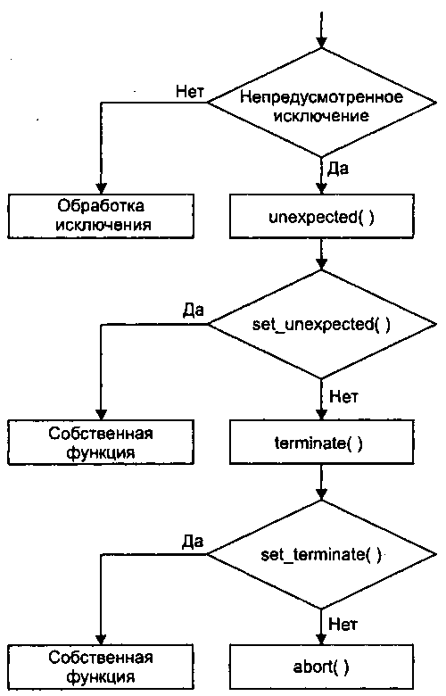

Рис. 7.1. Алгоритм обработки исключения

Типы исключений перечисляются в скобках через запятую после ключевого слова `throw`, расположенного за списком параметров функции, например:

```
void f1() throw (int, const char*) { /* Тело функции */ }
void f2() throw (Oops*) { /* Тело функции */ }
```

Функция `f1` должна генерировать исключения только типов `int` и `const char*`. Функция `f2` должна генерировать только исключения типа указателя на класс `Oops` или производных от него классов. Если ключевое слово `throw` не указано, функция может генерировать любое исключение. Пустой список означает, что функция не должна порождать исключений:

```
void f() throw() {
    // Тело функции, не порождающей исключений
}
```

Страница 228

Исключения не входят в прототип функции. При переопределении в производном классе виртуальной функции можно задавать список исключений, такой же или более ограниченный, чем в соответствующей функции базового класса. Указание списка исключений ни к чему не обязывает - функция может прямо или косвенно породить исключение, которое она обещала не использовать. Эта ситуация обнаруживается во время исполнения программы и приводит к вызову стандартной функции `unexpected`, которая по умолчанию просто вызывает функцию `terminate`. С помощью функции set_unexpected можно установить собственную функцию, которая будет вызываться вместо terminate и определять действие программы при возникновении непредвиденной исключительной ситуации. Функция `terminate` по умолчанию вызывает функцию `abort`, которая завершает выполнение программы. С помощью функции `set_terminate` можно установить бственную функцию, которая будет вызываться вместо `abort` и определять способ завершения программы. Функции `set _unexpected` и `set_terminate` описаны в заголовочном файле ‹exception›.

# Исключения в конструкторах и деструкторах

Язык С++ не позволяет возвращать значение из конструктора и деструктора. Механизм исключений дает возможность сообщить об ошибке, возникшей в конструкторе или деструкторе объекта. Для иллюстрации создадим класс `Vector`, в котором ограничивается количество запрашиваемой памяти:

```
class Vector
{
    public:
        class Size{}; // Класс исключения
        enum {max = 32000}; // Максимальная длина
        Vector(int n) // Конструктор
        {
            if (n<0 || n>max)
                throw Size();
            //...
        }
        //...
};
```

При использовании класса Vector можно предусмотреть перехват исключений типа `Size`:

```
try
{
    Vector *p = new Vector (i);
    //...
}
catch(Vector::Size)
{
    ... // Обработка ошибки размера вектора
}
```

В обработчике может использоваться стандартный набор основных способов выдачи сообщений об ошибке и восстановления. Внутри класса, определяющего исключение, может храниться информация об исключении, которая передается обработчику. Смысл этой техники заключается в том, чтобы обеспечить передачу информации об ошибке из точки ее обнаружения в место, где для обработки ошибки имеется достаточно возможностей. Если в конструкторе объекта генерируется исключение, автоматически вызыва- ются деструкторы для полностью созданных в этом блоке к текущему моменту объектов, а также для полей данных текущего объекта, являющихся объектами, и для его базовых классов. Например, если исключение возникло при создании массива объектов, деструкторы будут вызваны только для успешно созданных элементов. Если объект создается в динамической памяти с помощью операции nw и в конструкторе возникнет исключение, память из-под объекта корректно освобождается.

Страница 228

# Иерархии исключений

Использование собственных классов исключений предпочтительнее применени cтандартных типов данных. С помощью классов можно более гибко организоват передачу информации об исключении, легче дифференцировать обработку исключений, а кроме того, появляется возможность использовать иерархии классов. Поскольку механизм управления исключениями позволяет создать обработчик для базового класса, родственные исключения часто можно представить в виде иерархии. Производя исключения от общего базового класса, можно в обработчике перехватывать ссылку или указатель на базовый класс, используя полиморфизм. Например, в математической библиотеке можно организовать классы следующим образом:

```
class Matherr{};
class Overflow: public Matherr{}; // Переполнение
class Underflow: public Matherr{}; // Исчезновение порядка
class ZeroDivide: public Matherr{}; // Деление на оль
```

Страница 229

Для представления ошибок ввода/вывода могут использоваться следующие классы:

```
class I0err(};
class Readerr: public IOerr{}; // Ошибка чтения
class Writerr: public IOerr{}; // ибка записи
class Seekerr: public IOerr}; // Ошибка поиска
```

В зависимости от обстоятельств можно использовать либо обработчик исключений базового класса, который будет перехватывать и производные исключения, либо собственные обработчики производных классов. Существует ряд стандартных исключений, которые генерируются операциями или функциями `С++` (см. главу 16 «Другие средства стандартной библиотеки», с. 378). Все они являются производными от библиотечного класса exception, описанного в заголовочном файле `<stdexcept>`. Например, операция new при неудачном выделении памяти генерирует исключение типа `bad _alloc`. Программист может определить собственные исключения, производные от стандартных.

Страница 230

# ГЛАВА 8

### Преобразования типов

При выполнении программы производятся явные и неявные преобразования величин из одного типа в другой. Неявные преобразования выполняются в соответствии с правилами, приведёнными на с. 38 и в приложении 3. Для выполнения явных преобразований типа в C++ существует целая группа операций — `const_cast`, `dynamic_cast`, `reinterpret_cast` и `static_cast`, а также операция приведения типа, унаследованная из языка C, которая уже использовалась в этой книге. Для начала рассмотрим её подробнее.

# Операция приведения типов в стиле С

Операция может записываться в двух формах:

```
тип (выражение)
(тип) выражение
```

Результатом операции является значение заданного типа, например:

```
int a = 2;
float b = 6.8;
printf("Glf %d", double (a). (int) b);
```

Величина `a` преобразуется к типу `double`, а переменная `b` — к типу `int` с отсечением дробной части. В обоих случаях внутренняя форма представления результата операции преобразования иная, чем форма исходного значения. Необходимость в преобразовании типа возникает, например, в случае, когда функция возвращает указатель на тип `void`, который требуется присвоить переменной конкретного типа для последующего выполнения с ней каких-либо действий:

```
float *q = (float *) malloc(100 * sizeof(float));
```

Явное преобразование типа является источником возможных ошибок, поскольку вся ответственность за его результат возлагается на программиста. Поэтому в C++ введены операции, позволяющие выполнять частичный контроль выполняемых преобразований. Операция приведения типа, унаследованная из C, оставлена только для нисходящей совместимости, и использовать её не рекомендуется. В зависимости от вида требуемого преобразования необходимо использовать соответствующую ему операцию приведения типа.

# ПРИМЕЧАНИЕ

В ранних версиях компиляторов C++ операции приведения типа `const_cast`, `dynamic_cast`, `reinterpret_cast` и `static_cast` не поддерживаются.

Страница 231

# Операция const_cast

Операция `const_cast` служит для удаления модификатора `const`. Как правило, она используется при передаче в функцию константного указателя на место формального параметра, не имеющего модификатора `const`. Формат операции:

```
const_cast <тип> (выражение)
```

Обозначенный тип должен быть таким же, как и тип выражения, за исключением модификатора `const`. Обычно это указатель. Операция формирует результат указанного типа.

Необходимость введения этой операции обусловлена тем, что программист, реализующий функцию, не обязан описывать не изменяемые в ней формальные параметры как `const`, хотя это и рекомендуется. Правила C++ запрещают передачу константного указателя на место обычного. Операция `const_cast` введена для того, чтобы обойти это ограничение. Естественно, функция не должна пытаться изменить значение, на которое ссылается передаваемый указатель, иначе результат выполнения программы не определён.

**Пример**:

```
void print(int *p)
{
    cout << *p; // Функция не изменяет значение *p
}
const int *p;
//...
// print(p);
// Ошибка, поскольку p объявлен как указатель на константу
print(const_cast<int *>(p)); // Правильно: удаляем модификатор const
```

Операция `const_cast` используется в том случае, когда программист уверен, что в теле функции значение, на которое ссылается указатель, не изменяется. Естественно, если есть возможность добавить к описанию формального параметра модификатор `const`, это предпочтительнее использования преобразования типа при вызове функции.

# Операция dynamic_cast

Операция `dynamic_cast` применяется для преобразования указателей родственных классов иерархии, в основном — указателя базового класса в указатель на производный класс, при этом во время выполнения программы производится проверка допустимости преобразования.  
Формат операции:

```
dynamic_cast <тип *> (выражение)
```

Выражение должно быть указателем или ссылкой на класс, тип — базовым или производным для этого класса. После проверки допустимости преобразования в случае успешного выполнения операция формирует результат заданного типа, в противном случае для указателя результат равен нулю, а для ссылки порождается исключение `bad_cast`. Если заданный тип и тип выражения не относятся к одной иерархии, преобразование не допускается. Преобразование из базового класса в производный называют понижающим (`downcast`), так как графически в иерархии наследования принято изображать производные классы ниже базовых. Приведение из производного класса в базовый называют повышающим (`upcast`), а приведение между производными классами одного базового или, наоборот, между базовыми классами одного производного — перекрестным (`crosscast`).

Страница 232

# Повышающее преобразование

Выполнение с помощью операции `dynamic_cast` повышающего преобразования равносильно простому присваиванию:

```
class B { /* ... */ };
class C : public B { /* ... */ };
C* c = new C;
B* b = dynamic_cast<B*>(c); // Эквивалентно B* b = c;
```

Если выражение равно нулю, результат также равен нулю?

# Понижающее преобразование

Чаще всего операция `dynamic_cast` применяется при понижающем преобразовании — когда компилятор не имеет возможности проверить правильность приведения. Производные классы могут содержать функции, которых нет в базовых классах. Для их вызова через указатель базового класса нужно иметь уверенность, что этот указатель в действительности ссылается на объект производного класса. Такая проверка производится в момент выполнения приведения типа с использованием RTTI (run-time type information) — «информации о типе во время выполнения программы». Для того чтобы проверка допустимости могла быть выполнена, аргумент операции `dynamic_cast` должен быть полиморфного типа, то есть иметь хотя бы один виртуальный метод.

Страница 234

# ПРИМЕЧАНИЕ

Для использования RTTI необходимо подключить к программе заголовочный файл `<typeinfo>`. Кроме того, необходимо, чтобы был установлен соответствующий режим компилятора.

Для полиморфного объекта реализация операции `dynamic_cast` весьма эффективна, поскольку ссылка на информацию о типе объекта заносится в таблицу виртуальных методов, и доступ к ней осуществляется легко.

С точки зрения логики требование, чтобы объект был полиморфным, также оправдано: ведь если класс не имеет виртуальных методов, его нельзя безопасным образом использовать, не зная точный тип указателя. А если тип известен, использовать операцию `dynamic_cast` нет необходимости.

Результат применения операции `dynamic_cast` к указателю всегда требуется проверять явным образом. В приведённом ниже примере описан полиморфный базовый класс `B` и производный от него класс `C`, в котором определена функция `f2`. Для того чтобы вызывать её из функции `demo` только в случае, когда последней передаётся указатель на объект производного класса, используется операция `dynamic_cast` с проверкой результата преобразования:

```
#include <iostream.h>
#include <typeinfo.h>

class B {
public:
    virtual void f1() {}
};

class C : public B {
public:
    void f2() { cout << "f2"; }
};

void demo(B* p) {
    C* c = dynamic_cast<C*>(p);
    if (c) c->f2();
    else cout << "Передан не класс С";
}

int main() {
    B* b = new B;
    demo(b); // Выдаётся сообщение "Передан не класс С"
    C* c = new C;
    demo(c); // Выдаётся сообщение "f2" (правильно)
    return 0;
}
```

Страница 234

При использовании в этом примере вместо `dynamic_cast` приведения типов в стиле C, например:

```
C* c = (C*) p;
```

проконтролировать допустимость операции невозможно, и если указатель `p` на самом деле не ссылается на объект класса `C`, это приведёт к ошибке. Другим недостатком приведения в стиле C является невозможность преобразования в производный виртуального базового класса — это запрещено синтаксически. С помощью операции `dynamic_cast` такое преобразование возможно при условии, что класс является полиморфным и преобразование недвусмысленно. Рассмотрим пример, в котором выполняется понижающее преобразование виртуального базового класса:

```
#include <iostream.h>
#include <typeinfo.h>
class A {
public:
    virtual ~A() {}
};
class B : public virtual A {};
class C : public virtual A {};
class D : public B, public C {};
void demo(A *a) {
    D* d = dynamic_cast<D*>(a);
    if (d) { /* ... */ }
}
int main() {
    D *d = new D;
    demo(d);
    return 0;
}
```

# Преобразование ссылок

Для аргумента-ссылки смысл операции преобразования несколько иной, чем для указателя. Поскольку ссылка всегда указывает на конкретный объект, операция `dynamic_cast` должна выполнять преобразование именно к типу этого объекта. Корректность приведения проверяется автоматически, в случае несовпадения порождается исключение `bad_cast`:

```
#include <iostream.h>
#include <typeinfo.h>
class B {
public:
    virtual void f1() {}
};
class C : public B {
public:
    void f2() { /* ... */ }
};
void demo(B& p) {
    try {
        C& c = dynamic_cast<C&>(p);
        c.f2();
    }
    catch(bad_cast) {
        cout << "Ошибка приведения" << endl;
    }
}
int main() {
    B* b = new B;
    demo(*b); // Порождается исключение
    C* c = new C;
    demo(*c); // Правильно
    return 0;
}
```

Страница 235

# Перекрестное преобразование

Операция `dynamic_cast` позволяет выполнять безопасное преобразование типа между производными классами одного базового класса.

```
#include <iostream.h>
#include <typeinfo.h>
class B {
public:
    virtual void f1() {}
};
class C : public B {
public:
    void f2() { /* ... */ }
};
class D : public B { /* ... */ };
void demo(D* p) {
    C* c = dynamic_cast<C*>(p);
    if (c) c->f2();
    else cout << "не выполнено";
}
int main() {
    B* b = new C;
    demo((D*)b);
    return 0;
}
```

Классы `C` и `D` являются производными от класса `B`. Функции `demo` передаётся указатель на класс `D`, являющийся на самом деле указателем на «братский» для него класс `C`, поэтому динамическое преобразование типа из `D*` в `C*` в функции `demo` завершается успешно.

**ПРИМЕЧАНИЕ**  
Указатель для передачи в функцию сформирован искусственным образом исключительно для демонстрации возможности динамического преобразования типа.

При необходимости можно осуществить преобразование между базовыми классами одного производного класса.

```
#include <iostream.h>
#include <typeinfo.h>
class B {
public:
    virtual void f1() {} // B
};
class C {
public:
    virtual void f2() { /* ... */ } // C
};
```

Страница 237

```
class D : public B, public C {};
void demo(B* b) {
    C* c = dynamic_cast<C*>(b);
    if (c) c->f2();
}
int main() {
    D* d = new D;
    demo(d);
    return 0;
}
```

Класс `D` является потомком `B` и `C`, поэтому содержит методы обоих классов. Если в функцию `demo` передаётся на самом деле указатель не на `B`, а на `D`, его можно преобразовать ко второму базовому классу `C`.

# Операция static_cast

Операция `static_cast` используется для преобразования типа на этапе компиляции между:

- целыми типами;
- целыми и вещественными типами;
- целыми и перечисляемыми типами;
- указателями и ссылками на объекты одной иерархии, при условии, что оно однозначно и не связано с понижающим преобразованием виртуального базового класса.

```
static_cast <тип> (выражение)
```

Результат операции имеет указанный тип, который может быть ссылкой, указателем, арифметическим или перечисляемым типом. При выполнении операции внутреннее представление данных может быть модифицировано, хотя численное значение остаётся неизменным. Например:

```
float f = 100;
int i = static_cast<int>(f); // Целые и вещественные имеют различное внутреннее представление
```

Такого рода преобразования применяются обычно для подавления сообщений компилятора о возможной потере данных в том случае, когда есть уверенность, что требуется выполнить именно это действие. Результат преобразования остаётся на совести программиста.

Операция `static_cast` позволяет выполнять преобразования из производного класса в базовый и наоборот без ограничений:

```
class B {};
class C : public B {};
C c;
B b;
B *bp = static_cast<B*>(&c); // Производный -> базовый
C &cp = static_cast<C&>(b);   // Базовый -> производный
```

Преобразование выполняется при компиляции, при этом объекты могут не быть полиморфными. Программист должен сам отслеживать допустимость дальнейших действий с преобразованными величинами. В общем случае для преобразования указателей родственных классов иерархии предпочтительнее использовать операцию `dynamic_cast`. В этом случае, если преобразование возможно на этапе компиляции, генерируется тот же код, что и для `static_cast`. Кроме того, `dynamic_cast` допускает перекрестное преобразование, нисходящее приведение виртуального базового класса и производит проверку допустимости приведения во время выполнения.

Страница 237

# Операция reinterpret_cast

Операция `reinterpret_cast` применяется для преобразования не связанных между собой типов, например, указателей в целые или наоборот, а также указателей типа `void*` в конкретный тип. При этом внутреннее представление данных остаётся неизменным, а изменяется только точка зрения компилятора на данные.

```
reinterpret_cast <тип> (выражение)
```

Результат операции имеет указанный тип, который может быть ссылкой, указателем, целым или вещественным типом.

```
char *p = reinterpret_cast<char*>(malloc(100));
long l = reinterpret_cast<long>(p);
```

Различие между `static_cast` и `reinterpret_cast` позволяет компилятору производить минимальную проверку при использовании `static_cast`, а программисту — обозначать опасные преобразования с помощью `reinterpret_cast`. Результат преобразования остаётся на совести программиста.

# Динамическое определение типа

Механизм идентификации типа во время выполнения программы (RTTI) позволяет определять, на какой тип в текущий момент времени ссылается указатель, а также сравнивать типы объектов. Для доступа к RTTI в стандарт языка введена операция `typeid` и класс `type_info`. (В старых версиях компиляторов этот класс может называться `Type_info` или `typeinfo`.)

```
typeid(тип)
typeid(выражение)
```

Операция принимает в качестве параметра имя типа или выражение и возвращает ссылку на объект класса `type_info`, содержащий информацию о типе. Если операция не может определить тип операнда, порождается исключение `bad_typeid`. Когда операнд представляет собой указатель или ссылку на полиморфный тип, результатом является динамическая информация о типе (то есть объект `type_info` содержит информацию о типе объекта, на который в данный момент ссылается указатель). Если операндом является выражение, представляющее собой ссылку на неполиморфный тип, объект `type_info` содержит информацию о типе выражения, а не о типе объекта, на который оно ссылается. Операцию `typeid` можно использовать как с основными, так и с производными типами данных.

Страница 238

Класс `type_info` описан в заголовочном файле `<typeinfo>` следующим образом:

```
class type_info {
public:
    virtual ~type_info();
    bool operator==(const type_info& rhs) const;
    bool operator!=(const type_info& rhs) const;
    bool before(const type_info& rhs) const;
    const char* name() const;
private:
    type_info(const type_info& rhs);
    type_info& operator=(const type_info& rhs);
};
```

Метод `name()` возвращает указатель на строку, представляющую имя типа, описываемого объектом типа `type_info`. Виртуальный деструктор делает класс `type_info` полиморфным. Конструктор копирования и операция присваивания объявлены как `private`, чтобы исключить возможность случайного копирования и присваивания объектов класса.

Операции `==` и `!=` позволяют сравнивать два объекта на равенство и неравенство, а функция `before` выполняет побуквенное сравнение имён двух типов. Для сравнения используется конструкция вида:

```
typeid(T1).before(typeid(T2))
```

Если имя типа `T1` лексикографически предшествует имени `T2`, результат будет истинным. Точная информация о типе объекта во время выполнения программы может потребоваться, например, когда программист расширяет функциональность некоторого библиотечного базового класса с помощью производного, и невозможно или бессмысленно добавлять к базовому классу виртуальные функции. Например:

```
#include <typeinfo.h>
class B {
public:
    virtual ~B() {}
};
class C : public B {
public:
    virtual void some_method() { /* ... */ }
};
void demo(B* p) {
    if (typeid(*p) == typeid(C))
        dynamic_cast<C*>(p)->some_method();
}
int main() {
    C* c = new C;
    demo(c);
    return 0;
}
```

Страница 239

Информацию о типе полезно использовать и в диагностических целях:

```
void print_type(some_obj *p) {
    cout << typeid(*p).name();
}
```

Операция `typeid` не должна применяться вместо виртуальных функций и в случаях, когда тип объекта можно определить на этапе компиляции.

Страница 240

# ГЛАВА 9

# Рекомендации по программированию

В этой части были рассмотрены объектно-ориентированные возможности языка C++, и теперь пришло время остановиться на проблемах, которые возникают в процессе написания программ: какие средства языка предпочтительнее выбирать в разных случаях, на что обратить особое внимание, чего нужно избегать, чтобы программа получилась эффективной и легко сопровождаемой. Однозначные рекомендации, как всегда, дать невозможно — только понимание механизма работы C++ позволит грамотно его использовать. Создание любого программного продукта начинается с процесса проектирования, и одна из первых задач, возникающих при этом, — определить, должна программа быть объектно-ориентированной или нет. Объектно-ориентированное программирование, применённое к задаче, в которой в нём нет необходимости, только увеличит объём программы и сложность её написания. Если в процессе анализа постановки задачи выясняется, что необходимости в иерархии классов нет, чаще всего можно обойтись структурным подходом. Б. Страуструп считает, что «везде, где не нужно более одного объекта определённого типа, достаточно стиля программирования с сокрытием данных при помощи модулей». Смешивать два подхода в одном проекте не рекомендуется, поскольку может оказаться, что готовый продукт обладает недостатками и структурного, и объектно-ориентированного принципов построения. Технологии проектирования программ посвящено много литературы, и освещение этого вопроса не входит в задачу данной книги. Тем, кто собирается приниматься за серьёзные программные проекты, рекомендуется предварительно изучить ставшие классическими книги Ф. Брукса, Г. Буча и Б. Страуструпа. Далее рассматриваются вопросы, на которые следует обращать внимание на следующем этапе создания программы — в процессе написания программного кода. При создании класса, то есть нового типа данных, следует хорошо продумать его интерфейс — средства работы с классом, доступные использующим его программистам. Интерфейс хорошо спроектированного класса интуитивно ясен, непротиворечив и обозрим. Как правило, он должен включать только методы, но не поля данных. Поля данных должны быть скрытыми (`private`). Это даёт возможность впоследствии изменить реализацию класса без изменений в его интерфейсе, а также регулировать доступ к полям класса с помощью набора предоставляемых пользователю методов.

Страница 241

Не следует определять методы типа `get`/`set` для всех скрытых полей класса — это всё равно что открыть к ним доступ, только более сложным способом. Важно помнить, что поля класса вводятся только для того, чтобы реализовать свойства класса, представленные в его интерфейсе с помощью методов. Конечно, нет ничего плохого в том, чтобы установить или получить значение некоторого поля с помощью метода, если таким образом реализуется свойство класса (таким образом, код будет тот же, а его смысл — совсем другим). Не нужно расширять интерфейс класса без необходимости, «на всякий случай», поскольку увеличение количества методов ведёт к трудности понимания класса пользователем*. В идеале интерфейс должен быть полным, то есть предоставлять возможность выполнить любые разумные действия с классом, и минимальным — без дублирования и пересечения возможностей методов. Под пользователем имеется в виду программист, использующий класс. В виде методов рекомендуется определять только действия, реализующие свойства класса. Если какое-либо действие можно реализовать, не обращаясь к скрытым полям класса, его нет необходимости описывать как метод; лучше описать его как обычную функцию, поместив её в общее с классом пространство имён. Если функция выполняет действие, не являющееся свойством класса, но нуждается в доступе к его скрытым полям, её следует объявить как дружественную. Но в общем случае дружественных функций и классов надо избегать, поскольку главной идеей ООП является минимизация связей между инкапсулированными классами. Для увеличения производительности программы наиболее часто вызываемые методы можно объявить как встроенные (`inline`). В основном это касается коротких методов, тело которых оказывается меньше размера кода, генерируемого для их вызова. Кроме ускорения программы за счёт исключения вызовов, это даёт возможность компилятору производить более полную оптимизацию. Однако необходимо учитывать, что директива `inline` носит для компилятора рекомендательный характер, и он может ей не последовать — например, если метод содержит сложные циклы или объявлен как виртуальный. Кроме того, если программа или компилятор используют указатель на метод или функцию, дополнительно будет сгенерирована их невстраиваемая копия. Ещё одним соображением, которое требуется принимать во внимание, является то, что многие отладчики имеют проблемы со встраиваемыми функциями.

Страница 242

Перегруженные операции класса должны иметь интуитивно понятный общепринятый смысл (например, не следует заставлять операцию `+` выполнять что-либо, кроме сложения или добавления). В основном перегрузка операций используется для создаваемых программистом арифметических типов, а в остальных случаях для реализации каких-либо действий с объектами класса предпочтительнее использовать методы, поскольку им можно дать осмысленные имена. Если какая-либо операция перегружена, следует, если возможно, перегрузить и аналогичные операции, например, `+`, `+=` и `++` (компилятор этого автоматически не сделает). При этом операции должны иметь ту же семантику, что и их стандартные аналоги. Основой любого класса являются его конструкторы и деструкторы. Как известно, при отсутствии явно заданных конструкторов, конструктора копирования и операции присваивания компилятор создаёт их автоматически. И конструктор копирования, и операция присваивания, создаваемые по умолчанию, выполняют поэлементное копирование из области-источника в область-приёмник. Если объект содержит указатели, это приведёт к тому, что после копирования два соответствующих указателя разных объектов будут ссылаться на одну и ту же область памяти. При уничтожении первого из объектов эта память будет освобождена, а повторная попытка освободить её при уничтожении второго объекта приведёт к неопределённому поведению программы. Поэтому для классов, содержащих поля-указатели, следует всегда явно определять конструктор копирования и операцию присваивания, выполняющие выделение памяти под динамические поля объекта.

Кроме того, динамическая память, выделенная в конструкторе объекта, должна освобождаться в его деструкторе. Невыполнение этого требования приводит к утечкам памяти. Удаление нулевого указателя безопасно (при этом ничего не происходит), поэтому если конструкторы, конструкторы копирования и операция присваивания написаны правильно, любой указатель либо ссылается на выделенную область памяти, либо равен нулю, и к нему можно применять `delete` без проверки. Разница между конструктором копирования и операцией присваивания заключается в том, что последняя работает в том случае, когда объект-приёмник уже существует, поэтому в ней перед выделением динамической памяти следует освободить занятую ранее. Из этого следует, что при реализации операции присваивания для классов, содержащих поля-указатели, необходимо проводить проверку на самоприсваивание и в этом случае оставить объект без изменений. Необходимо также помнить о том, что операция присваивания должна возвращать ссылку на константу. Таким образом, определение операции присваивания должно иметь вид:

```
class X {
    // ...
    const X& operator=(const X& r);
};
const X & X:: operator=(const X & r)
{
    if(this != &r)
    {
        // Копирование
    }
    return *this;
}
```

Страница 243

В конструкторах для задания иачальных значений полям рекомендуется использовать инициализацию, а не присваивание:

```
class X
{
        string s;
    public:
        X(const char * str);
}:
// Вариант конструктора с присваиванием:
X::X(const char * str)
{
    s = str;
}
// Вариант конструктора с инициализацией:
X::X(const char * str): s(str) {}
```

Инициализация более универсальна, так как может применяться в тех случаях, когда присваиванием пользоваться нельзя (например, при задании значений константным полям или ссылкам). Кроме того, она выполняется более эффективно, потому что создание объекта в C++ начинается с инициализации его полей конструктором по умолчанию, после чего выполняется вызываемый конструктор. Таким образом, для первого варианта рассмотренного примера сначала будет вызван конструктор класса `string` по умолчанию, и только потом будет выполнено присваивание, в то время как второй вариант позволяет сразу же вызвать нужный конструктор. Для сложных классов, составляющих иерархию, разница между приведёнными вариантами гораздо значительнее.

Необходимо учитывать и тот факт, что поля инициализируются в порядке их объявления, а не в порядке появления в списке инициализации. Поэтому для уменьшения числа возможных ошибок порядок указания полей в списке инициализации конструктора должен соответствовать порядку их объявления в классе. Статические поля не должны инициализироваться в конструкторе, поскольку им нужно присваивать начальное значение только один раз для каждого класса, а конструктор выполняется для каждого объекта класса. Статические поля инициализируются в глобальной области определения (вне любой функции). Конструкторы копирования также должны использовать списки инициализации полей, поскольку иначе для базовых классов и вложенных объектов будут вызваны конструкторы по умолчанию.

```
class X
{
    public:
        X(void);
        // Конструктор копирования:
        X(const X & r);
};
class Y: public X
{
        string s; // Вложенный объект
    public:
    // Конструктор копирования:
        Y(const Y & r): X(r).s(r.s){}
};
```

Страница 244

Операция присваивания не наследуется, поэтому она должна быть определена в производных классах. При этом из неё следует явным образом вызывать соответствующую операцию базового класса. Наследование классов предоставляет программисту богатейшие возможности — виртуальные и невиртуальные базовые классы, открытое, защищённое и закрытое наследование, виртуальные методы и т. д. Выбор наиболее подходящих возможностей для целей конкретного проекта основывается на знании механизма их работы и взаимодействия. Открытое наследование класса `Y` из класса `X` означает, что `Y` представляет собой разновидность класса `X`, то есть более конкретную, частную концепцию. Базовый класс `X` является более общим понятием, чем `Y`. Везде, где можно использовать `X`, можно использовать и `Y`, но не наоборот (вспомните, что на место ссылок на базовый класс можно передавать ссылку на любой из производных). Необходимо помнить, что во время выполнения программы не существует иерархии классов и передачи сообщений объектам базового класса из производных — есть только конкретные объекты классов, поля которых формируются на основе иерархии на этапе компиляции. Методы, которые должны иметь все производные классы, но которые не могут быть реализованы на уровне базового класса, должны быть виртуальными. Например, все объекты иерархии должны уметь выводить информацию о себе. Поскольку она хранится в различных полях производных классов, эту функцию нельзя реализовать в базовом классе. Естественно назвать её во всех классах одинаково и объявить как виртуальную с тем, чтобы другие методы базового класса могли вызывать её в зависимости от фактического типа объекта, с которым они работают. По этой причине деструкторы объявляются как виртуальные. При переопределении виртуальных методов нельзя изменять наследуемое значение аргумента по умолчанию, поскольку по правилам C++ оно определяется типом указателя, а не фактическим типом объекта, вызвавшего метод.

```
#include <iostream.h>
class X
{
    public:
        virtual void fun(int a = 0)
        {
            cout << a;
        }
}:
class Y: public X
{
    public:
        virtual void fun(int a = 1)
        {
            cout << a;
        }
};
int main()
{
    X *px = new X;
    px-> fun(); // Выводится 0
    X *py = new Y;
    py-›fun(); // Выводится 0
}
```

Страница 245

Невиртуальные методы переопределять в производных классах не рекомендуется, поскольку производные классы должны наследовать свойства базовых. Иными словами, невиртуальный метод инвариантен относительно специализации, то есть сохраняет те свойства, которые должны наследоваться из базового класса независимо от того, как конкретизируется (специализируется) производный класс. Специализация производного класса достигается добавлением новых методов и переопределением существующих виртуальных методов. **Главное преимущество наследования** состоит в том, что можно на уровне базового класса написать универсальный код, с помощью которого можно работать и с объектами производного класса, что реализуется с помощью виртуальных методов. Альтернативным наследованию методом использования одним классом другого является вложение, когда один класс является полем другого:

```
class X
{
    //...
};
class Y
{
    X x;
    //...
};
```

Вложение представляет отношения классов «Y содержит X» или «Y реализуется посредством X». Необходимость использовать вложение вместо наследования можно определить, задав себе вопрос, может ли у Y быть несколько объектов класса X. Если требуется, к примеру, описать класс для моделирования самолёта, будет логично описать в нём поле типа «двигатель»: самолёт содержит двигатель, но не является его разновидностью. Отношение «реализуется посредством» используется вместо наследования тогда, когда про классы X и Y нельзя сказать, что Y является разновидностью X, но при этом Y использует часть функциональности X. Следует предпочитать вложение наследованию. В случаях, когда между классами нет логической взаимосвязи, а требуется просто использовать часть кода одного класса в другом, может быть полезным использовать закрытое наследование (с ключом доступа `private`). Этот способ используется, когда в производном классе требуется доступ к защищённым элементам базового класса и замещение его виртуальных методов. Шаблоны классов используются для создания семейств классов, поведение которых не зависит от типа объектов. Шаблоны следует использовать аккуратно, отдавая себе отчёт в том, что для каждого типа порождается собственная копия шаблона, что может привести к разбуханию кода. Для уменьшения размера кода рекомендуется вынести в базовый класс все методы, не использующие информацию о типе объекта, и унаследовать от него шаблонный класс со всеми остальными методами. Это позволит избежать дублирования тех методов, тексты которых не зависят от параметра шаблона. Исключения используются, как правило, в тех случаях, когда иного способа сообщить об ошибке не существует (например, если она произошла в конструкторе или перегруженной операции), а также когда ошибка неисправимая или очень редкая и неожиданная. Обработка исключений несколько уменьшает производительность программы и, с моей точки зрения, ухудшает её читаемость, поэтому без необходимости пользоваться исключениями не нужно. Для более подробного изучения рассмотренных в этом разделе вопросов рекомендуется обратиться к книгам А. Голуба и С. Мейерса.

Страница 246

# Упражнения к части II

# Классы

# Вариант 1

Описать класс, реализующий стек. Написать программу, использующую этот класс для моделирования Т-образного сортировочного узла на железной дороге. Программа должна разделять на два направления состав, состоящий из вагонов двух типов (на каждое направление формируется состав из вагонов одного типа). Предусмотреть возможность формирования состава из файла и с клавиатуры.

# Вариант 2

Описать класс, реализующий бинарное дерево, обладающее возможностью довления новых элементов, удаления существующих, поиска элемента по ключу, а также последовательного доступа ко всем элементам. Написать программу, использующую этот класс для представления англо-русского словаря. Программа должна содержать меню, позволяющее осуществить проверку всех методов класса. Предусмотреть возможность формирования словаря из файла и с клавиатуры.

# Вариант 3

Построить систему классов для описания плоских геометрических фигур: круг, квадрат, прямоугольник. Предусмотреть методы для создания объектов, перемещения на плоскости, изменения размеров и вращения на заданный угол. Написать программу, демонстрирующую работу с этими классами. Программа должна содержать меню, позволяющее осуществить проверку всех методов классов.

# Вариант 4

Построить описание класса, содержащего информацию о почтовом адресе организации. Предусмотреть возможность раздельного изменения составных частей адреса, создания и уничтожения объектов этого класса. Написать программу, демонстрирующую работу с этим классом. Программа должна содержать меню, позволяющее осуществить проверку всех методов класса.

# Вариант 5

Составить описание класса для представления комплексных чисел. Обеспечить выполнение операций сложения, вычитания и умножения комплексных чисел. Написать программу, демонстрирующую работу с этим классом. Программа должна содержать меню, позволяющее осуществить проверку всех методов класса.

Страница 247

# Вариант 6

Составить описание класса для объектов-векторов, задаваемых координатами концов в трехмерном пространстве. Обеспечить операции сложения и вычитания векторов с получением нового вектора (суммы или разности), вычисления скалярного произведения двух векторов, длины вектора, косинуса угла между векторами. Написать программу, демонстрирующую работу с этим классом. Программа должна содержать меню, позволяющее осуществить проверку всех методов класса.

# Вариант 7

Составить описание класса прямоугольников со сторонами, параллельными осям координат. Предусмотреть возможность перемещения прямоугольников на плоскости, изменения размеров, построения наименьшего прямоугольника, содержащего два заданных прямоугольника, и прямоугольника, являющегося общей частью (пересечением) двух прямоугольников. Написать программу, демонстрирующую работу с этим классом. Программа должна содержать меню, позволяющее осуществить проверку всех методов класса.

# Вариант 8

Составить описание класса для определения одномерных массивов целых чисел (векторов). Предусмотреть возможность обращения к отдельному элементу массива с контролем выхода за пределы массива, возможность задания произвольных границ индексов при создании объекта и выполнения операций поэлементного сложения и вычитания массивов с одинаковыми границами индексов, умножения и деления всех элементов массива на скаляр, вывода на экран элемента массива по заданному индексу и всего массива. Написать программу, демонстрирующую работу с этим классом. Программа должна содержать меню, позволяющее осуществить проверку всех методов класса.

# Вариант 9

Составить описание класса для определения одномерных массивов строк фиксированной длины. Предусмотреть контроль выхода за пределы массива, возможность обращения к отдельным строкам массива по индексам, выполнения операций поэлементного сцепления двух массивов с образованием нового массива, слияния двух массивов с исключением повторяющихся элементов, а также вывод на экран элемента массива по заданному индексу и всего массива. Написать программу, демонстрирующую работу с этим классом. Программа должна содержать меню, позволяющее осуществить проверку всех методов класса.

# Вариант 10

Страница 248

# Вариант 11

Составить описание класса одномерных массивов строк, каждая строка задается длиной и указателем на выделенную для нее память. Предусмотреть контроль выхода за пределы массивов, возможность обращения к отдельным строкам массива по индексам, выполнения операций поэлементного сцепления двух массивов с образованием нового массива, слияния двух массивов с исключением повторяющихся элементов, а также вывод на экран элемента массива и всего массива. Написать программу, демонстрирующую работу с этим классом. Программа должна содержать мено, позволяющее осуществить проверку всех методов класса.

# Вариант 12

Составить описание класса, обеспечивающего представление матрицы произ вольного размера с возможностью изменения числа строк и столбцов, вывода на экран подматрицы любого размера и всей матрицы. Написать программу, демонстрирующую работу с этим классом. Программа должна содержать меню, позволяющее осуществить проверку всех методов класса.

# Вариант 13

Написать класс для эффективной работы со строками, позволяющий форматировать и сравнивать строки, хранить в строках числовые значения и извлекать их. Для этого необходимо реализовать:

- перегруженные операторы присваивания и конкатенации;
- операции сравнения и приведения типов;
- преобразование в число любого типа;
- форматный вывод строки.

Написать программу, демонстрирующую работу с этим классом. Программа должна содержать меню, позволяющее осуществить проверку всех методов класса.

# Вариант 14

Описать класс «домашняя библиотека». Предусмотреть возможность работы с произвольным числом книг, поиска книги по какому-либо признаку (например, по автору или по году издания), добавления книг в библиотеку, удаления книг из нее, сортировки книг по разным полям. Написать программу, демонстрирующую работу с этим классом. Программа должа содержать меню, позволяющее осуществить проверку всех методов класса.

Страница 250

# Вариант 15

Описать класс «записная книжка». Предусмотреть возможность работы с произзольным числом записей, поиска записи по какому-либо признаку (папример, по фамилии, дате рождения или померу телефопа), добавления и удаления записей, сортировки по разным полям. Написать программу, демонстрирующую работу с этим классом. Программа должна содержать меню, позволяющее осуществить проверку всех методов класса.

# Вариант 16

Описать класс «студенческая група». Предусмотреть возможность работы с перемешым числом студентов, поиска студента по какому-либо признаку (например, но фамилии, дате рождения или померу телефона), добавления и удаления записей, сортировки по разным полям. Написать программу, демонстрирующую работу с этим классом. Программа должна содержать мешо, позволяющее осуществить проверку всех методов класса.

# Вариант 17

Описать класс, реализующий тип данных «вещественная матрица» и работу с ними. Класс должен реализовывать следующие операции над матрицами:

- сложение, вычитание, умножение, деление (`+`, `-`, `*`, `/`) (умножение и деление как на другую матрицу, так и на число);
- комбинированые операции присваивания (`+=`, `-=`, `*=`, `/=`);
- операции сравнения на равенство/перавенство;
- операции вычисления обратной и транспопированной матрицы, операцию возведения в степень;
- методы вычисления детерминанта и нормы;
- методы, реализующие проверку типа матрицы (квадратная, диагональная, нулевая, единичная, симметрическая, верхняя треугольная, нижняя треугольная);
- операции ввода/вывода в стандартные потоки (см. с. 284).

Написать программу, демонстрирующую работу с этим классом. Программа должна содержать мешо, позволяющее осуществить проверку всех методов класса.

# Вариант 18

Описать класс «множество», позволяющий выполнять основные операции - добавление и удаление элемента, пересечение, объединение и разность множеств. Написать программу, демонстрирующую работу с этим классом. Программа должна содержать меню, позволяющее осуществить проверку всех методов класса.

# Вариант 19

Описать класс, реализующий стек. Написать программу, использующую этот класс для отыскания прохода по лабиринту. Табиринт представляется в виде матрицы, состоящей из квадратов. Каждый квадрат либо открыт, либо закрыт. Вход в закрытый квадрат запрещен. Если квадрат открыт, то вход в него возможен со стороны, но не с угла. Каждый квадрат определяется его координатами в матрице. После отыскания прохода программа печатает найденный путь в виде координат квадратов.

# Вариант 20

Описать класс «предметный указатель». Каждая компонента указателя содержит слово и номера страниц, на которых это слово встречается. Количество номеров страниц, относящихся к одному слову, от одного до десяти. Предусмотреть возможность формирования указателя с клавиатуры и из файла, вывода указателя, вывода номеров страниц для заданного слова, удаления элемента из указателя. Написать программу, демонстрирующую работу с этим классом. Программа должна содержать меню, позволяющее осуществить проверку всех методов класса.

Страница 252

# Наследование

# Вариант 1

Создать класс `CFile`, инкапсулирующий в себе такие функции работы с файлами, как `Open`, `Close`, `Seek`, `Read`, `Write`, `GetPosition` и `GetLength`. На базе этого класса создать производный класс `CMyDataFile` - файл, содержащий в себе данные некоторого определенного типа `MyData`, а также заголовок, облегчающий доступ к этому файлу. Написать программу, демонстрирующую работу с этими классами. Программа должна содержать меню, позволяющее осуществить проверку всех методов классов.

# Вариант 2

Создать класс `CPoint` - точка. На его основе создать классы `CcoloredPoint` и `CLine`. На основе класса `CLine` создать класс `CColoredLine` и класс `CPolyLine` — многоугольник. Все классы должны иметь методы для установки и получения значений всех координат, а также изменения цвета и получения текущего цвета. Написать демонстрационную программу, в которой будет использоваться список объектов этих классов в динамической памяти.

Страница 252

# Вариант 3

Создать абстрактный класс `CVehicle`. На его основе реализовать классы `CPlane`, `ССаг` и `CShip`. Классы должны иметь возможность задавать и получать координаты, параметры средств передвижения (цена, скорость, год выпуска). Для самолета должна быть определена высота, для самолета и корабля - количество пассажиров. Для корабля - порт приписки. Написать программу, создающую список объектов этих классов в динамической памяти. Программа должна содержать меню, позволяющее осуществить проверку всех методов классов.

# Вариант 4

1. Описать базовый класс «Элемент».

Поля:

- имя элемента (указатель на строку символов);
- количество входов элемента;
- количество выходов элемента.

Методы:

- конструктор класса;
- деструктор класса;
- метод, задающий имя элемента.
2. На основе класса «Элемент» описать производный класс «Комбинационный», представляющий собой комбинационный элемент (двоичный вентиль), который может иметь несколько входов и один выход. **Поля**: указатель, используемый для динамического размещения полей, содержащих значения входов.

Методы:

- конструктор;
- конструктор копирования;
- деструктор;
- метод, задающий значение на входах экземпляра класса;
- метод, позволяющий опрашивать состояние отдельного входа экземпляра класса;
- метод, вычисляющий значение выхода (по варианту задания).
3. На основе класса «Элемент» описать производный класс «Память», представляющих собой триггер. Триггер имеет входы, соответствующие типу триггера (см. ниже вариант задания), и входы установки и сброса. Все триггеры считаются синхронными, сам синхровход в состав триггера не включается.

Поля:

- массив значений входов объекта класса (задается статически), в массиве учитываются все входы (управляющие и информационные);
- состояние на прямом выходе триггера;
- состояние на инверсном выходе триггера.

Методы:

- конструктор (по умолчанию сбрасывает экземпляр класса);
- конструктор копирования;
- деструктор;
- метод, задающий значение на входах экземпляра класса;
- методы, позволяющие опрашивать состояния отдельного входа экземпляра класса;
- метод, вычисляющий состояние экземпляра класса (по варианту задания) в зависимости от текущего состояния и значений на входах;
- метод, переопределяющий операцию `==` для экземпляров класса.

Страница 253

4. Создать класс «Регистр», используя класс «Память» как включаемый класс. **Поля**:
- состояние входа «Сброс» - один для экземпляра класса;
- состояние входа «Установка» - один для экземпляра класса;
- статический массив типа «Память» задашой в варианте размерности;
- статический(е) массив(ы), содержащие значения на соответствующих входах элементов массива типа «Память».

Методы:

- метод, задающий значение на входах экземпляра класса (желательно в качестве параметров передавать методу указатели на массивы значений);
- метод, позволяющий опрашивать состояние отдельного выхода экземпляра класса;
- метод, вычисляющий значение нового состояния экземпляра класса.

Все поля классов «Элемент», «Комбинационый» и «Память» должны быть описаны с ключевым словом `private`, или `protected`. В задании перечислены только обязательные члены и методы класса. Можно задавать дополнительные члены и методы, если опи не отменяют обязательные и обеспечивают дополнительные удобства при работе с данными классами, например, описать функции вычисления выхода/состояния как виртуальные.

5. Для проверки функционирования созданных классов написать программу, использующую эти классы. В программе должны быть продемонстрированы все свойства созданных классов. Конкретный тип комбинационного элемента, тип триггера и разрядность регистра выбираются в соответствии с вариантом задания.

| Вариант | Комбинационный элемент | Число вxодов | Триггер | Разрядность регистра |
| --- | --- | --- | --- | --- |
| 1 | И-НЕ | 4 | RS | 8 |
| 2 | ИЛИ | 5 | RST | 10 |
| 3 | МОД2-НЕ | 6 | D | 12 |
| 4 | И | 8 | T | 8 |
| 5 | ИЛИ-НЕ | 8 | V | 9 |
| 6 | И | 4 | RS | 10 |
| 7 | ИЛИ-НЕ | 5 | JK | 11 |
| 8 | МОД2 | 5 | D | 8 |
| 9 | И | 4 | T | 10 |
| 10 | Или | 3 | JK | 8 |

Страница 254

| Вариант | Комбинационный элемент | Число вxодов | Триггер | Разрядность регистра |
| --- | --- | --- | --- | --- |
| 11 | И-НЕ | 3 | RS | 12 |
| 12 | ИЛИ-НЕ | 4 | RST | 4 |
| 13 | МОД2 | 5 | D | 10 |
| 14 | МОД2-НЕ | 6 | Т | 10 |
| 15 | ИЛИ-НЕ | 8 | V | 10 |
| 16 | И | 8 | JK | 6 |
| 17 | И-НЕ | 8 | RS | 10 |
| 18 | ИЛИ | 8 | Т | 10 |
| 19 | МОД2 | 6 | JK | 8 |
| 20 | МОД2-НЕ | 5 | V | 10 |

# Вариант 5

Описать базовый класс `СТРОКА`. Обязательные поля класса:

- указатель на `char` — хранит адрес динамически выделешной памяти для размещения символов строки;
- значение типа `int` — хранит длину строки в байтах.

Обязательные методы:

- конструктор без параметров;
- конструктор, принимающий в качестве параметра С-строку (заканчивается нулевым байтом)
- конструктор, припимающий в качестве параметра символ;
- конструктор копирования;
- получение длины строки;
- очистка строки (сделать строку пустой);
- деструктор.

Описать производный от `СТРОКА` класс `СТРОКА_ИДЕНТИФИКАТОР`. Строки данного класса строятся по правилам записи идентификаторов в языке `С` и могут включать в себя только те символы, которые могут входить в состав `С`-идентификаторов. Если исходные данные противоречат правилам записи идептификатора, то создается пустая `СТРОКА_ИДЕНТИФИКАТОР`.

Страница 255

Обязательные методы:

- конструктор без параметров;
- конструктор, принимающий в качестве параметра С-строку (заканчивается нулевым байтом);
- конструктор, принимающий в качестве параметра символ;
- конструктор копирования;
- перевод всех символов строки в верхний регистр;
- перевод всех символов строки в нижний регистр;
- поиск первого вхождения символа в строку;
- деструктор.

Переопределить следующие операции:

- присваивание (`=`);
- сложение (`+`) - операция конкатенации строк;
- вычитание (`-`) - из строки (первый операнд) удаляются все символы, входящие в строку - второй операнд, при этом может получиться пустая строка;
- операция (`<`) - проверка на больше. Строка считается больше другой, если код символа первой строки в `і`-й позиции (`і` изменяется от `0` до `n-1`, где `n` - длина более короткой строки) больше кода символа в той же позиции во второй строке, длины строк могут не совпадать

Разработчик вправе вводить любое (с обоснованием необходимости) число дополнительных полей и методов. **Написать тестовую программу, которая**:

- динамически выделяет массив указателей на базовый класс (4-6);
- в режиме диалога заполняет этот массив указателями на производные классы, при этом экземпляры производных классов создаются динамически с заданием начальных значений;
- для созданных экземпляров производных классов выполняет проверку всех разработанных методов с выводом исходных данных и результатов на дисплей.

Для конструкторов копирования каждого класса предусмотреть диагностическую печать количества его вызовов в определенное место дисплея (рекомендуется использовать статические члены класса). Режим диалога обеспечивается с помощью иерархического меню.

# Вариант 6

Описать базовый класс `СТРОКА`. Обязательные поля класса:

- указатель на char — храпит адрес динамически выделенной памяти для размещения символов строки;
- значение типа int — хранит длину строки в байтах.

Обязательные методы:

- конструктор без параметров;
- конструктор, принимающий в качестве параметра С-строку (заканчивается нулевым байтом);
- конструктор, принимающий в качестве параметра символ;
- конструктор копирования;
- получение длины строки;
- очистка строки (сделать строку пустой);
- деструктор.

Страница 256

Описать производный от `СТРОКА` класс `БИТОВАЯ_СТРОКА`. Строки данного класса могут содержать только символы `'0'` или `'1'`. Если в составе инициализирующей строки будут встречены любые символы, отличные от допустимых, `БИТОВАЯ_СТРОКА` принимает нулевое значение. Содержимое данных строк рассматривается как двоичное число. Отрицательные числа хранятся в дополнительном коде.

**Обязательные методы**:

- конструктор без параметров;
- конструктор, припимающий в качестве параметра С-строку (закапчивается нулевым байтом);
- конструктор копирования;
- деструктор;
- изменение знака на противоположный (перевод числа в дополнительный код).

Переопределить следующие операции (длина строки результата равна длине большей из строк; в случае необходимости более короткая битовая строка расширяется влево знаковым разрядом):

- присваивание `(=)`;
- сложение `(+)` - арифметическая сумма строк;
- операция `(=)` - проверка на равенство.

Разработчик вправе вводить любое (с обоснованием необходимости) число дополнительных полей и методов.

Написать тестовую программу, которая:

- динамически выделяет массив указателей на базовый класс (4-6);
- в режиме диалога заполняет этот массив указателями на производные классы, при этом экземпляры производных классов создаются динамически с заданием начальных значений;
- для созданных экземпляров производных классов выполняет проверку всех разработанных методов с выводом исходных данных и результатов на дисплей. Для конструкторов копирования каждого класса предусмотреть диагностическую печать количества его вызовов в определенное место дисплея (рекомендуется использовать статические члены класса). Режим диалога обеспечивается с помощью иерархического меню.

Страница 257

# Вариант 7

Описать базовый класс `СТРОКА`. **Обязательные поля класса**:

- указатель на `char` — хранит адрес динамически выделенной памяти для размещения символов строки;
- значение типа `int` - хранит длину строки в байтах.

Обязательные методы:

- конструктор без параметров;
- конструктор, принимающий в качестве параметра С-строку (заканчивается нулевым байтом);
- конструктор, принимающий в качестве параметра символ;
- конструктор копирования;
- получение длины строки;
- очистка строки (сделать строку пустой);
- деструктор.

Описать производный от `СТРОКА` класс `ДЕСЯТИЧНАЯ_СТРОКА`.

Строки данного класса могут содержать только символы десятичных цифр и символы `-` и `+`, задающие знак числа. Символы `-` или `+` могут находиться только в первой позиции числа, причем символ `+` может отсутствовать, в этом случае число считается положительным. Если в составе инициализирующей строки будут встречены любые символы, отличные от допустимых, `ДЕСЯТИЧНАЯ_СТРОКА` принимает нулевое значение. Содержимое данных строк рассматривается как десятичное число.

Обязательные методы:

- конструктор без параметров;
- конструктор, принимающий в качестве параметра `С`-строку (заканчивается нулевым байтом);
- конструктор копирования;
- деструктор;
- метод, определяющий, можно ли представить данное число в формате `int`;

Переопределить следующие операции:

- присваивание `(=)`；
- вычитание `(-)` - арифметическая разность строк;
- операция `(>)` - проверка на больше (по значению);
- операция `(<)` — проверка на меньше (по значению).

Разработчик вправе вводить любое (с обоснованием необходимости) число дополнительных полей и методов.

Написать тестовую программу, которая:

- дипамически выделяет массив указателей на базовый класс (4-6);
- в режиме диалога заполняет этот массив указателями на производные классы, при этом экземпляры производных классов создаются динамически с заданием начальных значений;
- для созданных экземпляров производных классов выполняет проверку всех разработанных методов с выводом исходных данных и результатов на дисшлей.

Для конструкторов копирования каждого класса предусмотреть диагностическую печать количества его вызовов в определенное место дисплея (рекомендуется использовать статические члены класса). Режим диалога обеспечивается с помощью иерархического меню.

Страница 258

# Вариант 8

Описать базовый класс `СТРОКА`. **Обязательные поля класса**:

- указатель на `char` — хранит адрес динамически выделенной памяти для размещения символов строки;
- значение типа `int` — храпит длину строки в байтах.

Обязательные методы:

- конструктор без параметров;
- конструктор, принимающий в качестве параметра С-строку (заканчивается нулевым байтом);
- конструктор, принимающий в качестве параметра символ;
- конструктор копирования;
- получение длины строки;
- очистка строки (сделать строку пустой);
- деструктор.

Производный от `СТРОКА` класс `КОМПЛЕКСНОЕ_ЧИСЛО`. Строки данного класса состоят из двух полей, разделенных символом `і`. Первое поле задает значение реальной части числа, а второе - мнимой. Каждое из полей может содержать только символы десятичных цифр и символы `-` и `+`, задающие знак числа. Символы - или + могут находиться только в первой позиции числа, причем символ + может отсутствовать, в этом случае число считается положительным. Если в составе инициализирующей строки будут встречены любые символы, отличные от допустимых, `КОМПЛЕКСНОЕ_ЧИСЛО` принимает нулевое значение. Примеры строк: `33112`, `-7i100`, `+5i-21`.

Страница 260

Обязательные методы:

- конструктор без параметров;
- конструктор, припимающий в качестве параметра `С`-строку (заканчивается нулевым байтом);
- конструктор копирования;
- деструктор.

Переопределить следующие операции:

- присваивание `(=)`;
- операция `(==)` - проверка на равенство;
- умножение `(*)` — умножение чисел.

Разработчик вправе вводить любое (с обоснованием необходимости) число дополпительных полей и методов.

Написать тестовую программу, которая:

- динамически выделяет массив указателей на базовый класс (4-6);
- в режиме диалога заполняет этот массив указателями на производные классы, при этом экземпляры производных классов создаются динамически с заданием начальных значений;
- для созданных экземпляров производных классов выполняет проверку всех разработанных методов с выводом исходных данных и результатов на дисплей.

Для конструкторов копирования каждого класса предусмотреть диагностическую печать количества его вызовов в определенное место дисплея (рекомендуется использовать статические члены класса). Режим диалога обеспечивается с помощью иерархического меню.

# Шаблоны классов

# Вариант 1

Создать шаблон класса `«стек»`. Использовать его при решении задачи `1` из раздела `«Классы»`.

# Вариант 2

Создать шаблон класса `«стек»`. Использовать его при решении задачи `7` из раздела `«Динамические структуры данных»` (см. упражнения к первой части).

# Вариант 3

Создать шаблон класса `«стек»`. Использовать его при решении задачи `8` из раздела `«Динамические структуры данных»` (см. упражнения к первой части).

# Вариант 4

Создать шаблон класса `«однонаправленный линейный список»`. Использовать его при решении задачи `1` из раздела `«Динамические структуры данных»` (см. упражнения к первой части).

# Вариант 5

Создать шаблон класса `«однонаправленный линейный список»`. Использовать его при решении задачи `3` из раздела `«Динамические структуры данных»` (см. упражнения к первой части).

# Вариант 6

Создать шаблон класса `«бинарное дерево»`. Использовать его при решении задачи `2` из раздела `«Динамические структуры данных»` (см. упражнения к первой части).

# Вариант 7

Создать шаблон класса `«бинарное дерево»`. Использовать его при решении задачи `4` из раздела `«Динамические структуры данных»` (см. упражнения к первой части).

# Вариант 8

Создать шаблон класса «бинарное дерево». Использовать его для сортировки целых чисел и строк, задаваемых с клавиатуры или из файла.

# Вариант 9

Создать шаблон класса «очередь». Написать программу, демонстрирующую работу с этим шаблоном для различных типов параметров шаблона.. Программа должна содержать меню, позволяющее осуществить проверку всех методов шаблона.

Страница 260

# Вариант 10

Создать шаблон класса «очередь с приоритетами». При добавлении элемента в такую очередь его номер определяется его приоритетом. Написать программу, демонстрирующую работу с этим шаблоном для различных типов параметров шаблона. Программа должна содержать меню, позволяющее осуществить проверку всех методов шаблона.

# Вариант 11

Создать шаблон класса для работы с комплексными числами (см. вариант 5 из раздела «Классы»). Написать программу, использующую этот шаблон, задавая вещественную и мнимую части как числами типа doub le, так и целыми числами.

# Вариант 12

Параметризовать класс одномерных массивов чисел (см. вариант 8 из раздела «Классы»). Написать программу, использующую созданный шаблон для создания массивов различного типа.

# Вариант 13

Параметризовать класс, описанный в задаче 12 из раздела «Классы». Написать программу, использующую созданный шаблон для создания матриц различного типа.

# Вариант 14

Описать шаблон класса «множество», позволяющий выполнять основные операции - добавление и удаление элемента, пересечение, объединение и разность множеств. Написать программу, демонстрирующую работу с этим шаблоном для различных типов данных.

# Вариант 15

Создать шаблон класса «однонаправленный кольцевой список». Использовать его при решении задачи 5 из раздела «Динамические структуры данных» (см. упражнения к первой части).

Страница 261

# Вариант 16

Создать шаблон класса «двунаправленный кольцевой список». Использовать его при решении задачи 6 из раздела «Динамические структуры данных» (см. упражнения к первой части).

# Вариант 17

Создать шаблон класса «однонаправленный линейный список указателей». Использовать его при решении задачи 11 из раздела «Динамические структуры данных» (см. упражнения к первой части).

# Вариант 18

Создать шаблон класса «бинарное дерево». Использовать его при решении задачи 2 из раздела «Классы».

# Вариант 19

Создать шаблон класса «бинарное дерево». Использовать его при решении задачи 18 из раздела «Динамические структуры данных» (см. упражнения к первой части).

# Вариант 20

Создать шаблон класса «бинарное дерево», содержащее указатели на элементы данных. Использовать его при решении задачи 20 из раздела «Динамические структуры данных» (см. упражнения к первой части).

# ЧАСТЬ ІІІ

# Стандартная библиотека

В любой программе, кроме операторов языка, используются средства библиотек, включаемых в среду программирования. Различные среды предоставляют в распоряжение программиста разные наборы средств, облегчающих создание программ — например, компиляторы Microsoft Visual C++ и Borland C++ содержат библиотеки классов для написания приложений Windows. Часть библиотек стандартизована, то есть должна поставляться с любым компилятором языка С++. Стандартную библиотеку С++ можно условно разделить на две части. К первой относятся функции, макросы, типы и константы, унаследованные из библиотеки С, а ко второй — классы и другие средства С++. Первая часть библиотеки рассматривалась в разделе «Функции стандартной библиотеки» (с. 88). Список констант, макросов и типов приведен в приложении 5, а список функций — в приложении 6. Вторая часть содержит классы, шаблоны и другие средства для ввода, вывода, хранения и обработки данных как стандартных типов, так и типов, определенных пользователем.

Страница 263

Классы стандартной библиотеки можно разделить на группы в соответствии с их назначением.

- Потоковые классы предназначены для управления потоками данных между оперативной памятью и внешними устройствами (например, дисками и консолью), а также в пределах оперативной памяти.
- Строковый класс предназначен для удобной и защищенной от ошибок работы с символьными строками.
- Контейнерные классы реализуют наиболее распространенные структуры для хранения данных - например, списки, вектора и множества. В библиотеку входят также алгоритмы, использующие эти контейнеры.
- Итераторы предназначены для унифицированного доступа к элементам контейнерных и других классов.
- Математические классы поддерживают эффективную обработку массивов с плавающей точкой и работу с комплексными числами.
- Диагностические классы обеспечивают динамическую идентификацию типов и объектно-ориентированную обработку ошибок.
- Остальные классы обеспечивают динамическое распределение памяти, адапацию к локальным особенностям, обработку функциональных объектов и т. Д.

Часть библиотеки, в которую входят контейнерные классы, алгоритмы и итераторы, называют стандартной библиотекой шаблонов (`STL` - `Standard Template Library`).

Для использования средств стандартной библиотеки в программу требуется включить с помощью директивы `#include` соответствующие заголовочные файлы. Например, потоки описаны в `<iostream>`, а списки - в `<list>`. Элементы заголовочных файлов без расширения `.h` определены в пространстве имен `std`, а одноименные файлы с расширением `.h` - в глобальном пространстве имен. Список заголовочных файлов стандартной библиотеки приведен в приложении 4. Имена заголовочных файлов `C++` для функций библиотеки `С`, определенные в пространстве имен `std`, начинаются с буквы с, например, `<cstdio>`, `<cstring>`, `<ctime>`. Для каждого заголовочного файла вида `<сХ>` существует файл `<X.h>`, определяющий те же имена в глобальном пространстве имен (см. с. 100)!. Наибольшая путаница возникает с именами заголовков строк: `string` - заголовок для работы со строковыми классами `C++`, `cstring` - версия заголовка функций `С` в пространстве имен `std`, `string.h` - то же самое в глобальном пространстве имен, `cstring.h` - старый заголовок для работы со строковыми классами `С++` в глобальном пространстве имен в одной из оболочек.

# ГЛАВА 10

# Потоковые классы

Поток - это абстрактное понятие, относящееся к любому переносу данных от источника к приемнику. Потоки `C++`, в отличие от функций ввода/вывода в стиле `С`, обеспечивают надежную работу как со стандартными, так и с определенными пользователем типами данных, а также единообразный и понятный синтаксис. **Чтение данных** из потока называется извлечением, вывод в поток - помещением, или включением. Поток определяется как последовательность байтов и не зависит от конкретного устройства, с которым производится обмен (оперативная память, файл на диске, клавиатура или принтер). Обмен с потоком для увеличения скорости передачи данных производится, как правило, через специальную область оперативной памяти - буфер. Фактическая передача данных выполняется при выводе после заполнения буфера, а при вводе - если буфер исчерпан. По направлению обмена потоки можно разделить на входные (данные вводятся в память), выходные (данные выводятся из памяти) и двунаправленные (допускающие как извлечение, так и включение). По виду устройств, с которыми работает поток, можно разделить потоки на стандартные, файловые и строковые.

Страница 265

Стандартные потоки предназначены для передачи данных от клавиатуры и на экран дисплея, файловые потоки - для обмена информацией с файлами на внешних носителях данных (например, на магнитном диске), а строковые потоки - для работы с массивами символов в оперативной памяти. Для поддержки потоков библиотека `С++` содержит иерархию классов, построенную на основе двух базовых классов — `ios` и `streambuf`. Класс `ios` содержит общие для ввода и вывода поля и методы, класс `streambuf` обеспечивает буферизацию потоков и их взаимодействие с физическими устройствами. От этих классов наследуется класс `istream` для входных потоков и `ostream` - для выходных. Два последних класса являются базовыми для класса `iostream`, реализующего двунаправленные потоки. Ниже в иерархии классов располагаются файловые и строковые потоки. Далее перечислены часто используемые классы потоков.

- ios - базовый класс потоков;
- istream - класс входных потоков;
- ostream - класс выходных потоков;
- iostream - класс двунаправленных потоков;
- istringstream - класс входных строковых потоков;
- ostringrstream - класс выходных строковых потоков;
- stringstream - класс двупаправленных строковых потоков;
- ifstream - класс входных файловых потоков;
- ofstream - класс выходных файловых потоков;
- fstream - класс двупаправленных файловых потоков.

Описания классов находятся в заголовочных файлах:

- `<ios>` - базовый класс потоков ввода/вывода;
- `<iosfwd>` - предварительные объявления средств ввода/вывода;
- `<istream>` - шаблон потока ввода;
- `<ostream>` - шаблон потока вывода;
- `<iostream>` - стандартные объекты и операции с потоками ввода/вывода;
- `<fstream>` - потоки ввода/вывода в файлы;
- `<sstream>` - потоки ввода/вывода в строки;
- `<streambuf>` - буферизация потоков ввода/вывода;
- `<iomanip>` - манипуляторы (о них рассказывается далее, см. с. 271).

Подключение к программе файлов `<fstream>` и `<sstream>` автоматически подключает и файл `<iostream>`, так как ои является для них базовым. Основным преимуществом потоков по сравнению с функциями ввода/вывода, унаследованными из библиотеки `С`, является контроль типов, а также расширяемость, то есть возможность работать с типами, определенными пользователем. Для этого требуется переопределить операции потоков (об этом рассказывается в разделе «Потоки и типы, определенные пользователем», с. 284). Кроме того, потоки могут работать с расширенным набором символов `wchar_t`. Для этого используются классы `wistream`, `wostream`, `wofstream` и т. д. . К недостаткам потоков можно отнести снижение быстродействия программы, которое в зависимости от реализации компилятора может быть весьма значительным. На самом деле потоки реализованы в библиотеке с помощью шаблонов, параметром которых является тип символа. Имена классов для параметров `char` и `wchar_t` определены с помощью `typedef`.

Страница 267

# Стандартные потоки

Заголовочный файл `<iostream>` содержит, кроме описания классов для ввода/вывода, четыре предопределенных объекта:

| Объект | Класс | Описание |
| --- | --- | --- |
| cin | istream | Связывается с клавиатурой (стандартным буфсризованым вводом) |
| cout | ostream | Связывается с экраном (стандартным буферизованным выводом) |
| cerr | ostream | Связывается с экраном (стандартным небуферизованным выводом), куда направляются сообщения об ошибках |
| clog | ostream | Связывается с экраном (стандартным буферизованным выводом), куда направляются сообщения об ошибках |

Эти объекты создаются при включении с программу заголовочного файла `<iostream>`, при этом становятся доступными связанные с ними средства ввода/вывода. Имена этих объектов можно переназначить на другие файлы или символьные буферы. В классах `istream` и ostream операции извлечения из потока » и помещения в поток « определены путем перегрузки операций сдвига. **Пример**:

```
#include <iostream.h>
int main()
{
    int i;
    cin >> l;
    cout << "Вы ввели " << і;
    return 0;
}
```

Операции извлечения и чтения в качестве результата своего выполнения формируют ссылку на объект типа `istream` для извлечения и ссылку на `ostream` - для чтения. Это позволяет формировать цепочки операций, что проиллюстрировано последним оператором приведенного примера. Вывод при этом выполняется слева направо.

Как и для других перегруженных операций, для вставки и извлечения невозможно изменить приоритеты, поэтому в необходимых случаях используются скобки:

```
// Скобки не требуются - приоритет сложения больше, чем « :
cout << i + j;
// Скобки необходимы - приоритет операции отношения меньше, чем « :
cout << (i < j);
cout << (i << j);
// Правая операция « означает сдвиг
```

Величины при вводе должны разделяться пробельными символами (пробелами, знаками табуляции или перевода строки). Извлечение прекращается, если очередной символ оказался недопустимым.

Страница 265

Если в операции помещения в поток встречается выражение, изменяющее некоторую переменную, то она не должна присутствовать в цепочке операций более одного раза, поскольку в таком случае результат может зависеть от реализации компилятора. Операции `<<` и `>>` перегружены для всех встроенных типов данных, что позволяет автоматически выполнять ввод и вывод в соответствии с типом величин. Это означает, что при вводе последовательность символов преобразуется во внутреннее представление величины, стоящей справа от знака извлечения, а при выводе выполняется обратное преобразование, например:

```
#include <iostream.h>
int main()
{
    int i = 0xD;
    double d;
    // Символы из потока ввода преобразуются в double:
    cin >> d;
    // int и double преобразуются в строку символов:
    cout << ¡ << ' ' << d;
    return 0:
}
```

Рассмотрим, как обрабатываются с помощью этих операций данные различных типов.

Числовые значения можно вводить в десятичной или шестнадцатеричной системе счисления (с префиксом `0х`) со знаком или без знака. Вещественные числа представляются в форме с фиксированной точкой или с порядком. Например, если для предыдущего примера с клавиатуры вводится последовательность символов `1.53e-2`, она интерпретируется как вещественное число с порядком и преобразуется во внутреннее представление, соответствующее типу double. При выводе выполняется обратное преобразование, и на экран выводятся символы: `13 0.0153`. Поскольку ввод буферизован, помещение в буфер ввода происходит после нажатия клавиши перевода строки, после чего из буфера выполняется операция извлечения из потока. Это дает возможность исправлять введенные символы до того, как нажата клавиша `Enter`. При вводе строк извлечение происходит до ближайшего пробела (вместо него в строку заносится нуль-символ):

```
char stri[100], str2[100];
cin >> str1 >> str2;
```

Если с клавиатуры вводится строка "раз два три четыре пять", переменные `str1` и `str2` примут значения `"раз"` и `"два"` соответственно, а остаток строки воспринят не будет. При необходимости ввести из входного потока строку целиком (до символа `'\n'`) пользуются методами `get` или `getline` (см. с. 273). Значения указателей выводятся в шестнадцатеричной системе счисления. Под любую величину при выводе отводится столько позиций, сколько требуется для ее представления. Чтобы отделить одну величину от другой, используются пробелы:

```
cout << i << ' ' << d << "    " « j;
```

Если формат вывода, используемый по умолчанию, не устраивает программиста, он может скорректировать его с помощью методов классов ввода/вывода, флагов форматирования и так называемых манипуляторов. Об этом рассказывается далее.

Страница 268

# Форматирование данных

В потоковых классах форматирование выполняется тремя способами - с помощью флагов, манипуляторов и форматирующих методов.

# Флаги и форматирующие методы

Флаги представляют собой отдельные биты, объединенные в поле `x_flags` типа `long` класса `ios`. Флаги перечислены в табл. 10.1.

### Таблица 10.1. Флаги форматирования

| Флаг | Положение | Умолчание | Описание действия при установленном бите |
| --- | --- | --- | --- |
| skipws | `0x0001` | + | При извлечении пробельные символы игнорируются |
| left | `0x0002` |  | Выравнивание по левому краю поля |
| right | `0x0004` | `+` | Выравнивание по правому краю поля |
| internal | `0x0008` |  | Знак числа выводится по левому краю, число - по правому. Промежуток заполняется символами х_111 (см. ниже), по умолчанию пробелами |
| dec | `0x0010` | `+` | Десятичная система счисления |
| oct | `0x0020` |  | Восьмеричная система счисления |
| hex | `0x0040` |  | Шестнадцатеричная система счисления |

| Флаг | Положение | Умолчание | Описание действия при установленном бите |
| --- | --- | --- | --- |
| showbase | `0x0080` |  | Выводится основание системы счисления (`Ох` для шестнадцатеричных чисел и 0 для восьмеричных) |
| showpoint | `0x0100` |  | При выводе вещественных чисел печатать десятичную точку и дробную часть |
| uppercase | `0x0200` |  | При выводе использовать символы верхнего регистра |
| showpos | `0x0400` |  | Печатать знак при выводе положительных чисел |
| scientific | `0x0800` |  | Печатать вещественные числа в форме мантиссы с порядком |

[output not shown]

Страница 269

### ПРИМЕЧАНИЕ

Флаги (`left`, `right` и `internal`), (`dec`, `oct` и `hex`), а также (`scientific` и `fixed`) взаимно исключают друг друга, то есть в каждый момент может быть установлен только один флаг из каждой группы. Для управления флагами в классе `ios` есть методы `flags`, `setf` и `unsetf`:

- `long ios::flags();` - возвращает текущие флаги потока;
- `long ios::flags(long);` - Присваивает флагом значение параметра;
- `long ios::setf(long, long);` - присваивает флагам, биты которых установлены в первом параметре, значение соответствующих битов второго параметра;
- `long ios::setf(long);` - устанавливает флаги, биты которых установлены в параметре;
- `long ios: :unsetf(long);` - сбрасывает флаги, биты которых установлены в параметре.

Все функции возвращают прежние флаги потока. Кроме флагов, для форматирования используются следующие поля класса ios:

- `int x_width` - минимальная ширина поля вывода;
- `int x_precision` - количество цифр в дробной части при выводе вещественных чисел с фиксированной точкой или общее количество значащих цифр при выводе в форме с мантиссой и пордком;
- `int x_fill` - символ заполнения поля вывода.

Для управления этими полями используются методы `width`, `precision` и `fill`:

- `int ios::width()` - возвращает значение ширины поля вывода;
- `int ios::width(int)` - устанавливает ширину поля вывода в соответствии со значением параметра;
- `int ios::precision()` - возвращает значение точности представления при выводе вещественных чисел;
- `int ios::precision(int)` - устанавливает значение точности представления при выводе вещественных чисел, возвращает старое значение точности;
- `char fill()` - возвращает текущий символ заполнения;
- `char fill(char)` - устанавливает значение текущего символа заполиения, возвращает старое значение символа.

Перед установкой некоторых флагов требуется сбросить флаги, которые не могут быть установлены одновременно с пими. Для этого удобно использовать вторым параметром метода `setf` перечисленные ниже статические константы класca `ios`:

```
adjustfield (left | right | internal)
basefield(dec | oct | hex)
floatfield(scientific | fixed)
```

Страница 270

Пример форматирования при выводе с помощью флагов и методов:

```
#include <jostream.h>
int main()
{
    long a = 1000;
    long b = 077;
    cout.width(7);
    cout.setf(
        ios::hex
        | ios::showbase
        | ios::uppercase
    );
    cout << a;
    cout.width(7);
    cout << b << endl;
    double d = 0.12;
    double c = 1.3e-4;
    cout.setf(ios::left);
    cout << d << endl;
    cout << c:
    return 0;
}
```

В результате работы программы в первой строке будут прописными буквами выведены переменные а и b в шестнадцатеричном представлении, под каждую из них отводится по 7 позиций (функция width действует только на одно выводимое значение, поэтому ее вызов требуется повторить дважды). Значения переменных `с` и `d` прижаты к левому краю поля:

```
    0X3E8 0X3F
0.12
0.00013
```

# Манипуляторы

Манипуляторами называются функции, которые можно включать в цепочку операций помещения и извлечения для форматирования данных. Манипуляторы делятся на простые, не требующие указания аргументов, и параметризованные. Пользоваться манипуляторами более удобно, чем методами установки флагов форматирования.

# Простые манипуляторы

Ниже перечислены манипуляторы, не требующие указания аргументов.

- dec - устанавливает при вводе и выводе флаг десятичной системы счисления;
- oct - устанавливает при вводе и выводе флаг восьмеричной системы счисления;
- hex - устанавливает при вводе и выводе флаг шестнадцатеричной системы счисления;
- WS - устанавливает при вводе извлечение пробельных символов;
- endl - при выводе включает в поток символ новой строки и выгружает буфер;
- ends - при выводе включает в поток нулевой символ;
- flush - при выводе выгружает буфер.

Изменения системы счисления действуют до следующего явного изменения.  
Пример: `cout << 13 << hex << ' ' << 13 << oct << ' ' << 13 << endl;`  
Если другие значения флагов установлены по умолчанию, будет выведено: `13 d 15`

Страница 271

# Параметризованные манипуляторы

Ниже перечислены манипуляторы, требующие указания аргумента. Для их использования требуется подключить к программе заголовочный файл `<iomanip>`.

- `setbase(int n)` - задает основание системы счисления (п = 8, 16, 10 или 0). О является основанием по умолчанию (десятичное, кроме случаев, когда вводятся 8- или 16-ричные числа);
- `resetiosflags(long)` - сбрасывает флаги состояния потока, биты которых установлены в параметре;
- `setiosflags(long)` - устанавливает флаги состояния потока, биты которых в параметре равны 1;
- `setfill (int)` — устанавливает символ-заполнитель с кодом, равным значению параметра;
- `setprecision(int)` - устанавливает максимальное количество цифр в дробной части для вещественных чисел в форме с фиксированной точкой (флаг fixed) или общее количество значащих цифр для чисел в форме с мантиссой и порядком (флаг scientific);
- `setw(int)` - устанавливает максимальную ширину поля вывода.
- `setw(int)` - устанавливает максимальную ширину поля вывода.

Пример использования параметризовашых манипуляторов:

```
#include <iostream.h>
#include <iomanip.h>

int main()
{
    double d[] = {1.234, -12.34567, 123.456789, -1.234, 0.00001};
    cout << setfill('.') << setprecision(4) << setiosflags(ios::showpoint | ios::fixed);
    for (int i = 0: i < 5: i++)
        cout << setw(12) << d[i] << endl;
    return 0;
}
```

Результат работы программы:

```
......1.2340
....-12.3457
....123.4568
• ....-1.2340
......0. 0000
```

Страница 272

# Методы обмена с потоками

В потоковых классах паряду с операциями извлечения `>>` и включения `<<` определены методы для неформатированного чтепия и записи в поток (при этом преобразования дапных не выполняются). Ниже приведены функции чтения, определенные в классе ``istream`.

- `gcount()` - возвращает количество символов, считанных с помощью последней функции неформатированного ввода;
- `get()` - возвращает код извлеченного из потока символаили EOF;
- `get(C)` - возвращает ссылку на поток, из которого выполнялось чтение, и записывает извлечешный символ в `с`;
- `get(buf, num, lim='\n')` - считывает num-1 символов (или пока не встретится символ `lіm`) и копирует их в символьную строку `buf`. Вместо символа lim в строку записывается признак конца строки ('\0'). Символ lim остается в потоке. Возвращает ссылку на текущий поток;
- `getline(buf, num, lim='\n')` - аналогична функции `get`, но копирует в `buf` и символ `lim`;
- `ignore (num = 1, lim = EOF)` - считывает и пропускает символы до тех пор, пока не будет прочитано пит символов или не встретится разделитель, заданный параметром `lim`. Возвращает ссылку на текущий поток;
- `peek()` - возвращает следующий символ без удаления его из потока или EOF, если достигнут копец файла;
- `putback (c)` - помещает в поток символ с, который становится текущим при извлечении из потока;
- `read (buf, num)` - считывает `num` символов (или все символы до конца файла, если их меньше `num`) в символьный массив `buf` и возвращает ссылку на текущий поток;
- `readsome(buf, num)` - считывает `num` символов (или все символы до конца файла, если их меньше `num`) в символьный массив `buf` и возвращает количество считаных символов;
- `seekg (pos)` - устанавливает текущую позицию чтения в значение `pos`;
- `seekg(offs, org)` - перемещает текущую позицию чтения на `offs` байтов, считая от одной из трех позиций, определяемых параметром `org: ios::beg` (от начала файла), ios::cur (от текущей позиции) или ios::end (отконца файла);
- `tellg()` - возвращает текущую позицию чтения потока;
- `unget()` - помещает последний прочитанный символ в поток и возвращает ссылку на текущий поток.

Напомню, что при обращении к функции параметры, установленные по умолчанию, можно не указывать.

В классе `ostream` определены аналогичные функции для неформатированного вывода:

- `flush()` - записывает содержимое потока вывода на физическое устройство;
- `put(c)` - выводит в поток символ с и возвращает ссылку на поток;
- `seekg(pos)` - устанавливает текущую позицию записи в значение pos;
- `seekg(offs, org)` - перемещает текущую позицию записи на `offs` байтов, считая от одной из трех позиций, определяемых параметром `org: ios::beg` (от начала файла), `ios::cur` (от текущей позиции) или `ios::end` (от конца файла);
- `tellg()` - возвращает текущую позицию записи потока;
- `write(buf, num)` - записывает в поток num символов из массива `buf` и возвращает ссылку на поток.

**Пример 1**. Программа считывает строки из входного потока в символьный массив.

```
#include "iostream. h"
int main()
{
    const int N = 20;
    const int Len = 100;
    char str[Len][N];
    int 1 = 0;
    while (cin.getline(str[i], Len, '\n') && i<N)
    {
        // ...
        i++;
    }
    return 0;
}
```

**Пример 2**. Программа записывает в файл (файловые потоки рассматриваются в следующем разделе) число с плавающей точкой и строку символов, а затем считывает их из файла и выводит на экран:

```
#include <fstream.h>
#include <string.h>
int main()
{
    // Запись в файл
    ofstream out("test");
    if(!out)
    {
        cout << "Cannot open file 'test' for writing" << endl;
        return 1;
    }
    double num = 100.45;
    char str[ ] = "This is a test.";
    out.write(reinterpret_cast<char *>(&num), sizeof(double));
    out.write(str, strlen(str));
    out.close();
```

```
    // Чтение из файла
    ifstream in("test", ios::in|ios::nocreate);
    if(!in)
    {
        cout <<  "Cannot open file 'test' for reading" << endl;
        return 1;
    }
    double check_num;
    char check_str[60];
    in.read(reinterpret_cast<char *>(&check_num), sizeof(double));
    in.read(check_str, 60);
    int lstr = in.gcount(); // количество прочитанных символов
    check_str[lstr] = 0; // занести нуль-символ в конец строки
    cout << check_num << ' ' << check_str << endl;
    in.close();
    return 0;
}
```

Приведение типа `reinterpret_cast<char *>` в вызове функций `write()` и `read()` необходимо в тех случаях, когда параметр не является символьным массивом.

**Пример 3**. В приведенной ниже программе формируется файл `test`, в который выводится три строки.

```
#include <fstream.h>
#include <string.h>
int main()
{
    // Запись в файл
    ofstream out ("test");
    if(!out)
    {
        cout << "Cannot open file 'test' for writing" << endl;
        return 1;
    }
    char *str[] =
    {
        "This is the first line. ",
        "This is the second line.",
        "This is the third line. "
    };
```

```
    for (int i = 0: 1<3: ++1)
    {
        out.write(str[i],strlen(str[i]));
        out.put('\n');
    }
    out.close();
    // Чтение из файла
    ifstream in("test", ios::in | ios::nocreate);
    if(!in)
    {
        cout << "Cannot open file 'test' for reading" << endl;
        return 1;
    }
    char check_str [3][60];
    for (1 = 0: i<3: ++i)
    {
        in.get(check_str[i], 60);
        in.get();
    }
    // Контрольный ВЫВОД
    for (i = 0; i<3; ++i)
        cout << check_str[i] << endl;
    in.close();
    return 0;
}
```

После выполнения функции `get(check_str[i], 60)` символ-разделитель строк `'\n'` остается во входном потоке, поэтому необходим вызов `get()` для пропуска одного символа. Альтернативным способом является использование вместо функции `get` функции `getline`, которая извлекает символ-ограничитель из входного потока.

**Пример 4**. Функции `peek()` и `putback()` позволяют упростить управление, когда неизвестен тип вводимой в каждый конкретный момент времени информации. Следующая программа иллюстрирует это. В ней из файла (файловые потоки рассматриваются в следующем разделе) считываются либо строки, либо целые.

Строки и целые могут следовать в любом порядке.

```
#include <fstream.h>
#include <ctype.h>
#include <stdlib.h>
int main()
{
    char ch;
    // Подготовка файла
    ofstream out ("test");
```

```
    if(!out)
    {
        cout < "Cannot open file 'test' for writing" << endl;
        return 1;
    }
    char str[80], *p;
    out << 123 << "this is a test" << 23;
    out << "Hello there!" << 99 << "bye" << endl;
    out.close();
    // Чтение файла
    ifstream in("test", ios::in | ios::nocreate);
    if(!in)
    {
        cout << "Cannot open file 'test' for reading" << endl;
        return 1;
    }
```

```
    do
    {
        p = st;
        ch = in.peek(); // выяснение типа следующего символа
        if(isdigit(ch))
        {
            while(isdigit(*p = in.get())) p++; // считывание целого
            in.putback(*p); // возврат символа в поток
            *p= '\0'; // заканчиваем строку нулем
            cout << "Number: " << atoi(str);
        }
        else if(isalpha(ch))
        { // считывание строки
            while (isalpha (*p = in.get())) p++;
            in.putback(*p); // возврат символа в поток
            *p= '10'; // заканчиваем строку нулем
            cout << "String: " << str;
        }
        else in.get(); // пропуск
        cout << endl;
    }
    while(!in.eof());
    in.close();
    return 0;
}
```

Результат работы программы:

```
Number: 123
String: this
String: is
String: a
String: test
Number: 23
String: Hello
String: there
Number: 99
String: bye
```

При организации диалогов с пользователем программы при помощью потоков необходимо учитывать буферизацию. Например, при выводе приглашения к вводу мы не можем гарантировать, что оно появится раньше, чем будут считаны данные из входного потока, поскольку приглашение появится на экране только при заполнении буфера вывода:

```
cout << "Введите х";
cin >> x;
```

Для решения этой проблемы в `basic_ios` определена функция `tie()`, которая связывает потоки `istream` и `ostream` с помощью вызова вида `cin.tie(&cout)`. После этого вывод очищается (то есть выполняется функция `cout.flush()`) каждый раз, когда требуется новый символ из потока ввода. Использовать в одной программе потоки и функции библиотеки `С`, описанные в `<cstdio>` или `<stdio.h>`, не рекомендуется. Если это по каким-либо причинам необходимо, то до выполнения первой операции с потоками следует вызвать описанную в `ios_base` функцию `sync_with_stdio()`, которая обеспечит использование общих буферов. Вызов `sync_with_stdio(false)` разъединяет буфера (это может привести к увеличению производительности).

# Ошибки потоков

В базовом классе ios определено поле `state`, которое представляет собой состояние потока в виде совокупности битов:

```
enum io_state
{
    goodbit = 0x00 // Нет ошибок
    , eofbit = 0x01 // Достигнут конец файла
    , failbit = 0x02 // Ошибка форматирования или преобразования
    , badbit = 0x04 // Серьезная ошибка, после которой
    // пользоваться потоком невозможно
    , hardfail = 0x08 // Неисправность оборудования
};
```

Состоянием потока можно управлять с помощью перечисленных ниже методов и операций:

- int rdstate() - возвращает текущее состояние потока;
- int eof() - возвращает ненулевое значение, если установлен флаг eofbit;
- int fail() - возвращает ненулевое значение, если установлен один из флагов `failbit`, `badbit` или `hardfail`;
- int bad() - возвращает непулевое значение, если установлен один из флагов `badbit` или `hardfail`;
- int good() - возвращает ненулевое значение, если сброшены все флаги ошибок;
- void clear (int = 0) - параметр припимается в качестве состояния ошибки, при отсутствии параметра состояние ошибки устанавливается О;
- operator void*() - возвращает нулевой указатель, если установлен хотя бы один бит ошибки;
- operator !() - возвращает непулевой указатель, если установлен хотя бы один бит ошибки.

Далее приведены часто используемые операции с флагами состояния потока.

```
// Проверить, установлен ли флаг flag;
if(stream_obj.rdstate() & ios::flag)
// Сбросить флаг flag:
stream_obj.clear(rdstate() & ~ios::flag)
// Установить флаг flag:
stream_obj.clear(rdstate() | ios::flag)
// Установить флаг flag и сбросить все остальные:
stream_obj.clear( ios::flag)
// Сбросить все флаги:
stream_obj.clear()
```

Операция `void*()` неявно вызывается всякий раз, когда поток сравнивается с `0`. Это позволяет записывать циклы вида:

```
while (stream_obj)
{
    // Все в порядке, можно производить ввод/вывод
}
```

В приведешом ниже примере показана работа функции `rdstate()`. Программа выводит на экран содержимое текстового файла, имя которого задается в командной строке. При наличии ошибки функция сообщает об этом посредством `CheckStatus()`.

```
#include <iostream.h>
#include < fstream.h>
void CheckStatus(ifstream &in);
int main(int argo, char *argv[ ])
{
    if(argo != 2)
    {
        cout << "Usage: <program_name> <file_name>" << endl;
        return 1;
     }
    ifstream in(argv[1], ios::in|ios::nocreate);
    if(!in)
    {
        cout << "Cannot open file" << argv[l] << endl;
        return 1;
    }
    char c;
    while(in.get (c))
    {
        cout << c: CheckStatus(in);
    }
    CheckStatus(in); // контроль финального состояния
    in.close();
    return 0;
}
```

[output not shown]

# Файловые потоки

Под файлом обычно подразумевается именованная информация на внешнем носителе, например, на жестком или гибком магнитном диске. Логически файл можно представить как конечное количество последовательных байтов, поэтому такие устройства, как дисплей, клавиатуру и приитер также можно рассматривать как частные случаи файлов. По способу доступа файлы можно разделить на последовательные, чтение и запись в которых производятся с начала байт за байтом, и файлы с произвольным доступом, допускающие чтение и запись в указанную позицию. **Стандартная библиотека содержит три класса для работы с файлами**:

- `ifstream` - класс входных файловых потоков;
- `ofstream` — класс выходных файловых потоков;
- `fstream` - класс двупаправленных файловых потоков.

Эти классы являются производными от классов istream, ostream и iostream cоответственно, поэтому они наследуют перегруженные операции `и`, флаги форматирования, манипуляторы, методы, состояние потоков и т. д. **Использование файлов в программе предполагает следующие операции**:

- создание потока;
- открытие потока и связывание его с файлом;
- обмен (ввод/вывод);
- уничтожение потока;
- закрытие файла.

Каждый класс файловых потоков содержит конструкторы, с помощью которых можно создавать объекты этих классов различными способами.

- Конструкторы без параметров создают объект соответствующего класса, не связывая его с файлом:

```
ifstream();
ofstream();
fstream();
```

- Конструкторы с параметрами создают объект соответствующего класса, открывают файл с указанным именем и связывают файл с объектом:

```
ifstream(const char *name, int mode = ios::in);
ofstream(const char *name, int mode = ios::out | ios:: trunc);
fstream(const char *name, int mode = ios::in | ios::out);
```

Вторым параметром конструктора является режим открытия файла. Если устаовленное по умолчанию значение не устраивает программиста, можно указать другое, составив его из битовых масок, определенных в классе `ios`:

```
enum open _mode
{
    in = 0x01 // Открыть для чтения
    , out = 0x02 // Открыть для записи
    , ate = 0x04 // Установить указатель на конец файла
    , app = 0x08 // Открыть для добавления в конец
    , trunc = 0x10 // Если файл существует, удалить
    , nocreate = 0x20 // Если файл не существует, выдать ошибку
    , noreplace = 0x40 // Если файл существует, выдать ошибку
    , binary = 0x80 // Открыть в двоичном режиме
};
```

В таблице 10.2 приведено соответствие между битовыми масками класса `ios` и режимами открытия файла, описанными в `<stdio.h>`.

### Таблица 10.2. Режимы открытия файла

### Комбинация флагов ios

| Эквивалент stdio | binary | in | out | trunc | app |
| --- | --- | --- | --- | --- | --- |
| `w` |  |  | `+` |  |  |
| `a` |  |  | `+` |  | `+` |
| `w` |  |  | `+` | `+` |  |
| `r` |  | `+` |  |  |  |
| `r+` |  | `+` | `+` |  |  |
| `w+` |  | `+` | `+` | `+` |  |
| `wb` | `+` |  | `+` |  |  |
| `ab` | `+` |  | `+` |  | `+` |
| `wb` | `+` |  | `+` | `+` |  |
| `rb` | `+` | `+` |  |  |  |
| `r+b` | `+` | `+` | `+` |  |  |
| `w+b` | `+` | `+` | `+` | `+` |  |

Открыть файл в программе можно с использованием либо конструкторов, либо метода `ореn`, имеющего такие же параметры, как и в соответствующем конструк торе, например:

```
ifstream inpf("input.txt", , ios::in | ios::nocreate); //Использование конструктора
if(!inpf)
{
    cout << "Невозможно открыть файл для чтения";
    return 1;
}
ofstream f;
f.open("output.txt"); // Использование метода ореп
if(!f)
{
    cout << "Невозможно открыть файл для записи";
    return 1;
}
```

Чтение и запись выполняются либо с помощью операций чтения и извлечения, аналогичных потоковым классам, либо с помощью методов классов. Пример использования методов (программа выводит на экран содержимое файла):

```
#include <fstream.h>
#include < fstream.h>
int main()
{
    char text[81];
    char buf[81];
    cout << "Введите имя файла:";
    cin >> text;
    ifstream f(text, ios::in|ios::nocreate);
    if(!f)
    {
        cout << "Ошибка открытия файла";
        return 1;
    }
    while(!f.eof())
    {
        f.getline(buf, 81);
        cout << buf << endl;
    }
    return 0;
}
```

Для закрытия потока определен метод `close()`, но поскольку он неявно выполияется деструктором, явный вызов необходим только тогда, когда требуется закрыть поток раньше конца его области видимости.

# Строковые потоки

Строковые потоки позволяют считывать и записывать информацию из областей оперативной памяти так же, как из файла, с консоли или на дисплей. (В старых версиях компиляторов эти классы могут иметь другие названия.) В стандартной библиотеке определено три класса строковых потоков:

- `istringstream` - входные строковые потоки;
- `ostringstream` - выходные строковые потоки;
- `stringstream` - двупаправленные строковые потоки.

В старых версиях компиляторов заголовочный файл может иметь имя `<strstrea.h>`. Эти классы определяются в заголовочном файле `<sstream>` и являются производными от классов `istream`, `ostream` и `iostream` соответственно, поэтому они наследуют перегруженные операции `<<и>>`, флаги форматирования, манипуляторы, методы, состояние потоков и т. д. Участки памяти, с которыми выполняются операции чтения и извлечения, по стандарту определяются как строки `С++` (класс `string`). Строковый класс рассматривается на с. 286. Строковые потоки создаются и связываются с этими участками памяти с помощью конструкторов:

```
explicit istringstream(int mode = ios::in);
explicit istringstream(const string& name, int mode = ios::in);
explicit ostringstream(int mode = ios: :out);
explicit ostringstream(const string& name, int mode = ios::out);
explicit stringstream(int mode = jos::in | ios::out);
explicit stringstream(const string& name, int mode = ios::in | ios::out);
```

Строковые потоки являются некоторым аналогом функций `sscanf` и `sprintf` библиотеки `С` и могут применяться для преобразования данных, когда они заносятся в некоторый участок памяти, а затем считываются в величины требуемых типов. Эти потоки могут применяться также для обмена информацией между модулями программы. В строковых потоках описан метод `str`, возвращающий копию строки или устаналивающий ее значение:

```
string str() const;
void str(const string & s);
```

Проверять строковый поток на переполнение не требуется, поскольку размер строки изменяется динамически. в приведенном ниже примере строковый поток используется для формирования сообщения, включающего текущее время и передаваемый в качестве параметра номер:

```
#include <sstream>
#include <string>
#include <iostream>
#include <ctime>
using namespace std;
string messager(int i)
{
    ostringstream os;
    time_t t;
    time (&t);
    os << " time: " << ctime(&t) << " number:" << ¡ << endl;
    return os.str();
}
int main()
{
    cout << message (22);
    return 0;
}
```

# Потоки и типы, определенные пользователем

Для ввода и вывода в потоках используются перегруженные для всех стандартных типов операции чтения и извлечения `<<и>>`. При этом выбор конкретной операции определяется типом фактических параметров. Для того чтобы вводить и выводить величины типов, определенных пользователем, требуется перегрузить эти операции. Это бинарные операции, левым операндом которых является объект-поток, а правым - объект, который требуется извлечь или поместить в этот поток. Возвращаемое значение должно быть ссылкой на поток, чтобы можно было организовывать цепочки операций, как и в случае стандартных типов. Пусть, например, в программе определен класс `MyClass`:

```
class MyClass
{
    int x;
    float y;
    //...
}
```

Для того чтобы вводить и выводить объекты этого класса, требуется определить в классе `MyClass` операции следующего вида:

```
// Вывод:
friend ostream& operator << (ostream& out, MyClass& C)
{
    return out << "x= " << C.x << " y= " << С.y;
}
// Ввод:
friend istream& operator >> (istream& in, MyClass& C)
{
    cout << "Введите х: ";
    in >> С.х;
    cout << "Введите у: ";
    in >> С.у;
    return in;
}
```

После этого в программе можно использовать объекты класса `MyClass` в операциях ввода и вывода наряду с величинами стандартных типов:

```
#include <iostream.h>
class MyClass
{
        int x;
        float y;
    public:
        MyClass(int nx = 1, float ny = 0.01)
        {
            x = nx;
            y = ny;
        }
        friend ostream& operator << (ostream& out, MyClass& C)
        {
            return out << "x= " << C.x << " y= " << С.y;
        }
        friend istream& operator >> (istream& in, MyClass& C)
        {
            cout << "Введите х: ";
            in >> C.x;
            cout << "Введите у: ";
            in >> C.y;
            return in;
        }
    }
};
```

```
int main()
{
    MyClass C;
    cout << C << endl;
    MyClass C1(100, 100);
    cout << C1 << endl;
    MyClass C2;
    cin >> C2;
    cout << C2 << endl;
    return 0;
}
```

Экземпляр `С` класса `MyClass` создается с параметрами конструктора по умолчанию, поэтому на экран будет выведено:

```
//Это был типо выво в одну строку
х = 1;
у = 0.01;
```

Экземпляр `С1` класса `MyClass` создается с параметрами 100, 100:

```
//Это был типо выво в одну строку
x = 100
y = 100
```

После создания экземпляра `С2` будет выведено приглашение ко вводу `х` и `у`, а затем введенные с клавиатуры значения будут выведены на экран.

# ГЛАВА 11

Стандартные классы просто так в состав С+ + не добавляются. <<Г. Шилдт>>

### Строки

`С++` не содержит стандартного типа данных «строка». Вместо этого он поддерживает массивы символов, завершаемые нуль-символом. Библиотека содержит функции для работы с такими массивами, унаследованные от С и описанные в заголовочном файле `<string.h>` (`<cstring>`). Об этих функциях рассказывалось в разделе «Функции работы со строками и символами», с. 91. Они позволяют достичь высокой эффективности, но весьма неудобны и небезопасны в использовании, поскольку выход за границы строки не проверяется. Тип данных `string` стандартной библиотеки лишен этих недостатков, но может проигрывать массивам символов в эффективности. Основные действия со строками выполняются в нем с помощью операций и методов, а длина строки изменяется динамически в соответствии с потребностями. Для использования класса необходимо подключить к программе заголовочный файл `<string>`. В старых версиях компиляторов заголовочный файл для подключения класса `string` может иметь имя `cstring.h` или `bstring.h`, а заголовочный файл для строк старого стиля - `string.h`.

Рассмотрим пример:

```
#include <cstring>
#include <string>
#include <iostream>
using namespace std;
int main ()
{
    char c1[80];
    char c2[80];
    char с3[80]; // Строки с завершающим нулем
    string s1, s2, 53; // Присваивание строк
    stropy(cl, "old string one");
    strcpy(c2, cl);
    s1 = "new string one";
    52 = s1;
    // Конкатенация строк
    strcpy(C3, c1);
    strcpy(C3, c2);
    53 = 51 + s2;
    // Сравнение строк
    if (strcmp(c2. C3) < 0)
    { cout << c2; }
    else { cout << c3; }
    if(s2 < s3) cout < s2;
    else cout < s3;
}
```

Как видно из примера, выполнение любых действий со строками старого стиля требует использования функций и менее наглядно. Кроме того, необходимо проверять, достаточно ли места в строке-приемнике при копировании, то есть фактически код работы со строками старого стиля должен быть еще более длинным. Строки типа `string` защищены от выхода информации за их границы и с ними можно работать так же, как с любым встроенным типом данных, то есть с помощью операций. Рассмотрим основные особенности и приемы работы со строками.

# Конструкторы и присваивание строк

В классе `string` определено несколько конструкторов. Ниже в упрощенном виде приведены заголовки наиболее употребительных:

```
string();
string(const char *);
string(const char *, int n);
string(string &);
```

Первый конструктор создает пустой объект типа `string`. Второй создает объект типа `string` на основе строки старого стиля, третий создает объект типа `string` и записывает туда `n` символов из строки, указанной первым параметром. Последний конструктор является конструктором копирования, который создает новый объект как копию объекта, переданного ему в качестве параметра.

В классе string определены три операции присваивания:

```
string& operator=(const string& str);
string& operator=(const char*s);
string& operator=(char c);
```

Как видно из заголовков, строке можно присваивать другую строку типа `string`, строку старого стиля или отдельный символ, например:

```
string s1;
string s2("Вася");
string s3(s2);
s1 = 'X';
s1 = "Вася";
s2 = s3;
```

# Операции

Ниже приведены допустимые для объектов класса `string` операции:

| Операция | Действие |
| --- | --- |
| `=` | присваивание |
| `+` | конкатенация |
| `==` | равенство |
| `!=` | неравенство |
| `<` | меньше |
| `<=` | меньше или равно |
| `>` | больше |
| `>=` | больше или равно |
| `[ ]` | индексация |
| `<<` | ВыВОД |
| `>>` | ВВОД |
| `+=` | добавление |

Синтаксис операций и их действие очевидны. Размеры строк устанавливаются автоматически так, чтобы объект мог содержать присваиваемое ему значение. Надо отметить, что для строк типа `string` не соблюдается соответствие между адресом первого элемента строки и именем, как это было в случае строк старого стиля, то есть `&s[0]` не равно `s`.

Кроме операции индексации, для доступа к элементу строки определена функция `at`:

```
string s("Вася");
cout << s.at(1); // Будет выведен символ а
```

Если индекс превышает длину строки, порождается исключение `out _of_range`. Для работы со строками целиком этих операций достаточно, а для обработки частей строк (например, поиска подстроки, вставки в строку, удаления символов) в классе `string` определено множество разнообразных методов (функций), наиболее употребительные из которых рассматриваются в следующем разделе.

# Функции

Функции класса `string` для удобства рассмотрения можно разбить на несколько категорий: присваивание и добавление частей строк, преобразования строк, поиск подстрок, сравнение и получение характеристик строк.

# Присваивание и добавление частей строк

Для присваивания части одной строки другой служит функция `assign`:

```
assign(const string& str);
assign(const string& str, size_type pos, size_type n);
assign (const char*s, size_type n);
```

Первая форма функции присваивает строку `str` вызывающей строке, при этом действие функции эквивалентно операции присваивания:

```
string s1( "Вася").S2;
s2.assign(s1);
// Равносильно s2 = s1;
```

Вторая форма присваивает вызывающей строке часть строки `str`, начиная с позиции `pos`. Если pos больше длины строки, порождается исключение `out_of_range`. Вызывающей строке присваивается `n` символов, либо, если `pos + n` больше, чем длина строки `str`, все символы до конца строки `str`. `size_type` представляет собой беззнаковый целый тип, достаточный для хранения размера самого большого объекта для данной модели.

Третья форма присваивает вызывающей строке `n` символов строки `s` старого типа. Для добавления части одной строки к другой служит функция `append`:

```
append (const string& str);
append (const string& str, size_type pos, size _type n);
append (const char*s, size_type n);
```

Первая форма функции добавляет строку `str` к концу вызывающей строки, при этом действие функции эквивалентно операции конкатенации `(+)`. Вторая форма добавляет к вызывающей строке часть строки `str`, начиная с позиции `pos`. Если pos больше длины строки, порождается исключение `out_of_range`. К вызывающей строке добавляется `n` символов, либо, если `pos + n` больше, чем длина строки `str`, все символы до конца строки `str`. Если длина результата больше максимально допустимой длины строки, порождается исключение `length_error`. Третья форма добавляет к вызывающей строке `n` символов строки `s` старого типа.

# Преобразования строк

Для вставки в одну строку части другой строки служит функция `insert`:

```
insert(size_type pos1, const string& str);
insert(size_type pos1, const string& str, size_type pos2, size _type n);
insert(size_type pos, const char* s, size_type n);
```

Первая форма функции вставляет строку `str` в вызывающую строку, начиная с позиции `pos1` вызывающей строки. Иными словами, вызывающая строка замещается строкой, которая состоит из первых `роs1` символов вызывающей строки, за которыми следует строка `str` целиком, а после нее располагаются остальные символы вызывающей строки. Если `pos1` больше длины строки, порождается исключение `out_of_range`. Если длина результата больше максимально допустимой длины строки, порождается исключение `length_error`.

Вторая форма функции вставляет в вызывающую строку часть строки `str`, начиная с позиции `pos1` вызывающей строки. Вызывающая строка замещается строкой, которая состоит из первых `роs1` символов вызывающей строки, за которыми следуют `n` элементов строки `str`, начиная с позиции `pоs2`, а после них располагаются остальные символы вызывающей строки. Если `n` больше длины строки `str`, копируется весь остаток строки `str`. Если `pos1` или `pos2` больше длины соответствующей строки, порождается исключение `out_of_range`. Если длина результата больше максимально допустимой длины строки, порождается исключение `length_error`.

Третья форма функции вставляет в вызывающую строку `n` элементов строки `s` старого типа, начиная с позиции `pos` вызывающей строки. Для удаления части строки служит функция `erase`:

```
erase(size_type pos = 0, size_type n= npos);
```

Она удаляет из вызывающей строки `n` элементов, начиная с позиции `pos`. Если `pos` не указано, элементы удаляются с начала строки. Если не указано `n`, удаляется весь остаток строки.

### ВНИМАНИЕ

Величина проб является статическим членом класса `string` и представляет собой самое большое положительное число типа `size_type` (все единицы в битовом представлении).

Очистку всей строки можно выполнить с помощью функции `clear`:

```
void clear();
```

Для замены части строки служит функция `replace`:

```
replace(size_type pos1, size type n1, const string& str);
replace(size_type pos1, size_type n1, const string& str, size_type pos, size_type n2);
```

Здесь `pos1` - позиция вызывающей строки, начиная с которой выполняется замена, `n1` - количество удаляемых элементов, `pos2` - позиция строки `str`, начиная с которой она вставляется в вызывающую строку, `n2` - количество вставляемых элементов строки `str`. Если `pos1` или `pos2` больше длины соответствующей строки, порождается исключение `out_of_range`. Если длина результата больше максимально допустимой длины строки, порождается исключение `length_error`. Третья форма функции замены позволяет заменить `n1` символов вызывающей строки на `n2` символов строки старого стиля `s`:

```
replace(size_type pos1, size_type nl, const char* s, size_type n2);
```

Для обмена содержимого двух строк служит функция `swap`:

```
swap(string& s);
```

Для выделения части строки служит функция `substr`:

```
string substr(size_type pos = 0, size_type n = npos) const;
```

Эта функция возвращает подстроку вызываемой строки длиной `n`, начиная с позиции `pos`. Если pos больше длины строки, порождается исключение `out_of_range`. Если `n` больше длины строки, возвращается весь остаток строки. Иногда требуется преобразовывать объекты типа `string` в строки старого стиля. Для этого предназначена функция с `str`:

```
const char* c_str() const:
```

Она возвращает константный указатель на оканчивающуюся нуль-символом троку. Эту строку нельзя пытаться изменить. Указатель, который на нее ссылается, может стать некорректным после любой операции над строкой-источником.

Аналогично работает функция `data`, за тем исключением, что не добавляет в конец строки нуль-символ:

```
const char* data() const:
```

Функция `сору` копирует в массив `s` `n` элементов вызывающей строки, начиная с позиции `pos`. Нуль-символ в результирующий массив не заносится. Функция возвращает количество скопированных элементов:

```
size_type copy (char*s. size_type n. size_type pos = 0) const:
```

Пример использования функций изменения содержимого строк:

```
#include <string>
#include <iostream>
using namespace std;
int main ()
{
    string s1( "прекрасная королева");
    string s2("ле");
    string  s3("корова");
    cout << "sl=" << s1 << endl;
    cout << "s2=" << s2 << endl;
    cout << "s3=" << s3 << endl;
    // Применение функции insert:
    cout << "после insert:" << endl;
    cout << "s3= " << s3.insert(4, s2) << endl;
    cout << "s3=" << s3.insert(7, "k") << endl;
    // Применение функции erase:
    s1.erase(0.3);
    cout << "после erase:" << endl;
    cout << "s1=" << sl.erase(12,2) << endl;
    // Применение функции replace:
    cout << "после replace:" << endl;
    cout << "sl=" « sl.replace(0.3, s3, 4.2) << endl;
}
```

Результат работы программы:

```
s1 = прекрасная королева
s2 = ле
S3 = корова

после insert:

s3 = королева
s3 = королевка

после erase:
s1 = красная корова

после replace:
s1 = лесная корова
```

# Поиск подстрок

Для поиска в классе `string` предусмотрено большое разнообразие функций. Ниже приведены основные:

```
size type find(const string& str, size_type pos = 0) const:
```

Ищет самое левое вхождение строки `str` в вызывающую строку, начиная с позиции `pos`, и возвращает позицию строки или `pos`, если строка не найдена.

```
size_type find(char c, size_type pos = 0) const;
```

Ищет самое левое вхождение символа `с` в вызывающую строку, начиная с позиии `pos`, и возвращает позицию символа или про, если символ не найден.

```
size type rfind(const string& str, size_type pos = npos) const;
```

Ищет самое правое вхождение строки `str` в вызывающую строку, до позиции `pos`, и возвращает позицию строки или про, если строка не найдена.

```
size_type rfind(char c, size_type pos = npos) const;
```

Ищет самое правое вхождение символа `с` в вызывающую строку, до позиции `pos`, и возвращает позицию символа или проб, если символ не найден.

```
size_type find_first_of(const string& str. size_type pos = 0) const:
```

Ищет самое левое вхождение любого символа строки `str` в вызывающую строку, начиная с позиции `pos`, и возвращает позицию символа или `pos`, если вхождение не найдено.

```
size_type find_first_of(char c, size_type pos = 0) const;
```

Ищет самое левое вхождение символа с в вызывающую строку, начиная с позиции `pos`, и возвращает позицию символа или про, если вхождение не найдено.

```
size_type find_last_of(const string& str, size_type pos = npos) const;
```

Ищет самое правое вхождение любого символа строки `str` в вызывающую строку, начиная с позиции `pos`, и возвращает позицию символа или проб, если вхождение не найдено.

```
size_type find_last_of(char c. size_type pos = npos) const:
```

Ищет самое правое вхождение символа с в вызывающую строку, начиная с позиции `pos`, и возвращает позицию символа или про, если вхождение не найдено.

```
size_type find_first_not_of(const string& str, size_type pos = 0) const;
```

Ищет самую левую позицию, начиная с позиции `pos`, для которой ни один символ строки `str` не совпадает с символом вызывающей строки.

```
size_type find_first_not_of(char c, size_type pos = 0) const;
```

Ищет самую левую позицию, начиная с позиции `pos`, для которой символ с не совпадает с символом вызывающей строки.

```
size_type find_last_not_of (const string& str, size_type pos = npos) const;
```

Ищет самую правую позицию до позиции `pos`, для которой ни один символ строки `str` не совпадает с символом вызывающей строки.

```
size_type find_last_not_of(char c, size_type pos = npos) const;
```

Ищет самую правую позицию до позиции `pos`, для которой символ `с` не совпадает с символом вызывающей строки. Для каждой функции существует вариант, позволяющий искать в заданной строке подстроки старого стиля.

**Пример применения функций поиска**:

```
#include <string>
#include <iostream>
using namespace std;

int main())
{
    string s1("лесная королева");
    string s2("ле");
    cout << "s1=" << s1 << endl;
    cout << "s2=" << s2 << endl;
    int i = s1.find(s2);
    int j = s1.rfind(s2);
    cout << "первое s2 в s1" << i << endl;
    cout << "последнее s2 в s1 " << j << endl;
    cout << "первое 'o' B s1" << s1.find('0') << endl;
    cout << "последнее 'o' в sl" << s1.rfind('0') << endl;
    cout << "первое в s1 " << s1.find_first_of("абвгде") << endl;
    cout << "последнее в s1 " << sl.find_last_of("абвгде") << endl;
}
```

Результат работы программы:

[output not shown]

# Сравнение частей строк

Для сравнения строк целиком применяются перегруженные операции отношения, а если требуется сравнивать части строк, используется функция `compare`:

```
int compare (const string& str) const;
int compare(size_type pos1, size_type n1, const string& str) const;
int compare(size_type pos1, size_type n1, const string& str, size_type pos2, size_type n2) const;
```

Первая форма функции сравнивает две строки целиком и возвращает значешие, меньшее `0`, если вызывающая строка лексикографически меньше `str`, равное нулю, если строки одинаковы, и большее пуля - если вызывающая строка больше. Эта форма является аналогом функции сравнения строк strstr библиотеки `С`.

Вторая форма фулкции вылошяет аналогичные действия, но сравнивает со строкой `str n1` символов вызывающей строки, начиная с `pos1`. Третья форма функции сравнивает `n1` символов вызывающей строки, начиная с `pos1`, с подстрокой строки `str` длиной `n2` символов, начиная с `pos2`.

Молочная форма функции существует и для сравнения струк типа String со строками старого стиля. Пример использования функции сравнения строк:

```
#include <string>
#include <iostream>
using namespace std;
int main ()
{
    string s1("лесная королева");
    string s2("ле"); s3( "корова");
    cout << "s1=" << s1 << endl;
    cout << "s2=" << s2 << endl;
    cout << "s3= " << s3 << endl;
    if (s2. compare(s3) > 0)
        cout << "s2 > 53" << endl;
    if (sl.compare(7, 4, 53) < 0)
        cout << "s1[7-10] < s3 " < endl;
    if (sl.compare(7, 4, 53, 0.4 ) == 0)
        cout << "s1[7-10] == s3[0-3] " << endl;
}
```

Результат работы программы:

```
51 = лесная королева
s2 = ле
s3 = корова
s2 > 53
s1[7-10] < s3
s1[7-10] == s3[0-3]
```

# Получение характеристик строк

В классе `string` определено несколько функций-членов, позволяющих получить длину строки и объем памяти, занимаемый объектом:

```
size_type size() const; // Количество элементов строки
size_type length() const; // Количество элементов строки
size_type max_size() const; // Максимальная длина строки
size_type capacity() const; // Объем памяти, занимаемый строкой
bool empty() const; // Истина, если строка пустая
```

# ГЛАВА 12

### Контейнерные классы

Контейнерные классы - это классы, предназначенные для хранения данных, организованных определенным образом. Примерами контейнеров могут служить массивы, линейные списки или стеки. Для каждого типа контейнера определены методы для работы с его элементами, не зависящие от конкретного типа данных, которые хранятся в контейнере, поэтому один и тот же вид контейнера можно использовать для хранения данных различных типов. Эта возможность реализована с помощью шаблонов классов, поэтому часть библиотеки `C++`, в которую входят контейнерные классы, а также алгоритмы и итераторы, о которых будет рассказано в следующих разделах, называют стандартной библиотекой шаблонов (`STL` - Standard Template Library). Использование контейнеров позволяет значительно повысить надежность программ, их переносимость и универсальность, а также уменьшить сроки их разработки. Естественно, эти преимущества не даются даром: универсальность и безопасность использования контейнерных классов не могут не отражаться на быстродействии программы. Снижение быстродействия в зависимости от реализации компилятора может быть весьма значительным. Кроме того, для эффективного использования контейнеров требуется затратить усилия на вдумчивое освоение библиотеки.

**STL** содержит контейнеры, реализующие основные структуры данных, используемые при написании программ - векторы, двусторонние очереди, списки и их разновидности, словари и множества. Контейнеры можно разделить на два типа: последовательные и ассоциативные.

Последовательные контейнеры обеспечивают хранение конечного количества однотипных величин в виде непрерывной последовательности. К ним относятся векторы (`vector`), двусторонние очереди (`deque`) и списки (`list`), а также так называемые адаптеры, то есть варианты, контейнеров - стеки (`stack`), очереди (`queue`) и очереди с приоритетами (`priority_queue`). Каждый вид контейнера обеспечивает свой набор действий над данными. Выбор вида контейнера зависит от того, что требуется делать с данными в программе. Например, при необходимости часто вставлять и удалять элементы из середины последовательности следует использовать список, а если включение элементов выполняется главным образом в конец или начало - двустороннюю очередь. Ассоциативные контейнеры обеспечивают быстрый доступ к данным по ключу. Эти контейнеры построены на основе сбалансированных деревьев. Существует пять типов ассоциативных контейнеров: словари (`tap`), словари с дубликатами (`multimap`), множества (`set`), множества с дубликатами (`multiset`) и битовые множества (`bitset`).

Программист может создавать собственные контейнерные классы на основе имеющихся в стандартной библиотеке. Центральным понятием `STL` является шаблон, поэтому перед тем, как приступить к изучению материала этой главы, рекомендуется убедиться, что это понятие не представляет для читателя загадку (см. «Шаблоны функций», с. 85, и «Шаблоны классов», с. 211). Также необходимо знать, что такое пространства имен (с. 99), перегрузка функций (с. 83) и перегрузка операций (с. 189). Контейнерные классы обеспечивают стандартизованный интерфейс при их использовании. Смысл одноименных операций для различных контейнеров одинаков, основные операции применимы ко всем типам контейнеров. Стандарт определяет только интерфейс контейнеров, поэтому разные реализации могут сильно отличаться по эффективности. **Практически в любом контейнерном классе определены поля перечисленных ниже типов**:

- Поле - Пояснение
- `value_type` - Тип элемента контейнера
- `size_type` - Тип индексов, счетчиков элементов и т. д.
- `iterator` - Итератор
- `const_iterator` - Константный итератор
- `reverse_iterator` - Обратный итератор
- `const_reverse_iterator` - Константный обратный итератор
- `reference` - Ссылка на элемент
- `const_reference` - Константная ссылка на элемент
- `key_type` - Тип ключа (для ассоциативных контейнеров)
- `Key_compare` - Тип критерия сравнения (для ассоциативных контейнеров)

Итератор является аналогом указателя на элемент. Он используется для промотра контейнера в прямом или обратном направлении. Все, что требуется от итератора - уметь ссылаться на элемент контейнера и реализовывать операцию перехода к его следующему элементу. Константные итераторы используются тогда, когда значения соответствующих элементов контейнера не изменяются (более подробно от итераторах рассказывается в разделе «Итераторы», с. 328). При помощи итераторов можно просматривать контейнеры, не заботясь о фактических типах данных, используемых для доступа к элементам. Для этого в каждом контейнере определено несколько методов, перечисленых в следующей таблице.

| Метод | Пояснение |
| --- | --- |
| `iterator begin()`, `const_iterator begin() const` | Указывают на первый элемент |
| `iterator end()`, `const_iterator end() const` | Указывают на элемент, следующий за последним |
| `reverse_iterator rbegin()`, `const_reverse_iterator rbegin() const` | Указывают на первый элемент в обратной последовательности |
| `reverse_iterator rend()`, `const_reverse_iterator rend() const` | Указывают на элемент, следующий за последним, в обратной последовательности |

В каждом контейнере эти тины и методы определяются способом, зависящим от их реализации. Во всех контейнерах определены методы, позволяющие получить сведения о размере контейнеров:

- Метод - Пояснение
- `size()` - Число элементов
- `max size()` - Максимальный размер контейнера (порядка миллиарда элементов)
- `empty()` - Булевская функция, показывающая, пуст ли контейнер

Другие поля и методы контейнеров мы рассмотрим по мере необходимости. `STL` определяется в 13 заголовочных файлах:

- algorithm
- deque
- functional
- iterator
- memory
- numeric
- queue
- set
- stack
- list
- utility
- map
- vector

# Последовательные контейнеры

Векторы (`vector`), двусторонние очереди (`deque`) и списки (`list`) поддерживают разные наборы операций, среди которых есть совпадающие операции. Они могут быть реализованы с разной эффективностью:

| Операция | Метод | vector | deque | list |
| --- | --- | --- | --- | --- |
| Вставка в начало | `push_front` | - | + | + |
| Удаление из начала | `pop_front` | - | + | + |
| Вставка в конец | `push_back` | + | + | + |
| Удаление из конца | `pop_back` | + | + | + |
| Вставка в произвольное место | `insert` | (+) | (+) | + |
| Удаление из произвольного места | `erase` | (+) | (+) | + |
| Произвольный доступ к элементу | `[]. at` | + | + | - |

Знак `+` означает, что соответствующая операция реализуется за постоянное время, не зависящее от количества п элементов в контейнере. Знак `(+)` означает, что соответствующая операция реализуется за время, пропорциональное п. Для малых п время операций, обозначенных `+`, может превышать время операций, обозначенных `(+)`, но для большого количества элементов последние могут оказаться очень дорогими. Как видно из таблицы, такими операциями являются вставка и удаление произвольных элементов очереди и вектора, поскольку при этом все последующие элементы требуется переписывать на новые места.

Итак, вектор - это структура, эффективно реализующая произвольный доступ к элементам, добавление в конец и удаление из конца. Двусторонняя очередь эффективно реализует произвольный доступ к элементам, добавление в оба конца и удаление из обоих концов. Двусторонние очередь эффективно реализует произвольный доступ к элементам, добавление в оба конса и удаления из обоих концов. Список эффективно реализует вставку и удаление элементов в произвольное место, но не имеет произвольного доступа к своим элементам.

**Пример работы с вектором**. В файле находится произвольное количество целых чисел. Программа считывает их в вектор и выводит на экран в том же порядке.

```
#include <fstream>
#include <vector>
using namespace std;
int main()
{
    ifstream in ("inpnum.txt");
    vector<int> v;
    int x;
    while (in >> x.!in.eof())
    v.push_back(x);
    for (vector<int>::iterator i = v.begin(); i != v.end(); ++i)
    cout << *i << " ";
}
```

Поскольку файл содержит целые числа, используется соответствующая специализация шаблона `vector` - `vector<int>`. Для создания вектора `v` используется конструктор по умолчанию. Организуется цикл до конца файла, в котором из него читывается очередное целое число. С помощью метода `push_back` оно заносится в вектор, размер которого увеличивается автоматически. Размер вектора не изменяется каждый раз при добавлении элемента, это было бы нерационально. Он увеличивается по определенному алгоритму, которым можно управлять (см. с. 301).

Для прохода по всему вектору вводится переменная `і` как итератор соответстзующего типа (напомшо, что операция :: обозначает доступ к области видимости, то есть здесь объявляется переменная `і` типа «итератор для конкретной специализации шаблона»). С помощью этого итератора осуществляется доступ ко всем по порядку элементам контейнера, начиная с первого. Метод `begin()` возвращает указатель на первый элемент, метод `end()` — на элемент, следующий за последним. Реализация гарантирует, что этот указатель определен. Сравнивать текущее значение с граничным следует именно с помощью операции `!=`, так как операции `<` или `<=` могут быть для данного типа не определены. Операция инкремента `(i++)` реализована так, чтобы после нее итератор указывал на следующий элемент контейнера в порядке обхода. Доступ к элементу вектора выполняется с помощью операции разадресации, как для обычных указателей. В данном примере вместо вектора можно было использовать любой последоваельный контейнер путем простой замены слова `vector` на `deque` или `list`. При этом изменилось бы внутреннее представление данных и набор доступных операций, а в поведении программы никаких изменений не произошло бы. Однако если вместо цикла for вставить фрагмент

```
for (int 1 = 0; i<v.size(); i++) cout << v[i] << "";
```

в котором использована операция доступа по индексу `[ ]`, программа не будет работать для контейнера типа `list`, поскольку в нем эта операция не определена.